# 是非題分析_全部

R11250002 李泓哲

2024-07-19

# **0. 資料及functions匯入**

```r
Cdat1_yn<-readRDS("./分析用資料/Cdat1_yn")
Cdat2_yn<-readRDS("./分析用資料/Cdat2_yn")

Cdat1_yn.ju<-readRDS("./分析用資料/Cdat1_yn.ju")
Cdat2_yn.ju<-readRDS("./分析用資料/Cdat2_yn.ju")

Cdat1_yn.se<-readRDS("./分析用資料/Cdat1_yn.se")
Cdat2_yn.se<-readRDS("./分析用資料/Cdat2_yn.se")

Cdat1_yn.st<-readRDS("./分析用資料/Cdat1_yn.st")
Cdat2_yn.st<-readRDS("./分析用資料/Cdat2_yn.st")

# 匯入答案
ans<-read_xlsx(".\\data_record_和平桃農.xlsx")[1,-c(1:4,35:44,55:67)]
ans1<-ans[1:30]

ans0<-str_replace_all(names(ans),"是非","")

Cdat1_yn.st.mat<-sapply(names(ans), function(i) (Cdat1_yn.st[,i]%>%factor(levels=c("正確","錯誤"),labels=c(1,0))%>%as.numeric())-1)

Cdat2_yn.st.mat<-sapply(names(ans), function(i) (Cdat2_yn.st[,i]%>%factor(levels=c("正確","錯誤"),labels=c(1,0))%>%as.numeric())-1)

Cdat_yn.st.mat<-rbind(Cdat1_yn.st.mat, Cdat2_yn.st.mat)


## 匯入早餐學習單資料
eat<-read_xlsx(".\\早餐學習單_兩批彙整.xlsx",skip=1)%>%as.data.frame()

typee<-readRDS("./分析用資料/typee")

## 匯入functions
source("./functions_是非題.R")
```

# **1. 高低分組得分分析**

## **1-1 前/後測生是非得分、總得分的敘述統計**

```r
out<-matrix(NA,5,4)
rownames(out)<-c("最大值","第3四分位數(上界)","中位數","第1四分位數(下界)","最小值")
colnames(out)<-rep(c("前測","後測"),2)
out[,1]<-fivenum(Cdat1_yn$生是非得分)%>%rev()
out[,2]<-fivenum(Cdat2_yn$生是非得分)%>%rev()
out[,3]<-fivenum(Cdat1_yn$總得分)%>%rev()
out[,4]<-fivenum(Cdat2_yn$總得分)%>%rev()

out%>%kable("html",escape = F,booktabs = TRUE, caption="1-1 前/後測生是非得分、總得分的敘述統計")%>%
  kable_styling(c("striped", "bordered"))%>%
  add_header_above(c(" " = 1, "生是非得分" = 2, "總得分" = 2))%>%
  column_spec(1, bold = T)
```

1-1 前/後測生是非得分、總得分的敘述統計

|  | 生是非得分 前測 | 生是非得分 後測 | 總得分 前測 | 總得分 後測 |
| --- | --- | --- | --- | --- |
| 最大值 | 67.50 | 72.5 | 90.0 | 97.5 |
| 第3四分位數(上界) | 55.00 | 62.5 | 67.5 | 85.0 |
| 中位數 | 48.75 | 55.0 | 55.0 | 77.5 |
| 第1四分位數(下界) | 40.00 | 47.5 | 45.0 | 67.5 |
| 最小值 | 15.00 | 10.0 | 22.5 | 17.5 |

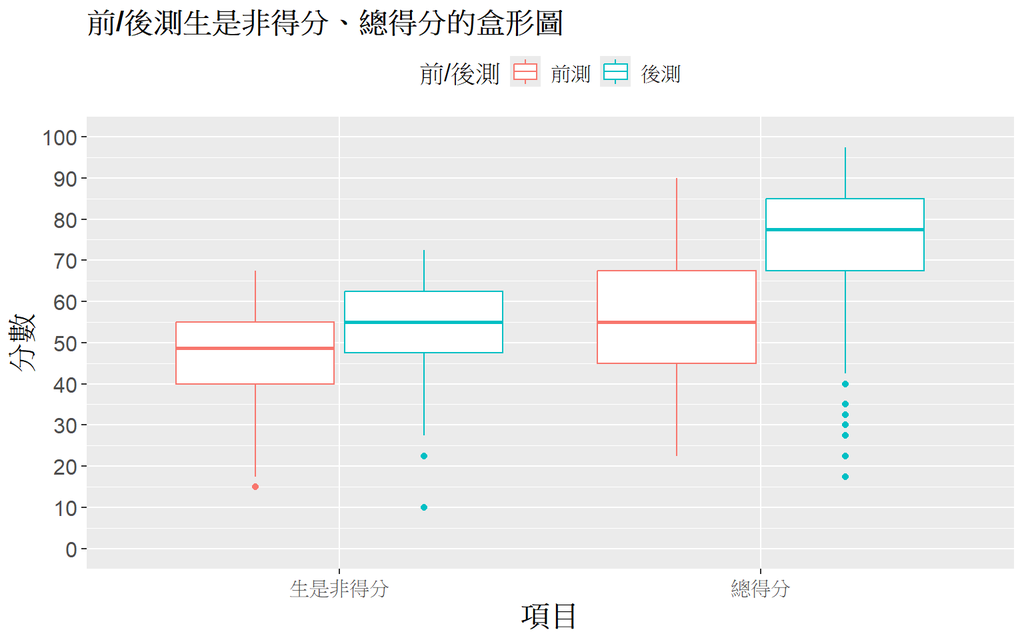

```r
Cdat_yn<-rbind(Cdat1_yn, Cdat2_yn)
Cdat_yn[["前/後測"]]<-rep(c("前測","後測"),each=dim(Cdat1_yn)[1])

Cdat_yn%>%
  dplyr::select(生是非得分,總得分,`前/後測`) %>%
  # gather 所有變數，除了 island 之外(要當成獨立一個欄位，做為群組)
  gather(key = 'variable', value = 'measurements', -`前/後測`)%>%
  ggplot(mapping = aes(x = variable, y = measurements, col = `前/後測`)) +
    # 繪製盒鬚圖，使用 position_dodge 調整間距
    geom_boxplot(position = position_dodge(0.8)) +
    # 修改 x 軸標籤為 Soil properties
    labs(x = '項目',y="分數", title="前/後測生是非得分、總得分的盒形圖")+
    scale_y_continuous(limits=c(0,100),breaks = seq(0,100,10))+
    theme(legend.position = "top", plot.title = element_text(face="bold",size=16),
          legend.title = element_text(size=14),
          legend.text = element_text(size=12),
          axis.title.x = element_text(face="bold",size=16),
          axis.title.y = element_text(face="bold",size=16),
          axis.text.x = element_text(size=12),
          axis.text.y = element_text(size=12))
```

###** 1-1-1 計算前後測總得分組距**

```r
cut(Cdat1_yn$總得分,seq(-1,101,10))%>%table()
```

```
## .
##  (-1,9]  (9,19] (19,29] (29,39] (39,49] (49,59] (59,69] (69,79] (79,89] (89,99]
##       0       0       7      12      31      31      36      19       9       1
```

```r
cut(Cdat2_yn$總得分,seq(-1,101,10))%>%table()
```

```
## .
##  (-1,9]  (9,19] (19,29] (29,39] (39,49] (49,59] (59,69] (69,79] (79,89] (89,99]
##       0       1       2       3       5      10      24      35      51      15
```

```r
# 進步幅度組距
cut(Cdat2_yn$總得分-Cdat1_yn$總得分, c(seq(-80,-1,10),-1,1,seq(9,80,10)))%>%table()
```

```
## .
## (-80,-70] (-70,-60] (-60,-50] (-50,-40] (-40,-30] (-30,-20] (-20,-10]  (-10,-1]
##         0         0         0         0         1         3         4         7
##    (-1,1]     (1,9]    (9,19]   (19,29]   (29,39]   (39,49]   (49,59]   (59,69]
##         3        25        34        36        21         8         4         0
##   (69,79]
##         0
```

## **1-2 建立高低分分組比較function**

```r
#高低分組比較
yn.prepost.lowhigh.table<-function(data_a1, data_a2, data_b1, data_b2){

  res_low<-yn.prepost.table(data_a1, data_a2)
  res_high<-yn.prepost.table(data_b1, data_b2)

  res<-rbind(res_low, res_high)

  res$`鑑別度（前測）`<-rep(res_high$`答對率（前測）`-res_low$`答對率（前測）`, 2)
  res$`鑑別度（後測）`<-rep(res_high$`答對率（後測）`-res_low$`答對率（後測）`, 2)
  res$`難度（後測）`<-rep((res_low$`答對率（後測）`+res_high$`答對率（後測）`)/2, 2)

  out<-matrix(NA, length(ans)*2, 12)%>%as.data.frame()
  rownames(out)<-NULL;colnames(out)<-c("題號","組別",colnames(res)[-1])
  out[,1]<-rep(names(ans), each=2)

  out[,2]<-rep(c("低分組","高分組"),length(ans))
  for(i in colnames(res)[-1]){
    out[seq(1,length(ans)*2,2),i]<-res[1:dim(res_low)[1],i]
    out[seq(2,length(ans)*2,2),i]<-res[(1:dim(res_low)[1])+dim(res_low)[1],i]
  }

  out$檢定結果<-out$檢定結果%>%factor()
  levels(out$檢定結果)<-levels(res_low$檢定結果)

  return(out)
}

#高低分組比較繪圖
yn.prepost.plot.lowhigh<-function(data, title){
  data[["組別"]]<-rep(c("低分組","高分組"),each=dim(data)[1]/2)%>%factor()
  pp<-ggplot(data, aes(x = 題號, colour = 檢定結果))+
      geom_linerange(aes(x = 題號, ymin = `答對率（前測）`, ymax = `答對率（後測）`,
                         colour = 檢定結果, linetype = 組別), linewidth=1.2,
                     position = position_dodge2(width=0.5))+
    geom_point(aes(x = 題號, y = `答對率（前測）`,shape="答對率（前測）"), position = position_dodge2(width=0.5),size=2)+
    geom_point(aes(x = 題號, y = `答對率（後測）`,shape="答對率（後測）"), position = position_dodge2(width=0.5),size=2)+
    scale_shape_manual(values=c(8,19),labels=c("前測","後測"))+
    labs(x="題目", y="答對率", title=title, color="前後測差異",shape="前/後測")+
    scale_color_manual(values=c("red","black","blue"),labels=c("顯著","不顯著","前後無任何變化"))+
    scale_y_continuous(limits=c(0,1),breaks = seq(0,1,0.2))+
    scale_linetype_manual(values=c(6,1))+
      theme(legend.position = "top", plot.title = element_text(face="bold",size=15),
            legend.title = element_text(size=10),
            axis.title.x = element_text(face="bold",size=12),
            axis.title.y = element_text(face="bold",size=12),
            )
  return(pp)
}

#高低分組之鑑別度難度
yn.prepost.plot.lowhigh.D<-function(data, title){
  data[["組別"]]<-rep(c("低分組","高分組"),dim(data)[1]/2)%>%factor()
  data$題號<-rep(ans0, each=2)%>%factor(levels=ans0)
  pp<-ggplot(data%>%filter(組別=="高分組"), aes(x = 題號,
                         colour = factor(`鑑別度（後測）`>0.4)))+
      geom_linerange(aes(x = 題號, ymin = `鑑別度（前測）`, ymax = `鑑別度（後測）`,
                         colour = factor(`鑑別度（後測）`>0.4)), linewidth=1.2,
                     position = position_dodge2(width=0.5))+
    geom_point(aes(x = 題號, y = `鑑別度（前測）`,shape="鑑別度（前測）"), position = position_dodge2(width=0.5),size=2)+
    geom_point(aes(x = 題號, y = `鑑別度（後測）`,shape="鑑別度（後測）"), position = position_dodge2(width=0.5),size=2)+
    geom_point(aes(x = 題號, y = `難度（後測）`,shape="難度（後測）"), position = position_dodge2(width=0.5),size=3, col="navy")+
    scale_shape_manual(values=c(17,8,19),labels=c("難度（後測）","鑑別度（前測）","鑑別度（後測）")%>%sort())+
    labs(x="題目", y="鑑別度/難度分數", title=title, color="鑑別度分數",shape="項目")+
    scale_color_manual(values=c("orange","darkgreen"),labels=c("<=0.4",">0.4"))+
    scale_y_continuous(limits=c(-0.1,1),breaks = seq(0,1,0.2))+
      theme(legend.position = "top", plot.title = element_text(face="bold",size=15),
            legend.title = element_text(size=10),
            axis.title.x = element_text(face="bold",size=12),
            axis.title.y = element_text(face="bold",size=12),
            )
  return(pp)
}
```

## **1-3 按後測總得分高低分組**

```r
type<-"後測總得分";num<-0.25

out<-matrix(NA,3,3)
rownames(out)<-c("高分組","平均組","低分組")
colnames(out)<-c("分組依據",type,"組內人數")
```

### **1-3-1 分組敘述統計（按後測總得分分組）**

```r
out[1,1]<-paste(type,"的前",num*100,"%",sep="")
out[2,1]<-paste(type,"的平均上下",(1-2*num)*100,"%",sep="")
out[3,1]<-paste(type,"的後",num*100,"%",sep="")
out[1,2]<-paste(quantile(Cdat2_yn$總得分,1-num),"分(含)以上",sep="")
out[2,2]<-paste(quantile(Cdat2_yn$總得分,num)+2.5,"~",quantile(Cdat2_yn$總得分,1-num)-2.5,"分",sep="")
out[3,2]<-paste(quantile(Cdat2_yn$總得分,num),"分(含)以下",sep="")
gpost.high<-Cdat2_yn$總得分>=quantile(Cdat2_yn$總得分,1-num)
gpost.low<-Cdat2_yn$總得分<=quantile(Cdat2_yn$總得分,num)

out[1,3]<-length(which(gpost.high));out[3,3]<-length(which(gpost.low));out[2,3]<-dim(Cdat2_yn)[1]-length(which(gpost.high))-length(which(gpost.low))

out%>%kable("html",escape = F,booktabs = TRUE, caption = "1-3-1 分組敘述統計（按後測總得分分組）")%>%
  kable_styling(c("striped", "bordered"))%>%
  column_spec(1, bold = T)
```

1-3-1 分組敘述統計（按後測總得分分組）

|  | 分組依據 | 後測總得分 | 組內人數 |
| --- | --- | --- | --- |
| 高分組 | 後測總得分的前25% | 85分(含)以上 | 39 |
| 平均組 | 後測總得分的平均上下50% | 70~82.5分 | 62 |
| 低分組 | 後測總得分的後25% | 67.5分(含)以下 | 45 |

### **1-3-2 是非題答對率之前後測結果比較（後測低分組vs.後測高分組）**

```r
kk<-yn.prepost.lowhigh.table(Cdat1_yn[which(gpost.low),],Cdat2_yn[which(gpost.low),],Cdat1_yn[which(gpost.high),],Cdat2_yn[which(gpost.high),])

colnames(kk)<-c("","","平均答對率","標準差","平均答對率","標準差","t統計量","p-value","檢定結果","前測","後測","後測")

kk[,8]<-str_c(kk[,8]%>%round(digits=3),cut(kk[,8], breaks=c(0,0.001,0.01,0.05,1),labels=c("***","**","*","")))

kk%>%kable("html",escape = F,booktabs = TRUE, digits=c(0,0,3,2,3,2,3,3,3,3,3,3),caption="1-3-2 是非題答對率之前後測結果比較（後測低分組n=45 vs.後測高分組n=39）")%>%
  kable_styling(c("striped", "bordered"))%>%
  add_header_above(c(" " = 2, "前測" = 2, "後測" = 2,"前後測成對t檢定" = 3,"鑑別度" = 2, "難度" = 1))%>%
  column_spec(1, bold = T)%>%
  collapse_rows(columns=c(1,10:12))%>%
  group_rows("生是非", 1, 60)%>%
  group_rows("技是非", 61, 80)
```

1-3-2 是非題答對率之前後測結果比較（後測低分組n=45 vs.後測高分組n=39）

[output not shown]

[output cut: 52 more lines]

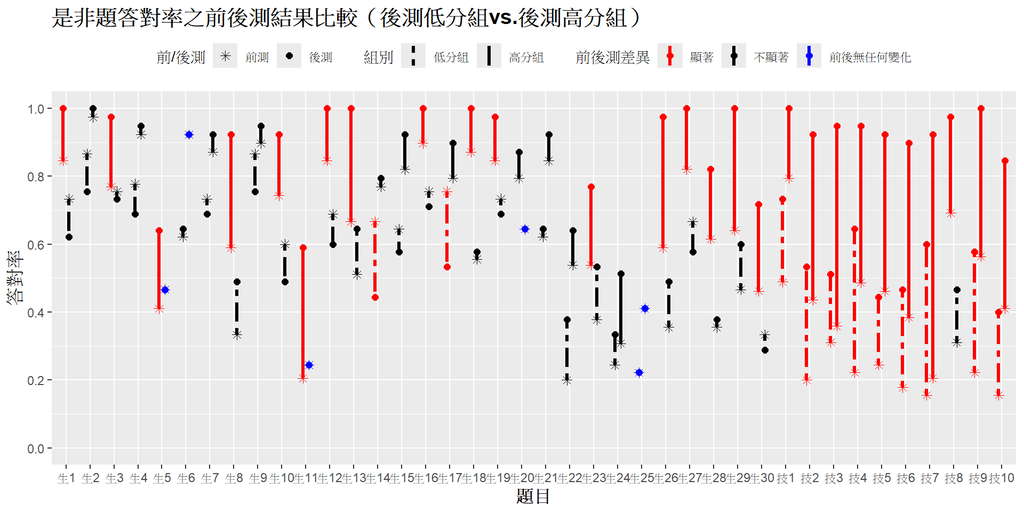

```r
res_low<-yn.prepost.table(Cdat1_yn[which(gpost.low),], Cdat2_yn[which(gpost.low),])
res_high<-yn.prepost.table(Cdat1_yn[which(gpost.high),], Cdat2_yn[which(gpost.high),])
res<-rbind(res_low, res_high)

yn.prepost.plot.lowhigh(res, "是非題答對率之前後測結果比較（後測低分組vs.後測高分組）")
```

### **1-3-3 鑑別度、難度分析（後測低分組vs.後測高分組）**

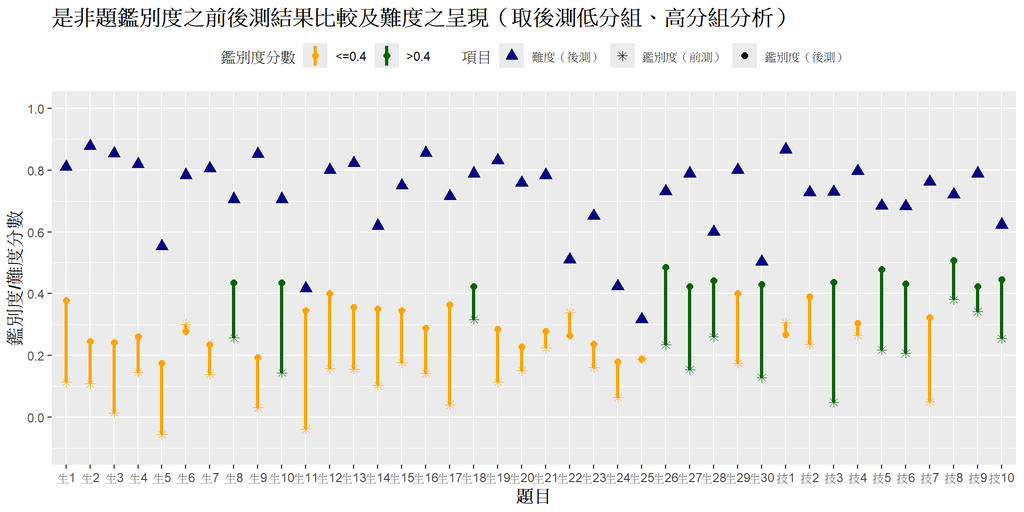

```r
kk<-yn.prepost.lowhigh.table(Cdat1_yn[which(gpost.low),],Cdat2_yn[which(gpost.low),],Cdat1_yn[which(gpost.high),],Cdat2_yn[which(gpost.high),])

yn.prepost.plot.lowhigh.D(kk, "是非題鑑別度之前後測結果比較及難度之呈現（取後測低分組、高分組分析）")
```

### **1-3-4 全部生是非、知識性質及覺察類是非題彙整表格（後測低分組n=45 vs.後測高分組n=39）**

```r
kk<-mean_table_all2(Cdat1_yn%>%filter(gpost.low), Cdat2_yn%>%filter(gpost.low),
               Cdat1_yn%>%filter(gpost.high), Cdat2_yn%>%filter(gpost.high), state=7)


kk[[1]]%>%kableExtra::kable("html",escape = T,booktabs = TRUE,digits=c(0,0,3,2,3,2,3,3,3,3,3,3,3,3,3,3,3,3),caption="1-3-4 全部生是非、知識性質及覺察類是非題彙整表格（後測低分組n=45 vs.後測高分組n=39）")%>%
  kable_styling(c("striped", "bordered"))%>%
  add_header_above(c(" " = 2, "前測" = 2, "後測" = 2,"前後測成對t檢定" = 3, "高分組-低分組獨立t檢定 (進步量)"=3, "高分組-低分組獨立t檢定 (前測)"=3, "高分組-低分組獨立t檢定 (後測)"=3))%>%
  column_spec(1, bold = T)%>%
  kableExtra::collapse_rows(columns = c(1, 10:18))
```

1-3-4 全部生是非、知識性質及覺察類是非題彙整表格（後測低分組n=45 vs.後測高分組n=39）

[output not shown]

### **1-3-5 全部生是非、知識性質及覺察類是非題盒形圖（後測低分組n=45 vs.後測高分組n=39）**

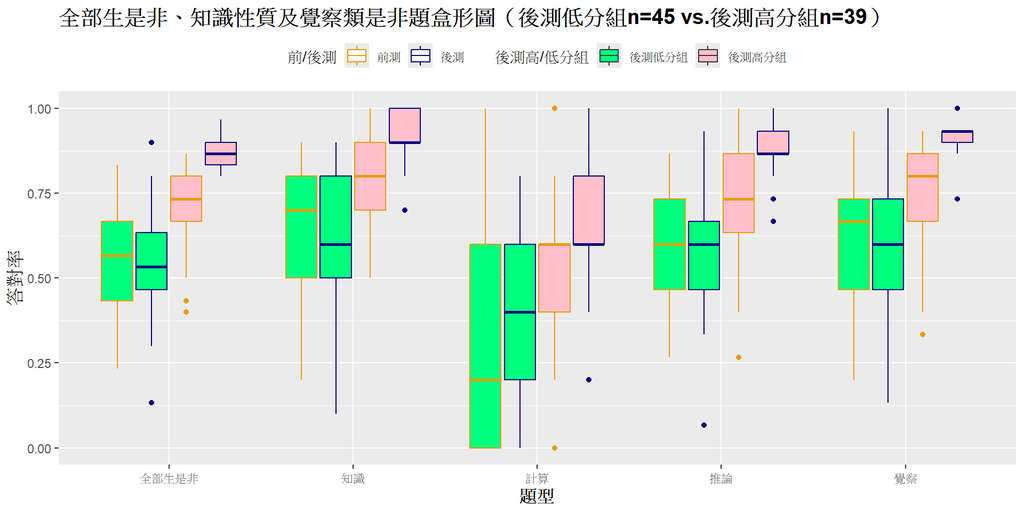

```r
yn.prepost.compare.boxplot(Cdat1_yn%>%filter(gpost.low), Cdat2_yn%>%filter(gpost.low),
                           Cdat1_yn%>%filter(gpost.high), Cdat2_yn%>%filter(gpost.high),state=7,
                           title="全部生是非、知識性質及覺察類是非題盒形圖（後測低分組n=45 vs.後測高分組n=39）")
```

### **1-3-6 知識性質生是非前後測答對率（後測低分組n=45 vs.後測高分組n=39）**

```r
kk<-yn_life.prepost.compare.table(Cdat1_yn%>%filter(gpost.low),
                                  Cdat2_yn%>%filter(gpost.low),
                                  Cdat1_yn%>%filter(gpost.high),
                                  Cdat2_yn%>%filter(gpost.high),7)%>%
  arrange(知識性質)%>%dplyr::select(!c("知識性質","生活主題","覺察"))

colnames(kk)<-c("","","平均答對率","標準差","平均答對率","標準差","t統計量","p-value","檢定結果")

kk[,7]<-kk[,7]%>%as.numeric%>%round(digits=3)

kk[,8]<-str_c(kk[,8]%>%as.numeric%>%round(digits=3),cut(kk[,8]%>%as.numeric, breaks=c(0,0.001,0.01,0.05,1),labels=c("***","**","*","")))

kk%>%kable("html",escape = F,booktabs = TRUE, digits=c(0,0,3,2,3,2,3,3,3), caption="1-3-6 知識性質生是非前後測答對率（後測低分組n=45 vs.後測高分組n=39）")%>%
  kable_styling(c("striped", "bordered"))%>%
  add_header_above(c(" " = 2, "前測" = 2, "後測" = 2,"前後測成對t檢定" = 3))%>%
  column_spec(1, bold = T)%>%
  collapse_rows(columns = 1)%>%
  group_rows("知識", 1, 20)%>%
  group_rows("推論", 21, 50)%>%
  group_rows("計算", 51, 60)
```

1-3-6 知識性質生是非前後測答對率（後測低分組n=45 vs.後測高分組n=39）

|  |  | 前測 平均答對率 | 前測 標準差 | 後測 平均答對率 | 後測 標準差 | 前後測成對t檢定 t統計量 | 前後測成對t檢定 p-value | 前後測成對t檢定 檢定結果 |
| --- | --- | --- | --- | --- | --- | --- | --- | --- |
| **知識** |  |  |  |  |  |  |  |  |
| 生是非1 | 後測低分組 | 0.733 | 0.45 | 0.622 | 0.49 | -1.301 | 0.2 | Don’t Reject H0 |
|  | 後測高分組 | 0.846 | 0.37 | 1.000 | 0.00 | 2.629 | 0.012* | Reject H0 |
| 生是非2 | 後測低分組 | 0.867 | 0.34 | 0.756 | 0.43 | -1.530 | 0.133 | Don’t Reject H0 |
|  | 後測高分組 | 0.974 | 0.16 | 1.000 | 0.00 | 1.000 | 0.324 | Don’t Reject H0 |
| 生是非4 | 後測低分組 | 0.778 | 0.42 | 0.689 | 0.47 | -1.274 | 0.209 | Don’t Reject H0 |
|  | 後測高分組 | 0.923 | 0.27 | 0.949 | 0.22 | 0.572 | 0.57 | Don’t Reject H0 |
| 生是非5 | 後測低分組 | 0.467 | 0.50 | 0.467 | 0.50 | 0.000 | 1 | No Change |
|  | 後測高分組 | 0.410 | 0.50 | 0.641 | 0.49 | 2.471 | 0.018* | Reject H0 |
| 生是非6 | 後測低分組 | 0.622 | 0.49 | 0.644 | 0.48 | 0.256 | 0.8 | Don’t Reject H0 |
|  | 後測高分組 | 0.923 | 0.27 | 0.923 | 0.27 | 0.000 | 1 | No Change |
| 生是非7 | 後測低分組 | 0.733 | 0.45 | 0.689 | 0.47 | -0.496 | 0.623 | Don’t Reject H0 |
|  | 後測高分組 | 0.872 | 0.34 | 0.923 | 0.27 | 0.703 | 0.487 | Don’t Reject H0 |
| 生是非13 | 後測低分組 | 0.511 | 0.51 | 0.644 | 0.48 | 1.354 | 0.183 | Don’t Reject H0 |
|  | 後測高分組 | 0.667 | 0.48 | 1.000 | 0.00 | 4.359 | 0*** | Reject H0 |
| 生是非14 | 後測低分組 | 0.667 | 0.48 | 0.444 | 0.50 | -2.345 | 0.024* | Reject H0 |
|  | 後測高分組 | 0.769 | 0.43 | 0.795 | 0.41 | 0.443 | 0.661 | Don’t Reject H0 |
| 生是非18 | 後測低分組 | 0.556 | 0.50 | 0.578 | 0.50 | 0.227 | 0.821 | Don’t Reject H0 |
|  | 後測高分組 | 0.872 | 0.34 | 1.000 | 0.00 | 2.364 | 0.023* | Reject H0 |
| 生是非29 | 後測低分組 | 0.467 | 0.50 | 0.600 | 0.50 | 1.522 | 0.135 | Don’t Reject H0 |
|  | 後測高分組 | 0.641 | 0.49 | 1.000 | 0.00 | 4.613 | 0*** | Reject H0 |
| **推論** |  |  |  |  |  |  |  |  |
| 生是非3 | 後測低分組 | 0.756 | 0.43 | 0.733 | 0.45 | -0.256 | 0.8 | Don’t Reject H0 |
|  | 後測高分組 | 0.769 | 0.43 | 0.974 | 0.16 | 3.132 | 0.003** | Reject H0 |
| 生是非8 | 後測低分組 | 0.333 | 0.48 | 0.489 | 0.51 | 1.735 | 0.09 | Don’t Reject H0 |
|  | 後測高分組 | 0.590 | 0.50 | 0.923 | 0.27 | 3.929 | 0*** | Reject H0 |
| 生是非9 | 後測低分組 | 0.867 | 0.34 | 0.756 | 0.43 | -1.701 | 0.096 | Don’t Reject H0 |
|  | 後測高分組 | 0.897 | 0.31 | 0.949 | 0.22 | 1.000 | 0.324 | Don’t Reject H0 |
| 生是非10 | 後測低分組 | 0.600 | 0.50 | 0.489 | 0.51 | -1.044 | 0.302 | Don’t Reject H0 |
|  | 後測高分組 | 0.744 | 0.44 | 0.923 | 0.27 | 2.214 | 0.033* | Reject H0 |
| 生是非11 | 後測低分組 | 0.244 | 0.43 | 0.244 | 0.43 | 0.000 | 1 | No Change |
|  | 後測高分組 | 0.205 | 0.41 | 0.590 | 0.50 | 4.418 | 0*** | Reject H0 |
| 生是非12 | 後測低分組 | 0.689 | 0.47 | 0.600 | 0.50 | -0.892 | 0.377 | Don’t Reject H0 |
|  | 後測高分組 | 0.846 | 0.37 | 1.000 | 0.00 | 2.629 | 0.012* | Reject H0 |
| 生是非15 | 後測低分組 | 0.644 | 0.48 | 0.578 | 0.50 | -0.903 | 0.372 | Don’t Reject H0 |
|  | 後測高分組 | 0.821 | 0.39 | 0.923 | 0.27 | 1.670 | 0.103 | Don’t Reject H0 |
| 生是非16 | 後測低分組 | 0.756 | 0.43 | 0.711 | 0.46 | -0.530 | 0.599 | Don’t Reject H0 |
|  | 後測高分組 | 0.897 | 0.31 | 1.000 | 0.00 | 2.084 | 0.044* | Reject H0 |
| 生是非17 | 後測低分組 | 0.756 | 0.43 | 0.533 | 0.50 | -2.489 | 0.017* | Reject H0 |
|  | 後測高分組 | 0.795 | 0.41 | 0.897 | 0.31 | 1.160 | 0.253 | Don’t Reject H0 |
| 生是非19 | 後測低分組 | 0.733 | 0.45 | 0.689 | 0.47 | -0.467 | 0.643 | Don’t Reject H0 |
|  | 後測高分組 | 0.846 | 0.37 | 0.974 | 0.16 | 2.364 | 0.023* | Reject H0 |
| 生是非20 | 後測低分組 | 0.644 | 0.48 | 0.644 | 0.48 | 0.000 | 1 | No Change |
|  | 後測高分組 | 0.795 | 0.41 | 0.872 | 0.34 | 0.902 | 0.373 | Don’t Reject H0 |
| 生是非21 | 後測低分組 | 0.622 | 0.49 | 0.644 | 0.48 | 0.256 | 0.8 | Don’t Reject H0 |
|  | 後測高分組 | 0.846 | 0.37 | 0.923 | 0.27 | 1.138 | 0.262 | Don’t Reject H0 |
| 生是非22 | 後測低分組 | 0.200 | 0.40 | 0.378 | 0.49 | 1.943 | 0.058 | Don’t Reject H0 |
|  | 後測高分組 | 0.538 | 0.51 | 0.641 | 0.49 | 1.000 | 0.324 | Don’t Reject H0 |
| 生是非23 | 後測低分組 | 0.378 | 0.49 | 0.533 | 0.50 | 1.636 | 0.109 | Don’t Reject H0 |
|  | 後測高分組 | 0.538 | 0.51 | 0.769 | 0.43 | 2.974 | 0.005** | Reject H0 |
| 生是非27 | 後測低分組 | 0.667 | 0.48 | 0.578 | 0.50 | -0.942 | 0.352 | Don’t Reject H0 |
|  | 後測高分組 | 0.821 | 0.39 | 1.000 | 0.00 | 2.883 | 0.006** | Reject H0 |
| **計算** |  |  |  |  |  |  |  |  |
| 生是非24 | 後測低分組 | 0.244 | 0.43 | 0.333 | 0.48 | 1.071 | 0.29 | Don’t Reject H0 |
|  | 後測高分組 | 0.308 | 0.47 | 0.513 | 0.51 | 1.843 | 0.073 | Don’t Reject H0 |
| 生是非25 | 後測低分組 | 0.222 | 0.42 | 0.222 | 0.42 | 0.000 | 1 | No Change |
|  | 後測高分組 | 0.410 | 0.50 | 0.410 | 0.50 | 0.000 | 1 | No Change |
| 生是非26 | 後測低分組 | 0.356 | 0.48 | 0.489 | 0.51 | 1.354 | 0.183 | Don’t Reject H0 |
|  | 後測高分組 | 0.590 | 0.50 | 0.974 | 0.16 | 4.873 | 0*** | Reject H0 |
| 生是非28 | 後測低分組 | 0.356 | 0.48 | 0.378 | 0.49 | 0.216 | 0.83 | Don’t Reject H0 |
|  | 後測高分組 | 0.615 | 0.49 | 0.821 | 0.39 | 2.084 | 0.044* | Reject H0 |
| 生是非30 | 後測低分組 | 0.333 | 0.48 | 0.289 | 0.46 | -0.496 | 0.623 | Don’t Reject H0 |
|  | 後測高分組 | 0.462 | 0.51 | 0.718 | 0.46 | 3.213 | 0.003** | Reject H0 |

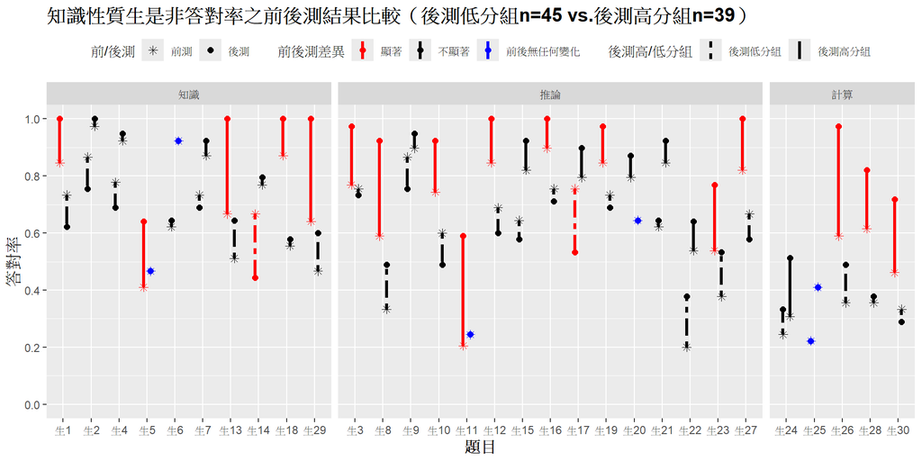

```r
res_postlow<-yn_life.prepost.table(Cdat1_yn%>%filter(gpost.low),
                               Cdat2_yn%>%filter(gpost.low))
res_nopostlow<-yn_life.prepost.table(Cdat1_yn%>%filter(gpost.high),
                                 Cdat2_yn%>%filter(gpost.high))
res<-rbind(res_postlow, res_nopostlow)

yn.prepost.compare.plot(res, "知識性質生是非答對率之前後測結果比較（後測低分組n=45 vs.後測高分組n=39）", state=7)+
  facet_grid(cols=vars(知識性質), scales = "free", space = "free")
```

### **1-3-7 生活主題生是非前後測答對率（後測低分組n=45 vs.後測高分組n=39）**

```r
kk<-yn_life.prepost.compare.table(Cdat1_yn%>%filter(gpost.low),
                                  Cdat2_yn%>%filter(gpost.low),
                                  Cdat1_yn%>%filter(gpost.high),
                                  Cdat2_yn%>%filter(gpost.high),7)%>%
  arrange(生活主題)
kk1<-kk%>%dplyr::select(!c("知識性質","生活主題","覺察"))
colnames(kk1)<-c("","","平均答對率","標準差","平均答對率","標準差","t統計量","p-value","檢定結果")

kk1[,7]<-kk1[,7]%>%as.numeric%>%round(digits=3)

kk1[,8]<-str_c(kk1[,8]%>%as.numeric%>%round(digits=3),cut(kk1[,8]%>%as.numeric, breaks=c(0,0.001,0.01,0.05,1),labels=c("***","**","*","")))

kk1%>%kable("html",escape = F,booktabs = TRUE, digits=c(0,0,3,2,3,2,3,3,3), caption="7-3 生活主題生是非前後測答對率（後測低分組n=45 vs.後測高分組n=39）")%>%
  kable_styling(c("striped", "bordered"))%>%
  add_header_above(c(" " = 2, "前測" = 2, "後測" = 2,"前後測成對t檢定" = 3))%>%
  column_spec(1, bold = T)%>%
  collapse_rows(columns = 1)%>%
  group_rows(levels(kk$生活主題)[1], 1, cumsum(table(kk$生活主題))[[1]])%>%
  group_rows(levels(kk$生活主題)[2], cumsum(table(kk$生活主題))[[1]]+1, cumsum(table(kk$生活主題))[[2]])%>%
  group_rows(levels(kk$生活主題)[3], cumsum(table(kk$生活主題))[[2]]+1, cumsum(table(kk$生活主題))[[3]])%>%
  group_rows(levels(kk$生活主題)[4], cumsum(table(kk$生活主題))[[3]]+1, cumsum(table(kk$生活主題))[[4]])%>%
  group_rows(levels(kk$生活主題)[5], cumsum(table(kk$生活主題))[[4]]+1, cumsum(table(kk$生活主題))[[5]])%>%
  group_rows(levels(kk$生活主題)[6], cumsum(table(kk$生活主題))[[5]]+1, cumsum(table(kk$生活主題))[[6]])%>%
  group_rows(levels(kk$生活主題)[7], cumsum(table(kk$生活主題))[[6]]+1, cumsum(table(kk$生活主題))[[7]])%>%
  group_rows(levels(kk$生活主題)[8], cumsum(table(kk$生活主題))[[7]]+1, cumsum(table(kk$生活主題))[[8]])
```

7-3 生活主題生是非前後測答對率（後測低分組n=45 vs.後測高分組n=39）

|  |  | 前測 平均答對率 | 前測 標準差 | 後測 平均答對率 | 後測 標準差 | 前後測成對t檢定 t統計量 | 前後測成對t檢定 p-value | 前後測成對t檢定 檢定結果 |
| --- | --- | --- | --- | --- | --- | --- | --- | --- |
| **01營養素** |  |  |  |  |  |  |  |  |
| 生是非1 | 後測低分組 | 0.733 | 0.45 | 0.622 | 0.49 | -1.301 | 0.2 | Don’t Reject H0 |
|  | 後測高分組 | 0.846 | 0.37 | 1.000 | 0.00 | 2.629 | 0.012* | Reject H0 |
| 生是非2 | 後測低分組 | 0.867 | 0.34 | 0.756 | 0.43 | -1.530 | 0.133 | Don’t Reject H0 |
|  | 後測高分組 | 0.974 | 0.16 | 1.000 | 0.00 | 1.000 | 0.324 | Don’t Reject H0 |
| 生是非4 | 後測低分組 | 0.778 | 0.42 | 0.689 | 0.47 | -1.274 | 0.209 | Don’t Reject H0 |
|  | 後測高分組 | 0.923 | 0.27 | 0.949 | 0.22 | 0.572 | 0.57 | Don’t Reject H0 |
| 生是非24 | 後測低分組 | 0.244 | 0.43 | 0.333 | 0.48 | 1.071 | 0.29 | Don’t Reject H0 |
|  | 後測高分組 | 0.308 | 0.47 | 0.513 | 0.51 | 1.843 | 0.073 | Don’t Reject H0 |
| **02細胞** |  |  |  |  |  |  |  |  |
| 生是非3 | 後測低分組 | 0.756 | 0.43 | 0.733 | 0.45 | -0.256 | 0.8 | Don’t Reject H0 |
|  | 後測高分組 | 0.769 | 0.43 | 0.974 | 0.16 | 3.132 | 0.003** | Reject H0 |
| 生是非5 | 後測低分組 | 0.467 | 0.50 | 0.467 | 0.50 | 0.000 | 1 | No Change |
|  | 後測高分組 | 0.410 | 0.50 | 0.641 | 0.49 | 2.471 | 0.018* | Reject H0 |
| 生是非8 | 後測低分組 | 0.333 | 0.48 | 0.489 | 0.51 | 1.735 | 0.09 | Don’t Reject H0 |
|  | 後測高分組 | 0.590 | 0.50 | 0.923 | 0.27 | 3.929 | 0*** | Reject H0 |
| 生是非10 | 後測低分組 | 0.600 | 0.50 | 0.489 | 0.51 | -1.044 | 0.302 | Don’t Reject H0 |
|  | 後測高分組 | 0.744 | 0.44 | 0.923 | 0.27 | 2.214 | 0.033* | Reject H0 |
| **03食物** |  |  |  |  |  |  |  |  |
| 生是非12 | 後測低分組 | 0.689 | 0.47 | 0.600 | 0.50 | -0.892 | 0.377 | Don’t Reject H0 |
|  | 後測高分組 | 0.846 | 0.37 | 1.000 | 0.00 | 2.629 | 0.012* | Reject H0 |
| 生是非18 | 後測低分組 | 0.556 | 0.50 | 0.578 | 0.50 | 0.227 | 0.821 | Don’t Reject H0 |
|  | 後測高分組 | 0.872 | 0.34 | 1.000 | 0.00 | 2.364 | 0.023* | Reject H0 |
| 生是非20 | 後測低分組 | 0.644 | 0.48 | 0.644 | 0.48 | 0.000 | 1 | No Change |
|  | 後測高分組 | 0.795 | 0.41 | 0.872 | 0.34 | 0.902 | 0.373 | Don’t Reject H0 |
| 生是非23 | 後測低分組 | 0.378 | 0.49 | 0.533 | 0.50 | 1.636 | 0.109 | Don’t Reject H0 |
|  | 後測高分組 | 0.538 | 0.51 | 0.769 | 0.43 | 2.974 | 0.005** | Reject H0 |
| 生是非30 | 後測低分組 | 0.333 | 0.48 | 0.289 | 0.46 | -0.496 | 0.623 | Don’t Reject H0 |
|  | 後測高分組 | 0.462 | 0.51 | 0.718 | 0.46 | 3.213 | 0.003** | Reject H0 |
| **04飲食習慣** |  |  |  |  |  |  |  |  |
| 生是非6 | 後測低分組 | 0.622 | 0.49 | 0.644 | 0.48 | 0.256 | 0.8 | Don’t Reject H0 |
|  | 後測高分組 | 0.923 | 0.27 | 0.923 | 0.27 | 0.000 | 1 | No Change |
| 生是非9 | 後測低分組 | 0.867 | 0.34 | 0.756 | 0.43 | -1.701 | 0.096 | Don’t Reject H0 |
|  | 後測高分組 | 0.897 | 0.31 | 0.949 | 0.22 | 1.000 | 0.324 | Don’t Reject H0 |
| 生是非15 | 後測低分組 | 0.644 | 0.48 | 0.578 | 0.50 | -0.903 | 0.372 | Don’t Reject H0 |
|  | 後測高分組 | 0.821 | 0.39 | 0.923 | 0.27 | 1.670 | 0.103 | Don’t Reject H0 |
| 生是非16 | 後測低分組 | 0.756 | 0.43 | 0.711 | 0.46 | -0.530 | 0.599 | Don’t Reject H0 |
|  | 後測高分組 | 0.897 | 0.31 | 1.000 | 0.00 | 2.084 | 0.044* | Reject H0 |
| 生是非17 | 後測低分組 | 0.756 | 0.43 | 0.533 | 0.50 | -2.489 | 0.017* | Reject H0 |
|  | 後測高分組 | 0.795 | 0.41 | 0.897 | 0.31 | 1.160 | 0.253 | Don’t Reject H0 |
| **05運動** |  |  |  |  |  |  |  |  |
| 生是非7 | 後測低分組 | 0.733 | 0.45 | 0.689 | 0.47 | -0.496 | 0.623 | Don’t Reject H0 |
|  | 後測高分組 | 0.872 | 0.34 | 0.923 | 0.27 | 0.703 | 0.487 | Don’t Reject H0 |
| 生是非27 | 後測低分組 | 0.667 | 0.48 | 0.578 | 0.50 | -0.942 | 0.352 | Don’t Reject H0 |
|  | 後測高分組 | 0.821 | 0.39 | 1.000 | 0.00 | 2.883 | 0.006** | Reject H0 |
| **06肥胖** |  |  |  |  |  |  |  |  |
| 生是非11 | 後測低分組 | 0.244 | 0.43 | 0.244 | 0.43 | 0.000 | 1 | No Change |
|  | 後測高分組 | 0.205 | 0.41 | 0.590 | 0.50 | 4.418 | 0*** | Reject H0 |
| 生是非25 | 後測低分組 | 0.222 | 0.42 | 0.222 | 0.42 | 0.000 | 1 | No Change |
|  | 後測高分組 | 0.410 | 0.50 | 0.410 | 0.50 | 0.000 | 1 | No Change |
| 生是非26 | 後測低分組 | 0.356 | 0.48 | 0.489 | 0.51 | 1.354 | 0.183 | Don’t Reject H0 |
|  | 後測高分組 | 0.590 | 0.50 | 0.974 | 0.16 | 4.873 | 0*** | Reject H0 |
| **07糖尿病** |  |  |  |  |  |  |  |  |
| 生是非13 | 後測低分組 | 0.511 | 0.51 | 0.644 | 0.48 | 1.354 | 0.183 | Don’t Reject H0 |
|  | 後測高分組 | 0.667 | 0.48 | 1.000 | 0.00 | 4.359 | 0*** | Reject H0 |
| 生是非14 | 後測低分組 | 0.667 | 0.48 | 0.444 | 0.50 | -2.345 | 0.024* | Reject H0 |
|  | 後測高分組 | 0.769 | 0.43 | 0.795 | 0.41 | 0.443 | 0.661 | Don’t Reject H0 |
| 生是非19 | 後測低分組 | 0.733 | 0.45 | 0.689 | 0.47 | -0.467 | 0.643 | Don’t Reject H0 |
|  | 後測高分組 | 0.846 | 0.37 | 0.974 | 0.16 | 2.364 | 0.023* | Reject H0 |
| 生是非21 | 後測低分組 | 0.622 | 0.49 | 0.644 | 0.48 | 0.256 | 0.8 | Don’t Reject H0 |
|  | 後測高分組 | 0.846 | 0.37 | 0.923 | 0.27 | 1.138 | 0.262 | Don’t Reject H0 |
| 生是非22 | 後測低分組 | 0.200 | 0.40 | 0.378 | 0.49 | 1.943 | 0.058 | Don’t Reject H0 |
|  | 後測高分組 | 0.538 | 0.51 | 0.641 | 0.49 | 1.000 | 0.324 | Don’t Reject H0 |
| 生是非28 | 後測低分組 | 0.356 | 0.48 | 0.378 | 0.49 | 0.216 | 0.83 | Don’t Reject H0 |
|  | 後測高分組 | 0.615 | 0.49 | 0.821 | 0.39 | 2.084 | 0.044* | Reject H0 |
| **08量測** |  |  |  |  |  |  |  |  |
| 生是非29 | 後測低分組 | 0.467 | 0.50 | 0.600 | 0.50 | 1.522 | 0.135 | Don’t Reject H0 |
|  | 後測高分組 | 0.641 | 0.49 | 1.000 | 0.00 | 4.613 | 0*** | Reject H0 |

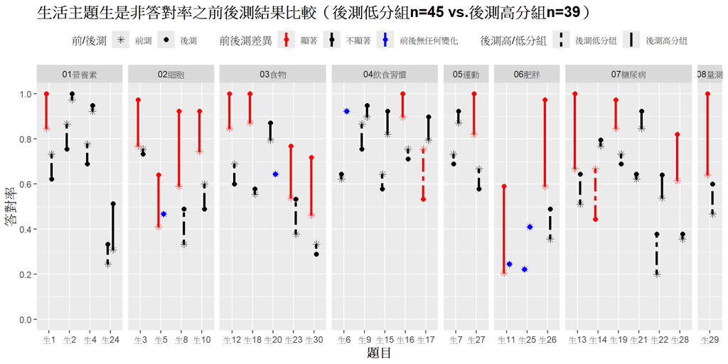

```r
yn.prepost.compare.plot(res, "生活主題生是非答對率之前後測結果比較（後測低分組n=45 vs.後測高分組n=39）", state=7)+
  facet_grid(cols=vars(生活主題), scales = "free", space = "free")
```

### **1-3-8 覺察類生是非前後測答對率（後測低分組n=45 vs.後測高分組n=39）**

```r
kk<-yn_life.prepost.compare.table(Cdat1_yn%>%filter(gpost.low),
                                  Cdat2_yn%>%filter(gpost.low),
                                  Cdat1_yn%>%filter(gpost.high),
                                  Cdat2_yn%>%filter(gpost.high),7)%>%
  filter(覺察==1)%>%dplyr::select(!c("知識性質","生活主題","覺察"))

colnames(kk)<-c("","","平均答對率","標準差","平均答對率","標準差","t統計量","p-value","檢定結果")


kk[,7]<-kk[,7]%>%as.numeric%>%round(digits=3)

kk[,8]<-str_c(kk[,8]%>%as.numeric%>%round(digits=3),cut(kk[,8]%>%as.numeric, breaks=c(0,0.001,0.01,0.05,1),labels=c("***","**","*","")))

kk%>%kable("html",escape = F,booktabs = TRUE, digits=c(0,0,3,2,3,2,3,3,3), caption="7-4 覺察類生是非前後測答對率（後測低分組n=45 vs.後測高分組n=39）")%>%
  kable_styling(c("striped", "bordered"))%>%
  add_header_above(c(" " = 2, "前測" = 2, "後測" = 2,"前後測成對t檢定" = 3))%>%
  column_spec(1, bold = T)%>%
  collapse_rows(columns = 1)%>%
  group_rows("覺察", 1, dim(kk)[1])
```

7-4 覺察類生是非前後測答對率（後測低分組n=45 vs.後測高分組n=39）

|  |  | 前測 平均答對率 | 前測 標準差 | 後測 平均答對率 | 後測 標準差 | 前後測成對t檢定 t統計量 | 前後測成對t檢定 p-value | 前後測成對t檢定 檢定結果 |
| --- | --- | --- | --- | --- | --- | --- | --- | --- |
| **覺察** |  |  |  |  |  |  |  |  |
| 生是非2 | 後測低分組 | 0.867 | 0.34 | 0.756 | 0.43 | -1.530 | 0.133 | Don’t Reject H0 |
|  | 後測高分組 | 0.974 | 0.16 | 1.000 | 0.00 | 1.000 | 0.324 | Don’t Reject H0 |
| 生是非6 | 後測低分組 | 0.622 | 0.49 | 0.644 | 0.48 | 0.256 | 0.8 | Don’t Reject H0 |
|  | 後測高分組 | 0.923 | 0.27 | 0.923 | 0.27 | 0.000 | 1 | No Change |
| 生是非9 | 後測低分組 | 0.867 | 0.34 | 0.756 | 0.43 | -1.701 | 0.096 | Don’t Reject H0 |
|  | 後測高分組 | 0.897 | 0.31 | 0.949 | 0.22 | 1.000 | 0.324 | Don’t Reject H0 |
| 生是非11 | 後測低分組 | 0.244 | 0.43 | 0.244 | 0.43 | 0.000 | 1 | No Change |
|  | 後測高分組 | 0.205 | 0.41 | 0.590 | 0.50 | 4.418 | 0*** | Reject H0 |
| 生是非12 | 後測低分組 | 0.689 | 0.47 | 0.600 | 0.50 | -0.892 | 0.377 | Don’t Reject H0 |
|  | 後測高分組 | 0.846 | 0.37 | 1.000 | 0.00 | 2.629 | 0.012* | Reject H0 |
| 生是非13 | 後測低分組 | 0.511 | 0.51 | 0.644 | 0.48 | 1.354 | 0.183 | Don’t Reject H0 |
|  | 後測高分組 | 0.667 | 0.48 | 1.000 | 0.00 | 4.359 | 0*** | Reject H0 |
| 生是非15 | 後測低分組 | 0.644 | 0.48 | 0.578 | 0.50 | -0.903 | 0.372 | Don’t Reject H0 |
|  | 後測高分組 | 0.821 | 0.39 | 0.923 | 0.27 | 1.670 | 0.103 | Don’t Reject H0 |
| 生是非16 | 後測低分組 | 0.756 | 0.43 | 0.711 | 0.46 | -0.530 | 0.599 | Don’t Reject H0 |
|  | 後測高分組 | 0.897 | 0.31 | 1.000 | 0.00 | 2.084 | 0.044* | Reject H0 |
| 生是非17 | 後測低分組 | 0.756 | 0.43 | 0.533 | 0.50 | -2.489 | 0.017* | Reject H0 |
|  | 後測高分組 | 0.795 | 0.41 | 0.897 | 0.31 | 1.160 | 0.253 | Don’t Reject H0 |
| 生是非18 | 後測低分組 | 0.556 | 0.50 | 0.578 | 0.50 | 0.227 | 0.821 | Don’t Reject H0 |
|  | 後測高分組 | 0.872 | 0.34 | 1.000 | 0.00 | 2.364 | 0.023* | Reject H0 |
| 生是非19 | 後測低分組 | 0.733 | 0.45 | 0.689 | 0.47 | -0.467 | 0.643 | Don’t Reject H0 |
|  | 後測高分組 | 0.846 | 0.37 | 0.974 | 0.16 | 2.364 | 0.023* | Reject H0 |
| 生是非20 | 後測低分組 | 0.644 | 0.48 | 0.644 | 0.48 | 0.000 | 1 | No Change |
|  | 後測高分組 | 0.795 | 0.41 | 0.872 | 0.34 | 0.902 | 0.373 | Don’t Reject H0 |
| 生是非23 | 後測低分組 | 0.378 | 0.49 | 0.533 | 0.50 | 1.636 | 0.109 | Don’t Reject H0 |
|  | 後測高分組 | 0.538 | 0.51 | 0.769 | 0.43 | 2.974 | 0.005** | Reject H0 |
| 生是非26 | 後測低分組 | 0.356 | 0.48 | 0.489 | 0.51 | 1.354 | 0.183 | Don’t Reject H0 |
|  | 後測高分組 | 0.590 | 0.50 | 0.974 | 0.16 | 4.873 | 0*** | Reject H0 |
| 生是非27 | 後測低分組 | 0.667 | 0.48 | 0.578 | 0.50 | -0.942 | 0.352 | Don’t Reject H0 |
|  | 後測高分組 | 0.821 | 0.39 | 1.000 | 0.00 | 2.883 | 0.006** | Reject H0 |

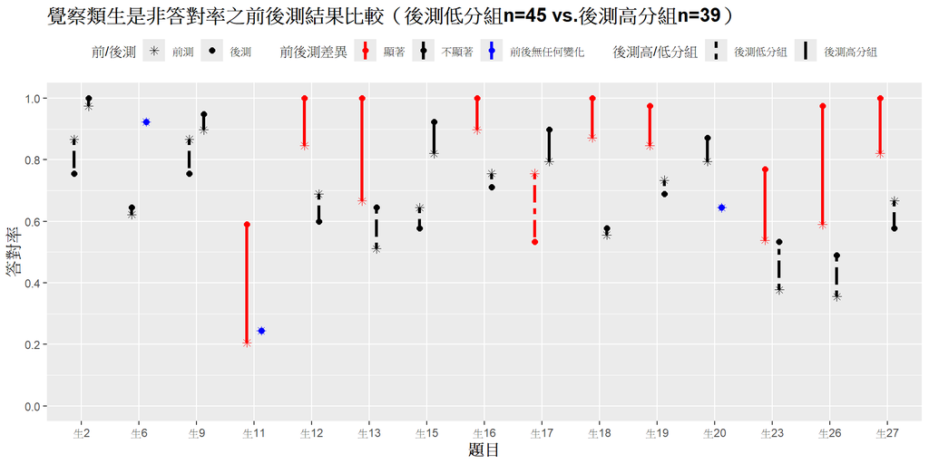

```r
yn.prepost.compare.plot(res[res$覺察==1,], "覺察類生是非答對率之前後測結果比較（後測低分組n=45 vs.後測高分組n=39）", state=7)
```

## **1-4 按前測總得分高低分組**

```r
type<-"前測總得分";num<-0.25

out<-matrix(NA,3,3)
rownames(out)<-c("高分組","平均組","低分組")
colnames(out)<-c("分組依據",type,"組內人數")
```

### **1-4-1 分組敘述統計（按前測總得分分組）**

```r
out[1,1]<-paste(type,"的前",num*100,"%",sep="")
out[2,1]<-paste(type,"的平均上下",(1-2*num)*100,"%",sep="")
out[3,1]<-paste(type,"的後",num*100,"%",sep="")
out[1,2]<-paste(quantile(Cdat1_yn$總得分,1-num),"分(含)以上",sep="")
out[2,2]<-paste(quantile(Cdat1_yn$總得分,num)+2.5,"~",quantile(Cdat1_yn$總得分,1-num)-2.5,"分",sep="")
out[3,2]<-paste(quantile(Cdat1_yn$總得分,num),"分(含)以下",sep="")
gpre.high<-Cdat1_yn$總得分>=quantile(Cdat1_yn$總得分,1-num)
gpre.low<-Cdat1_yn$總得分<=quantile(Cdat1_yn$總得分,num)

out[1,3]<-length(which(gpre.high));out[3,3]<-length(which(gpre.low));out[2,3]<-dim(Cdat1_yn)[1]-length(which(gpre.high))-length(which(gpre.low))

out%>%kable("html",escape = F,booktabs = TRUE, caption="1-4-1 分組敘述統計（按前測總得分分組）")%>%
  kable_styling(c("striped", "bordered"))%>%
  column_spec(1, bold = T)
```

1-4-1 分組敘述統計（按前測總得分分組）

|  | 分組依據 | 前測總得分 | 組內人數 |
| --- | --- | --- | --- |
| 高分組 | 前測總得分的前25% | 67.5分(含)以上 | 40 |
| 平均組 | 前測總得分的平均上下50% | 47.5~65分 | 64 |
| 低分組 | 前測總得分的後25% | 45分(含)以下 | 42 |

### **1-4-2 是非題答對率之前後測結果比較（前測低分組vs.前測高分組）**

```r
kk<-yn.prepost.lowhigh.table(Cdat1_yn[which(gpre.low),],Cdat2_yn[which(gpre.low),],Cdat1_yn[which(gpre.high),],Cdat2_yn[which(gpre.high),])

colnames(kk)<-c("","","平均答對率","標準差","平均答對率","標準差","t統計量","p-value","檢定結果","前測","後測","後測")

kk[,8]<-str_c(kk[,8]%>%round(digits=3),cut(kk[,8], breaks=c(0,0.001,0.01,0.05,1),labels=c("***","**","*","")))

kk%>%kable("html",escape = F,booktabs = TRUE, digits=c(0,0,3,2,3,2,3,3,3,3,3,3),caption="1-4-2 是非題答對率之前後測結果比較（前測低分組n=42 vs.前測高分組n=40） ")%>%
  kable_styling(c("striped", "bordered"))%>%
  add_header_above(c(" " = 2, "前測" = 2, "後測" = 2,"前後測成對t檢定" = 3,"鑑別度" = 2, "難度" = 1))%>%
  column_spec(1, bold = T)%>%
  collapse_rows(columns = c(1,10,11,12))%>%
  group_rows("生是非", 1, 60)%>%
  group_rows("技是非", 61, 80)
```

1-4-2 是非題答對率之前後測結果比較（前測低分組n=42 vs.前測高分組n=40）

[output not shown]

[output cut: 52 more lines]

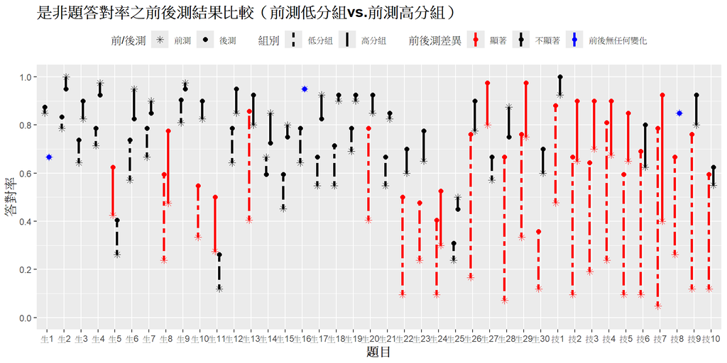

```r
res_low<-yn.prepost.table(Cdat1_yn[which(gpre.low),], Cdat2_yn[which(gpre.low),])
res_high<-yn.prepost.table(Cdat1_yn[which(gpre.high),], Cdat2_yn[which(gpre.high),])
res<-rbind(res_low, res_high)

yn.prepost.plot.lowhigh(res, "是非題答對率之前後測結果比較（前測低分組vs.前測高分組）")
```

### **1-4-3 鑑別度、難度分析（前測低分組vs.前測高分組）**

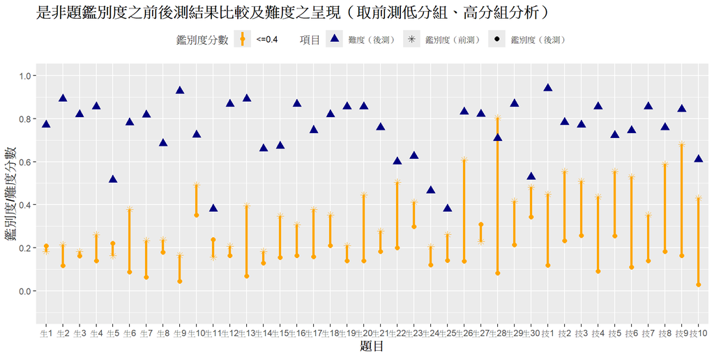

```r
kk<-yn.prepost.lowhigh.table(Cdat1_yn[which(gpre.low),],Cdat2_yn[which(gpre.low),],Cdat1_yn[which(gpre.high),],Cdat2_yn[which(gpre.high),])

yn.prepost.plot.lowhigh.D(kk, "是非題鑑別度之前後測結果比較及難度之呈現（取前測低分組、高分組分析）")
```

### **1-4-4 全部生是非、知識性質及覺察類是非題彙整表格（前測低分組n=42 vs.前測高分組n=40）**

```r
kk<-mean_table_all2(Cdat1_yn%>%filter(gpre.low), Cdat2_yn%>%filter(gpre.low),
               Cdat1_yn%>%filter(gpre.high), Cdat2_yn%>%filter(gpre.high), state=6)

kk[[1]]%>%kableExtra::kable("html",escape = F,booktabs = TRUE,digits=c(0,0,3,2,3,2,3,3,3,3,3,3,3,3,3,3,3,3),caption="1-4-4 全部生是非、知識性質及覺察類是非題彙整表格（前測低分組n=42 vs.前測高分組n=40）")%>%
  kable_styling(c("striped", "bordered"))%>%
  add_header_above(c(" " = 2, "前測" = 2, "後測" = 2,"前後測成對t檢定" = 3, "高分組-低分組獨立t檢定 (進步量)"=3, "高分組-低分組獨立t檢定 (前測)"=3, "高分組-低分組獨立t檢定 (後測)"=3))%>%
  column_spec(1, bold = T)%>%
  collapse_rows(columns = c(1,10:18))
```

1-4-4 全部生是非、知識性質及覺察類是非題彙整表格（前測低分組n=42 vs.前測高分組n=40）

[output not shown]

### **1-4-5 全部生是非、知識性質及覺察類是非題盒形圖（前測低分組n=42 vs.前測高分組n=40）**

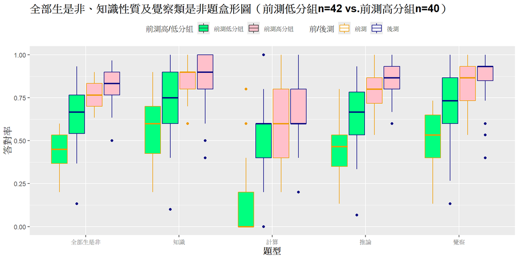

```r
yn.prepost.compare.boxplot(Cdat1_yn%>%filter(gpre.low), Cdat2_yn%>%filter(gpre.low),
               Cdat1_yn%>%filter(gpre.high), Cdat2_yn%>%filter(gpre.high), state=6, title="全部生是非、知識性質及覺察類是非題盒形圖（前測低分組n=42 vs.前測高分組n=40）")
```

## **1-5 前測高/低分組的後測總得分之敘述統計**

```r
out<-matrix(NA,6,8)
out[,1]<-rep(c("低分組","高分組"), each=3)
out[,2]<-rep(c("低分組","平均組","高分組"),2)
colnames(out)<-c("前測組別","後測組別","組內人數","最低分數","第1四分位數(下界)","中位數","第3四分位數(上界)","最高分數")

gg<-list((gpre.low & gpost.low),
           (gpre.low & !(gpost.low|gpost.high)),
           (gpre.low & gpost.high),
           (gpre.high & gpost.low),
           (gpre.high & !(gpost.low|gpre.high & gpost.high)),
           (gpre.high & gpost.high))

out[,3]<-sapply(gg,sum)

out[,4:8]<-sapply(gg, function(i) fivenum(Cdat2_yn[i,]$總得分))%>%t()

out%>%kable("html",escape = F,booktabs = TRUE, caption="1-5 前測高/低分組的後測總得分之敘述統計")%>%
  kable_styling(c("striped", "bordered"))%>%
  column_spec(1, bold = T)%>%
  collapse_rows(columns = 1)
```

1-5 前測高/低分組的後測總得分之敘述統計

| 前測組別 | 後測組別 | 組內人數 | 最低分數 | 第1四分位數(下界) | 中位數 | 第3四分位數(上界) | 最高分數 |
| --- | --- | --- | --- | --- | --- | --- | --- |
| 低分組 | 低分組 | 20 | 17.5 | 45 | 52.5 | 61.25 | 67.5 |
|  | 平均組 | 17 | 70 | 72.5 | 77.5 | 80 | 82.5 |
|  | 高分組 | 5 | 85 | 85 | 87.5 | 87.5 | 90 |
| 高分組 | 低分組 | 3 | 50 | 57.5 | 65 | 66.25 | 67.5 |
|  | 平均組 | 14 | 70 | 72.5 | 80 | 82.5 | 82.5 |
|  | 高分組 | 23 | 85 | 86.25 | 87.5 | 92.5 | 97.5 |

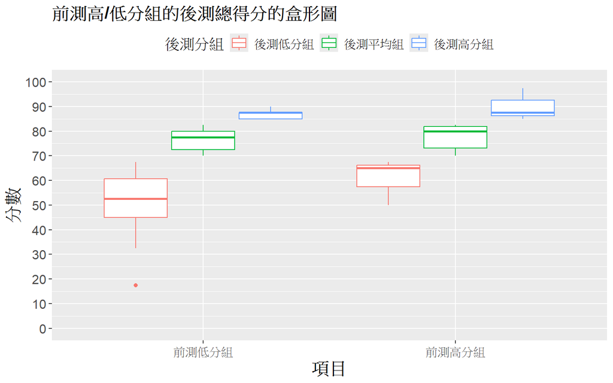

```r
Cdat2_yn[["前測分組"]]<-ifelse(gpre.low,"前測低分組",ifelse(gpre.high,"前測高分組","前測平均組"))%>%factor(levels = c("前測低分組","前測平均組","前測高分組"))
Cdat2_yn[["後測分組"]]<-ifelse(gpost.low,"後測低分組",ifelse(gpost.high,"後測高分組","後測平均組"))%>%factor(levels = c("後測低分組","後測平均組","後測高分組"))

Cdat2_yn%>%filter(前測分組!="前測平均組")%>%
  dplyr::select(`總得分`,`前測分組`,`後測分組`) %>%
  # gather 所有變數，除了 island 之外(要當成獨立一個欄位，做為群組)
  gather(key = 'variable', value = 'measurements', -c(`後測分組`,`前測分組`))%>%
  ggplot(mapping = aes(x = `前測分組`, y = measurements, col = `後測分組`)) +
    # 繪製盒鬚圖，使用 position_dodge 調整間距
    geom_boxplot(position = position_dodge(0.8)) +
    # 修改 x 軸標籤為 Soil properties
    labs(x = '項目',y="分數", title="前測高/低分組的後測總得分的盒形圖")+
    scale_y_continuous(limits=c(0,100),breaks = seq(0,100,10))+
    theme(legend.position = "top", plot.title = element_text(face="bold",size=16),
          legend.title = element_text(size=14),
          legend.text = element_text(size=12),
          axis.title.x = element_text(face="bold",size=16),
          axis.title.y = element_text(face="bold",size=16),
          axis.text.x = element_text(size=12),
          axis.text.y = element_text(size=12))
```

# **2. 表格彙整**

## **2-1 計算全部人/國中生/高中生答對率彙整表格（分成生是非、技是非兩種情形）**

```r
mean_score<-matrix(NA,3,12)
rownames(mean_score)<-c("全部人 (n=146)","國中生 (n=88)","高中生 (n=58)")
colnames(mean_score)<-rep(c("平均答對率","標準差","平均答對率","標準差","t統計量","p-value"),2)

mean_score[1,]<-mean_table(Cdat1_yn, Cdat2_yn)
mean_score[2,]<-mean_table(Cdat1_yn.ju, Cdat2_yn.ju)
mean_score[3,]<-mean_table(Cdat1_yn.se, Cdat2_yn.se)

mean_score[,c(6,12)]<-"0***"

#mean_score[,12]<-str_c(mean_score[,12]%>%as.numeric()%>%round(digits=3),cut(mean_score[,12]%>%as.numeric(), breaks=c(0,0.001,0.01,0.05,1),labels=c("***","**","*","")))

mean_score%>%kableExtra::kable("html",escape = F,booktabs = TRUE,caption="2-1 計算全部人/國中生/高中生答對率彙整表格（分成生是非、技是非兩種情形）")%>%
  kable_styling(c("striped", "bordered"))%>%
  add_header_above(c(" " = 1, "前測" = 2, "後測" = 2, "前後測成對t檢定" = 2,  "前測" = 2, "後測" = 2, "前後測成對t檢定" = 2))%>%
  add_header_above(c(" " = 1, "生是非" = 6, "技是非" = 6))%>%
  column_spec(1, bold = T)
```

2-1 計算全部人/國中生/高中生答對率彙整表格（分成生是非、技是非兩種情形）

|  | 生是非 前測 平均答對率 | 生是非 前測 標準差 | 生是非 後測 平均答對率 | 生是非 後測 標準差 | 生是非 前後測成對t檢定 t統計量 | 生是非 前後測成對t檢定 p-value | 技是非 前測 平均答對率 | 技是非 前測 標準差 | 技是非 後測 平均答對率 | 技是非 後測 標準差 | 技是非 前後測成對t檢定 t統計量 | 技是非 前後測成對t檢定 p-value |
| --- | --- | --- | --- | --- | --- | --- | --- | --- | --- | --- | --- | --- |
| 全部人 (n=146) | 0.619 | 0.15 | 0.716 | 0.15 | 7.098 | 0*** | 0.375 | 0.29 | 0.787 | 0.26 | 14.56 | 0*** |
| 國中生 (n=88) | 0.59 | 0.15 | 0.693 | 0.17 | 5.521 | 0*** | 0.318 | 0.27 | 0.739 | 0.28 | 11.774 | 0*** |
| 高中生 (n=58) | 0.663 | 0.15 | 0.75 | 0.12 | 4.473 | 0*** | 0.46 | 0.3 | 0.86 | 0.18 | 8.571 | 0*** |

```r
#write.xlsx(mean_score, rowNames=T,startCol=1,"C:/Users/h2407/OneDrive/文件/1121/師培中心分析案/報表資料檔/生是非與技是非的整體平均.xlsx")
```

## **2-2 計算全部人/國中生/高中生的分數彙整表格（分成全部是非題、僅覺察類兩種情形）**

```r
# 針對不同人分數的檢定（自由度來自人數）
mean_table.allsense<-function(data1,data2){

  all.pre<-data1$總得分
  all.post<-data2$總得分
  t_all<-t.test(all.post,all.pre,paired=T)
  t.all<-t_all$statistic[[1]]%>%round(digits=3)
  p.all<-t_all$p.value

  sense.pre<-rowSums(sapply(colnames(ans)[which(typee$sense==1)],function(i) (data1[[i]]==ans[[i]])))*2.5*length(ans)/sum(typee$sense==1)
  sense.post<-rowSums(sapply(colnames(ans)[which(typee$sense==1)],function(i) (data2[[i]]==ans[[i]])))*2.5*length(ans)/sum(typee$sense==1)
  t_sense<-t.test(sense.post,sense.pre,paired=T)
  t.sense<-t_sense$statistic[[1]]%>%round(digits=3)
  p.sense<-t_sense$p.value

  return(c(mean(all.pre)%>%round(digits=2),sd(all.pre)%>%round(digits=1),
           mean(all.post)%>%round(digits=2),sd(all.post)%>%round(digits=1),t.all,p.all,
           mean(sense.pre)%>%round(digits=2),sd(sense.pre)%>%round(digits=1),
           mean(sense.post)%>%round(digits=2),sd(sense.post)%>%round(digits=1),t.sense,p.sense))
}
```

```r
mean_score<-matrix(NA,3,12)
rownames(mean_score)<-c("全部人 (n=146)","國中生 (n=88)","高中生 (n=58)")
colnames(mean_score)<-rep(c("平均分數","標準差","平均分數","標準差","t統計量","p-value"),2)

mean_score[1,]<-mean_table.allsense(Cdat1_yn, Cdat2_yn)
mean_score[2,]<-mean_table.allsense(Cdat1_yn.ju, Cdat2_yn.ju)
mean_score[3,]<-mean_table.allsense(Cdat1_yn.se, Cdat2_yn.se)

mean_score[,c(6,12)]<-"0***"

# mean_score[,6]<-str_c(mean_score[,6]%>%as.numeric()%>%round(digits=3),cut(mean_score[,6]%>%as.numeric(), breaks=c(0,0.001,0.01,0.05,1),labels=c("***","**","*","")))
#
# mean_score[,12]<-str_c(mean_score[,12]%>%as.numeric()%>%round(digits=3),cut(mean_score[,12]%>%as.numeric(), breaks=c(0,0.001,0.01,0.05,1),labels=c("***","**","*","")))

mean_score%>%kableExtra::kable("html",escape = F,booktabs = TRUE,caption="2-2 計算全部人/國中生/高中生的分數彙整表格（分成全部是非題、僅覺察類兩種情形）")%>%
  kable_styling(c("striped", "bordered"))%>%
  add_header_above(c(" " = 1, "前測" = 2, "後測" = 2, "前後測成對t檢定" = 2,  "前測" = 2, "後測" = 2, "前後測成對t檢定" = 2))%>%
  add_header_above(c(" " = 1, "全部是非題" = 6, "覺察類" = 6))%>%
  column_spec(1, bold = T)
```

2-2 計算全部人/國中生/高中生的分數彙整表格（分成全部是非題、僅覺察類兩種情形）

|  | 全部是非題 前測 平均分數 | 全部是非題 前測 標準差 | 全部是非題 後測 平均分數 | 全部是非題 後測 標準差 | 全部是非題 前後測成對t檢定 t統計量 | 全部是非題 前後測成對t檢定 p-value | 覺察類 前測 平均分數 | 覺察類 前測 標準差 | 覺察類 後測 平均分數 | 覺察類 後測 標準差 | 覺察類 前後測成對t檢定 t統計量 | 覺察類 前後測成對t檢定 p-value |
| --- | --- | --- | --- | --- | --- | --- | --- | --- | --- | --- | --- | --- |
| 全部人 (n=146) | 55.79 | 15.3 | 73.32 | 15.6 | 12.906 | 0*** | 68.36 | 18.3 | 77.49 | 18.5 | 5.624 | 0*** |
| 國中生 (n=88) | 52.19 | 14.7 | 70.4 | 17.7 | 9.677 | 0*** | 65.15 | 18.9 | 74.62 | 20 | 4.326 | 0*** |
| 高中生 (n=58) | 61.25 | 14.7 | 77.76 | 10.3 | 8.715 | 0*** | 73.22 | 16.2 | 81.84 | 15.2 | 3.585 | 0*** |

```r
#write.xlsx(mean_score, rowNames=T,startCol=1,"C:/Users/h2407/OneDrive/文件/1121/師培中心分析案/報表資料檔/生是非與技是非的整體平均.xlsx")
```

```r
mean_table.lifes<-function(data1,data2,topic){
  if(topic=="覺察"){
    dd<-yn_life.prepost.table(data1,data2)%>%filter(覺察==1)
    res<-matrix(NA, 1, 6)
    mean.pre<-mean(dd$`答對率（前測）`);mean.post<-mean(dd$`答對率（後測）`)
    sd.pre<-sd(dd$`答對率（前測）`);sd.post<-sd(dd$`答對率（後測）`)
    ttest<-t.test(dd$`答對率（後測）`,dd$`答對率（前測）`,paired=T)
    t.test.t<-ttest$statistic[[1]]
    t.test.p<-ttest$p.value
  }else{
    dd<-yn_life.prepost.table(data1,data2)
    res<-matrix(NA, length(levels(dd[[topic]])), 6)
    mean.pre<-aggregate(dd$`答對率（前測）`,list(dd[[topic]]),"mean")$x
    mean.post<-aggregate(dd$`答對率（後測）`,list(dd[[topic]]),"mean")$x
    sd.pre<-aggregate(dd$`答對率（前測）`,list(dd[[topic]]),"sd")$x
    sd.post<-aggregate(dd$`答對率（後測）`,list(dd[[topic]]),"sd")$x
    t.test.t<-t.test.p<-c()
    for(i in levels(dd[[topic]])){
      if(sum(dd[[topic]]==i)<=2){
        t.test.t<-c(t.test.t,NA); t.test.p<-c(t.test.p,NA)
        next
      }
      group.pre<-dd[dd[[topic]]==i,]$`答對率（前測）`
      group.post<-dd[dd[[topic]]==i,]$`答對率（後測）`
      ttest<-t.test(group.post,group.pre,paired=T)
      t<-ttest$statistic[[1]]
      p<-ttest$p.value
      t.test.t<-c(t.test.t, t); t.test.p<-c(t.test.p, p)
      # s<-sapply(dd[dd[[topic]]==i,]%>%rownames(), function(i) data2[[i]]==ans[[i]])%>%as.vector()
      # s2<-sapply(dd[dd[[topic]]==i,]%>%rownames(), function(i) data1[[i]]==ans[[i]])%>%as.vector()
      # t.test(s, s2, pair=T)
    }
  }
  res[,1]<-mean.pre
  res[,2]<-mean.post
  res[,3]<-sd.pre
  res[,4]<-sd.post
  res[,5]<-t.test.t
  res[,6]<-t.test.p
  return(res)
}
```

## **2-3-1 知識性質及覺察類是非題彙整表格（全部人n=146）**

```r
out<-matrix(NA,4,6)%>%as.data.frame()
rownames(out)<-c("知識","推論","計算","覺察")
colnames(out)<-rep(c("平均答對率","標準差","平均答對率","標準差","t統計量","p-value"))

out[1:3,]<-mean_table.lifes(Cdat1_yn, Cdat2_yn, "知識性質")
out[4,]<-mean_table.lifes(Cdat1_yn, Cdat2_yn, "覺察")[1,]

out[,6]<-str_c(out[,6]%>%round(digits=3),cut(out[,6], breaks=c(0,0.001,0.01,0.05,1),labels=c("***","**","*","")))

out%>%kableExtra::kable("html",escape = F,booktabs = TRUE,digits=c(3,2,3,2,3,3),caption="2-3-1 知識性質及覺察類是非題彙整表格（全部人n=146）")%>%
  kable_styling(c("striped", "bordered"))%>%
  add_header_above(c(" " = 1, "前測" = 2, "後測" = 2,"前後測成對t檢定" = 2))%>%
  add_header_above(c(" " = 1, "全部人 (n=146)" = 6))%>%
  column_spec(1, bold = T)
```

2-3-1 知識性質及覺察類是非題彙整表格（全部人n=146）

[output not shown]

## **2-3-2 知識性質及覺察類是非題彙整表格（國中生）**

```r
out<-matrix(NA,4,6)%>%as.data.frame()
rownames(out)<-c("知識","推論","計算","覺察")
colnames(out)<-rep(c("平均答對率","標準差","平均答對率","標準差","t統計量","p-value"))

out[1:3,]<-mean_table.lifes(Cdat1_yn.ju, Cdat2_yn.ju, "知識性質")
out[4,]<-mean_table.lifes(Cdat1_yn.ju, Cdat2_yn.ju, "覺察")[1,]

out[,6]<-str_c(out[,6]%>%round(digits=3),cut(out[,6], breaks=c(0,0.001,0.01,0.05,1),labels=c("***","**","*","")))

out%>%kableExtra::kable("html",escape = F,booktabs = TRUE,digits=c(3,2,3,2,3,3),caption="2-3-2 知識性質及覺察類是非題彙整表格（國中生）")%>%
  kable_styling(c("striped", "bordered"))%>%
  add_header_above(c(" " = 1, "前測" = 2, "後測" = 2,"前後測成對t檢定" = 2))%>%
  add_header_above(c(" " = 1, "國中生(n=88)" = 6))%>%
  column_spec(1, bold = T)
```

2-3-2 知識性質及覺察類是非題彙整表格（國中生）

[output not shown]

## **2-3-3 知識性質及覺察類是非題彙整表格（高中生）**

```r
out<-matrix(NA,4,6)%>%as.data.frame()
rownames(out)<-c("知識","推論","計算","覺察")
colnames(out)<-rep(c("平均答對率","標準差","平均答對率","標準差","t統計量","p-value"))

out[1:3,]<-mean_table.lifes(Cdat1_yn.se, Cdat2_yn.se, "知識性質")
out[4,]<-mean_table.lifes(Cdat1_yn.se, Cdat2_yn.se, "覺察")[1,]

out[,1:5]<-sapply(1:5, function(i) out[,i]%>%as.numeric())

out[,6]<-str_c(out[,6]%>%round(digits=3),cut(out[,6], breaks=c(0,0.001,0.01,0.05,1),labels=c("***","**","*","")))

out%>%kableExtra::kable("html",escape = F,booktabs = TRUE,digits=c(3,2,3,2,3,3),caption="2-3-3 知識性質及覺察類是非題彙整表格（高中生）")%>%
  kable_styling(c("striped", "bordered"))%>%
  add_header_above(c(" " = 1, "前測" = 2, "後測" = 2,"前後測成對t檢定" = 2))%>%
  add_header_above(c(" " = 1, "高中生(n=58)" = 6))%>%
  column_spec(1, bold = T)
```

2-3-3 知識性質及覺察類是非題彙整表格（高中生）

[output not shown]

# **3. 是非題前後測分析（生是非+技是非）**

## **3-1 是非題前後測答對率（全部人n=146）**

```r
paste("樣本數 =",dim(Cdat1_yn)[1])
```

```
## [1] "樣本數 = 146"
```

```r
kk<-yn.prepost.table(Cdat1_yn, Cdat2_yn)[,-1]
colnames(kk)<-c("平均答對率","標準差","平均答對率","標準差","t統計量","p-value","檢定結果")

kk[,6]<-str_c(kk[,6]%>%round(digits=3),cut(kk[,6], breaks=c(0,0.001,0.01,0.05,1),labels=c("***","**","*","")))

kk%>%kable("html",escape = F,booktabs = TRUE, digits=c(3,2,3,2,3,3,3), caption="1-1 是非題前後測答對率（全部人n=146）")%>%
  kable_styling(c("striped", "bordered"))%>%
  add_header_above(c(" " = 1, "前測" = 2, "後測" = 2, "前後測成對t檢定" = 3))%>%
  column_spec(1, bold = T)%>%
  group_rows("生是非", 1, 30)%>%
  group_rows("技是非", 31, 40)
```

1-1 是非題前後測答對率（全部人n=146）

|  | 前測 平均答對率 | 前測 標準差 | 後測 平均答對率 | 後測 標準差 | 前後測成對t檢定 t統計量 | 前後測成對t檢定 p-value | 前後測成對t檢定 檢定結果 |
| --- | --- | --- | --- | --- | --- | --- | --- |
| **生是非** |  |  |  |  |  |  |  |
| 生是非1 | 0.753 | 0.43 | 0.760 | 0.43 | 0.173 | 0.863 | Don’t Reject H0 |
| 生是非2 | 0.911 | 0.29 | 0.904 | 0.30 | -0.229 | 0.819 | Don’t Reject H0 |
| 生是非3 | 0.767 | 0.42 | 0.829 | 0.38 | 1.486 | 0.14 | Don’t Reject H0 |
| 生是非4 | 0.842 | 0.37 | 0.795 | 0.41 | -1.405 | 0.162 | Don’t Reject H0 |
| 生是非5 | 0.397 | 0.49 | 0.493 | 0.50 | 2.136 | 0.034* | Reject H0 |
| 生是非6 | 0.767 | 0.42 | 0.781 | 0.42 | 0.342 | 0.733 | Don’t Reject H0 |
| 生是非7 | 0.795 | 0.41 | 0.822 | 0.38 | 0.631 | 0.529 | Don’t Reject H0 |
| 生是非8 | 0.452 | 0.50 | 0.658 | 0.48 | 4.323 | 0*** | Reject H0 |
| 生是非9 | 0.897 | 0.30 | 0.884 | 0.32 | -0.446 | 0.656 | Don’t Reject H0 |
| 生是非10 | 0.644 | 0.48 | 0.733 | 0.44 | 1.766 | 0.08 | Don’t Reject H0 |
| 生是非11 | 0.185 | 0.39 | 0.384 | 0.49 | 4.037 | 0*** | Reject H0 |
| 生是非12 | 0.753 | 0.43 | 0.822 | 0.38 | 1.514 | 0.132 | Don’t Reject H0 |
| 生是非13 | 0.610 | 0.49 | 0.842 | 0.37 | 4.695 | 0*** | Reject H0 |
| 生是非14 | 0.719 | 0.45 | 0.651 | 0.48 | -1.514 | 0.132 | Don’t Reject H0 |
| 生是非15 | 0.685 | 0.47 | 0.726 | 0.45 | 1.029 | 0.305 | Don’t Reject H0 |
| 生是非16 | 0.870 | 0.34 | 0.877 | 0.33 | 0.208 | 0.836 | Don’t Reject H0 |
| 生是非17 | 0.774 | 0.42 | 0.747 | 0.44 | -0.576 | 0.565 | Don’t Reject H0 |
| 生是非18 | 0.733 | 0.44 | 0.801 | 0.40 | 1.589 | 0.114 | Don’t Reject H0 |
| 生是非19 | 0.808 | 0.40 | 0.829 | 0.38 | 0.538 | 0.592 | Don’t Reject H0 |
| 生是非20 | 0.664 | 0.47 | 0.801 | 0.40 | 2.963 | 0.004** | Reject H0 |
| 生是非21 | 0.726 | 0.45 | 0.774 | 0.42 | 1.122 | 0.264 | Don’t Reject H0 |
| 生是非22 | 0.322 | 0.47 | 0.575 | 0.50 | 4.857 | 0*** | Reject H0 |
| 生是非23 | 0.425 | 0.50 | 0.610 | 0.49 | 4.152 | 0*** | Reject H0 |
| 生是非24 | 0.205 | 0.41 | 0.390 | 0.49 | 3.661 | 0*** | Reject H0 |
| 生是非25 | 0.295 | 0.46 | 0.370 | 0.48 | 1.688 | 0.094 | Don’t Reject H0 |
| 生是非26 | 0.466 | 0.50 | 0.822 | 0.38 | 7.367 | 0*** | Reject H0 |
| 生是非27 | 0.705 | 0.46 | 0.795 | 0.41 | 1.957 | 0.052 | Don’t Reject H0 |
| 生是非28 | 0.459 | 0.50 | 0.664 | 0.47 | 3.685 | 0*** | Reject H0 |
| 生是非29 | 0.582 | 0.49 | 0.856 | 0.35 | 5.940 | 0*** | Reject H0 |
| 生是非30 | 0.356 | 0.48 | 0.473 | 0.50 | 2.471 | 0.015* | Reject H0 |
| **技是非** |  |  |  |  |  |  |  |
| 技是非1 | 0.692 | 0.46 | 0.918 | 0.28 | 5.516 | 0*** | Reject H0 |
| 技是非2 | 0.315 | 0.47 | 0.760 | 0.43 | 9.544 | 0*** | Reject H0 |
| 技是非3 | 0.425 | 0.50 | 0.808 | 0.40 | 8.182 | 0*** | Reject H0 |
| 技是非4 | 0.404 | 0.49 | 0.849 | 0.36 | 9.155 | 0*** | Reject H0 |
| 技是非5 | 0.363 | 0.48 | 0.753 | 0.43 | 7.974 | 0*** | Reject H0 |
| 技是非6 | 0.247 | 0.43 | 0.753 | 0.43 | 9.990 | 0*** | Reject H0 |
| 技是非7 | 0.171 | 0.38 | 0.829 | 0.38 | 15.344 | 0*** | Reject H0 |
| 技是非8 | 0.521 | 0.50 | 0.753 | 0.43 | 4.991 | 0*** | Reject H0 |
| 技是非9 | 0.363 | 0.48 | 0.842 | 0.37 | 9.823 | 0*** | Reject H0 |
| 技是非10 | 0.247 | 0.43 | 0.603 | 0.49 | 6.609 | 0*** | Reject H0 |

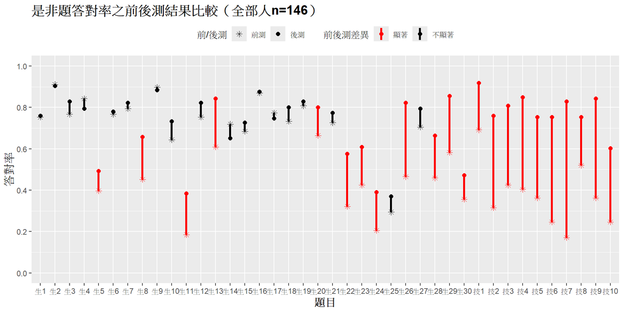

```r
yn.prepost.plot(Cdat1_yn, Cdat2_yn, "是非題答對率之前後測結果比較（全部人n=146）")
```

## **3-2 是非題前後測答對率（國中生n=88）**

```r
paste("樣本數 =",dim(Cdat1_yn.ju)[1])
```

```
## [1] "樣本數 = 88"
```

```r
kk<-yn.prepost.table(Cdat1_yn.ju, Cdat2_yn.ju)[,-1]
colnames(kk)<-c("平均答對率","標準差","平均答對率","標準差","t統計量","p-value","檢定結果")

kk[,6]<-str_c(kk[,6]%>%round(digits=3),cut(kk[,6], breaks=c(0,0.001,0.01,0.05,1),labels=c("***","**","*","")))

kk%>%kable("html",escape = F,booktabs = TRUE, digits=c(3,2,3,2,3,3,3),caption="1-2 是非題前後測答對率（國中生n=88）")%>%
  kable_styling(c("striped", "bordered"))%>%
  add_header_above(c(" " = 1, "前測" = 2, "後測" = 2, "前後測成對t檢定" = 3))%>%
  column_spec(1, bold = T)%>%
  group_rows("生是非", 1, 30)%>%
  group_rows("技是非", 31, 40)
```

1-2 是非題前後測答對率（國中生n=88）

|  | 前測 平均答對率 | 前測 標準差 | 後測 平均答對率 | 後測 標準差 | 前後測成對t檢定 t統計量 | 前後測成對t檢定 p-value | 前後測成對t檢定 檢定結果 |
| --- | --- | --- | --- | --- | --- | --- | --- |
| **生是非** |  |  |  |  |  |  |  |
| 生是非1 | 0.693 | 0.46 | 0.705 | 0.46 | 0.207 | 0.836 | Don’t Reject H0 |
| 生是非2 | 0.909 | 0.29 | 0.875 | 0.33 | -0.904 | 0.369 | Don’t Reject H0 |
| 生是非3 | 0.773 | 0.42 | 0.795 | 0.41 | 0.445 | 0.657 | Don’t Reject H0 |
| 生是非4 | 0.784 | 0.41 | 0.795 | 0.41 | 0.257 | 0.798 | Don’t Reject H0 |
| 生是非5 | 0.420 | 0.50 | 0.489 | 0.50 | 1.179 | 0.241 | Don’t Reject H0 |
| 生是非6 | 0.727 | 0.45 | 0.750 | 0.44 | 0.406 | 0.686 | Don’t Reject H0 |
| 生是非7 | 0.773 | 0.42 | 0.852 | 0.36 | 1.469 | 0.145 | Don’t Reject H0 |
| 生是非8 | 0.443 | 0.50 | 0.636 | 0.48 | 3.101 | 0.003** | Reject H0 |
| 生是非9 | 0.875 | 0.33 | 0.841 | 0.37 | -0.831 | 0.408 | Don’t Reject H0 |
| 生是非10 | 0.614 | 0.49 | 0.693 | 0.46 | 1.186 | 0.239 | Don’t Reject H0 |
| 生是非11 | 0.182 | 0.39 | 0.409 | 0.49 | 3.438 | 0.001*** | Reject H0 |
| 生是非12 | 0.682 | 0.47 | 0.784 | 0.41 | 1.632 | 0.106 | Don’t Reject H0 |
| 生是非13 | 0.580 | 0.50 | 0.795 | 0.41 | 3.294 | 0.001** | Reject H0 |
| 生是非14 | 0.716 | 0.45 | 0.670 | 0.47 | -0.783 | 0.436 | Don’t Reject H0 |
| 生是非15 | 0.670 | 0.47 | 0.716 | 0.45 | 1.000 | 0.32 | Don’t Reject H0 |
| 生是非16 | 0.818 | 0.39 | 0.852 | 0.36 | 0.773 | 0.442 | Don’t Reject H0 |
| 生是非17 | 0.773 | 0.42 | 0.670 | 0.47 | -1.580 | 0.118 | Don’t Reject H0 |
| 生是非18 | 0.727 | 0.45 | 0.795 | 0.41 | 1.284 | 0.203 | Don’t Reject H0 |
| 生是非19 | 0.784 | 0.41 | 0.830 | 0.38 | 0.893 | 0.374 | Don’t Reject H0 |
| 生是非20 | 0.670 | 0.47 | 0.807 | 0.40 | 2.240 | 0.028* | Reject H0 |
| 生是非21 | 0.693 | 0.46 | 0.773 | 0.42 | 1.354 | 0.179 | Don’t Reject H0 |
| 生是非22 | 0.284 | 0.45 | 0.591 | 0.49 | 4.844 | 0*** | Reject H0 |
| 生是非23 | 0.307 | 0.46 | 0.534 | 0.50 | 3.795 | 0*** | Reject H0 |
| 生是非24 | 0.239 | 0.43 | 0.409 | 0.49 | 2.541 | 0.013* | Reject H0 |
| 生是非25 | 0.239 | 0.43 | 0.307 | 0.46 | 1.284 | 0.203 | Don’t Reject H0 |
| 生是非26 | 0.375 | 0.49 | 0.761 | 0.43 | 6.085 | 0*** | Reject H0 |
| 生是非27 | 0.693 | 0.46 | 0.773 | 0.42 | 1.354 | 0.179 | Don’t Reject H0 |
| 生是非28 | 0.409 | 0.49 | 0.636 | 0.48 | 3.340 | 0.001** | Reject H0 |
| 生是非29 | 0.523 | 0.50 | 0.795 | 0.41 | 4.397 | 0*** | Reject H0 |
| 生是非30 | 0.318 | 0.47 | 0.443 | 0.50 | 1.945 | 0.055 | Don’t Reject H0 |
| **技是非** |  |  |  |  |  |  |  |
| 技是非1 | 0.648 | 0.48 | 0.898 | 0.30 | 4.419 | 0*** | Reject H0 |
| 技是非2 | 0.227 | 0.42 | 0.659 | 0.48 | 7.193 | 0*** | Reject H0 |
| 技是非3 | 0.352 | 0.48 | 0.727 | 0.45 | 5.929 | 0*** | Reject H0 |
| 技是非4 | 0.375 | 0.49 | 0.807 | 0.40 | 6.519 | 0*** | Reject H0 |
| 技是非5 | 0.284 | 0.45 | 0.670 | 0.47 | 6.523 | 0*** | Reject H0 |
| 技是非6 | 0.182 | 0.39 | 0.693 | 0.46 | 7.675 | 0*** | Reject H0 |
| 技是非7 | 0.148 | 0.36 | 0.761 | 0.43 | 10.768 | 0*** | Reject H0 |
| 技是非8 | 0.455 | 0.50 | 0.693 | 0.46 | 4.263 | 0*** | Reject H0 |
| 技是非9 | 0.295 | 0.46 | 0.818 | 0.39 | 8.357 | 0*** | Reject H0 |
| 技是非10 | 0.216 | 0.41 | 0.659 | 0.48 | 6.886 | 0*** | Reject H0 |

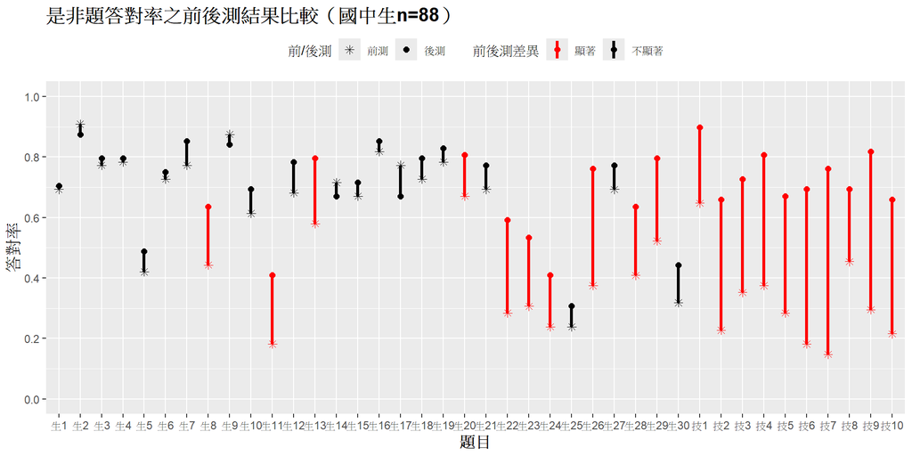

```r
yn.prepost.plot(Cdat1_yn.ju, Cdat2_yn.ju, "是非題答對率之前後測結果比較（國中生n=88）")
```

## **3-3 是非題前後測答對率（高中生n=58）**

```r
paste("樣本數 =",dim(Cdat1_yn.se)[1])
```

```
## [1] "樣本數 = 58"
```

```r
kk<-yn.prepost.table(Cdat1_yn.se, Cdat2_yn.se)[,-1]
colnames(kk)<-c("平均答對率","標準差","平均答對率","標準差","t統計量","p-value","檢定結果")

kk[,6]<-str_c(kk[,6]%>%round(digits=3),cut(kk[,6], breaks=c(0,0.001,0.01,0.05,1),labels=c("***","**","*","")))

kk%>%kable("html",escape = F,booktabs = TRUE, digits=c(3,2,3,2,3,3,3),caption="1-3 是非題前後測答對率（高中生n=58）")%>%
  kable_styling(c("striped", "bordered"))%>%
  add_header_above(c(" " = 1, "前測" = 2, "後測" = 2, "前後測成對t檢定" = 3))%>%
  column_spec(1, bold = T)%>%
  group_rows("生是非", 1, 30)%>%
  group_rows("技是非", 31, 40)
```

1-3 是非題前後測答對率（高中生n=58）

|  | 前測 平均答對率 | 前測 標準差 | 後測 平均答對率 | 後測 標準差 | 前後測成對t檢定 t統計量 | 前後測成對t檢定 p-value | 前後測成對t檢定 檢定結果 |
| --- | --- | --- | --- | --- | --- | --- | --- |
| **生是非** |  |  |  |  |  |  |  |
| 生是非1 | 0.845 | 0.37 | 0.845 | 0.37 | 0.000 | 1 | No Change |
| 生是非2 | 0.914 | 0.28 | 0.948 | 0.22 | 0.704 | 0.484 | Don’t Reject H0 |
| 生是非3 | 0.759 | 0.43 | 0.879 | 0.33 | 1.726 | 0.09 | Don’t Reject H0 |
| 生是非4 | 0.931 | 0.26 | 0.793 | 0.41 | -2.659 | 0.01* | Reject H0 |
| 生是非5 | 0.362 | 0.48 | 0.500 | 0.50 | 1.929 | 0.059 | Don’t Reject H0 |
| 生是非6 | 0.828 | 0.38 | 0.828 | 0.38 | 0.000 | 1 | No Change |
| 生是非7 | 0.828 | 0.38 | 0.776 | 0.42 | -0.725 | 0.472 | Don’t Reject H0 |
| 生是非8 | 0.466 | 0.50 | 0.690 | 0.47 | 3.030 | 0.004** | Reject H0 |
| 生是非9 | 0.931 | 0.26 | 0.948 | 0.22 | 0.375 | 0.709 | Don’t Reject H0 |
| 生是非10 | 0.690 | 0.47 | 0.793 | 0.41 | 1.351 | 0.182 | Don’t Reject H0 |
| 生是非11 | 0.190 | 0.40 | 0.345 | 0.48 | 2.127 | 0.038* | Reject H0 |
| 生是非12 | 0.862 | 0.35 | 0.879 | 0.33 | 0.275 | 0.784 | Don’t Reject H0 |
| 生是非13 | 0.655 | 0.48 | 0.914 | 0.28 | 3.401 | 0.001** | Reject H0 |
| 生是非14 | 0.724 | 0.45 | 0.621 | 0.49 | -1.427 | 0.159 | Don’t Reject H0 |
| 生是非15 | 0.707 | 0.46 | 0.741 | 0.44 | 0.468 | 0.641 | Don’t Reject H0 |
| 生是非16 | 0.948 | 0.22 | 0.914 | 0.28 | -0.704 | 0.484 | Don’t Reject H0 |
| 生是非17 | 0.776 | 0.42 | 0.862 | 0.35 | 1.299 | 0.199 | Don’t Reject H0 |
| 生是非18 | 0.741 | 0.44 | 0.810 | 0.40 | 0.942 | 0.35 | Don’t Reject H0 |
| 生是非19 | 0.845 | 0.37 | 0.828 | 0.38 | -0.299 | 0.766 | Don’t Reject H0 |
| 生是非20 | 0.655 | 0.48 | 0.793 | 0.41 | 1.929 | 0.059 | Don’t Reject H0 |
| 生是非21 | 0.776 | 0.42 | 0.776 | 0.42 | 0.000 | 1 | No Change |
| 生是非22 | 0.379 | 0.49 | 0.552 | 0.50 | 1.934 | 0.058 | Don’t Reject H0 |
| 生是非23 | 0.603 | 0.49 | 0.724 | 0.45 | 1.844 | 0.07 | Don’t Reject H0 |
| 生是非24 | 0.155 | 0.37 | 0.362 | 0.48 | 2.693 | 0.009** | Reject H0 |
| 生是非25 | 0.379 | 0.49 | 0.466 | 0.50 | 1.093 | 0.279 | Don’t Reject H0 |
| 生是非26 | 0.603 | 0.49 | 0.914 | 0.28 | 4.158 | 0*** | Reject H0 |
| 生是非27 | 0.724 | 0.45 | 0.828 | 0.38 | 1.427 | 0.159 | Don’t Reject H0 |
| 生是非28 | 0.534 | 0.50 | 0.707 | 0.46 | 1.802 | 0.077 | Don’t Reject H0 |
| 生是非29 | 0.672 | 0.47 | 0.948 | 0.22 | 4.018 | 0*** | Reject H0 |
| 生是非30 | 0.414 | 0.50 | 0.517 | 0.50 | 1.517 | 0.135 | Don’t Reject H0 |
| **技是非** |  |  |  |  |  |  |  |
| 技是非1 | 0.759 | 0.43 | 0.948 | 0.22 | 3.301 | 0.002** | Reject H0 |
| 技是非2 | 0.448 | 0.50 | 0.914 | 0.28 | 6.235 | 0*** | Reject H0 |
| 技是非3 | 0.534 | 0.50 | 0.931 | 0.26 | 5.722 | 0*** | Reject H0 |
| 技是非4 | 0.448 | 0.50 | 0.914 | 0.28 | 6.603 | 0*** | Reject H0 |
| 技是非5 | 0.483 | 0.50 | 0.879 | 0.33 | 4.666 | 0*** | Reject H0 |
| 技是非6 | 0.345 | 0.48 | 0.845 | 0.37 | 6.350 | 0*** | Reject H0 |
| 技是非7 | 0.207 | 0.41 | 0.931 | 0.26 | 11.296 | 0*** | Reject H0 |
| 技是非8 | 0.621 | 0.49 | 0.845 | 0.37 | 2.742 | 0.008** | Reject H0 |
| 技是非9 | 0.466 | 0.50 | 0.879 | 0.33 | 5.311 | 0*** | Reject H0 |
| 技是非10 | 0.293 | 0.46 | 0.517 | 0.50 | 2.432 | 0.018* | Reject H0 |

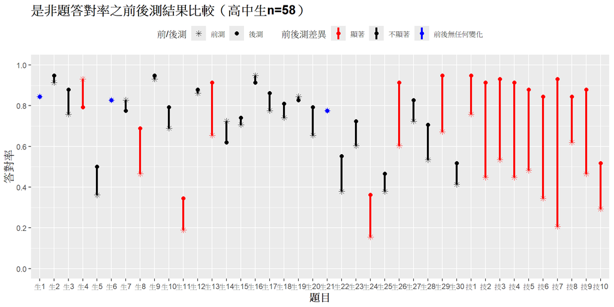

```r
yn.prepost.plot(Cdat1_yn.se, Cdat2_yn.se, "是非題答對率之前後測結果比較（高中生n=58）")
```

## **3-4 是非題前後測答對率（國中生n=88 vs. 高中生n=58）**

```r
kk<-yn.prepost.compare.table(Cdat1_yn.ju, Cdat2_yn.ju, Cdat1_yn.se, Cdat2_yn.se, state=1)

colnames(kk)<-c("","","平均答對率","標準差","平均答對率","標準差","t統計量","p-value","檢定結果")

kk[,8]<-str_c(kk[,8]%>%round(digits=3),cut(kk[,8], breaks=c(0,0.001,0.01,0.05,1),labels=c("***","**","*","")))

kk%>%kable("html",escape = F,booktabs = TRUE, digits=c(0,0,3,2,3,2,3,3,3),caption="1-4 是非題前後測答對率（國中生n=88 vs. 高中生n=58）")%>%
  kable_styling(c("striped", "bordered"))%>%
  add_header_above(c(" " = 2, "前測" = 2, "後測" = 2,"前後測成對t檢定" = 3))%>%
  column_spec(1, bold = T)%>%
  collapse_rows(columns = 1)%>%
  group_rows("生是非", 1, 60)%>%
  group_rows("技是非", 61, 80)
```

1-4 是非題前後測答對率（國中生n=88 vs. 高中生n=58）

|  |  | 前測 平均答對率 | 前測 標準差 | 後測 平均答對率 | 後測 標準差 | 前後測成對t檢定 t統計量 | 前後測成對t檢定 p-value | 前後測成對t檢定 檢定結果 |
| --- | --- | --- | --- | --- | --- | --- | --- | --- |
| **生是非** |  |  |  |  |  |  |  |  |
| 生是非1 | 國中 | 0.693 | 0.46 | 0.705 | 0.46 | 0.207 | 0.836 | Don’t Reject H0 |
|  | 高中 | 0.845 | 0.37 | 0.845 | 0.37 | 0.000 | 1 | No Change |
| 生是非2 | 國中 | 0.909 | 0.29 | 0.875 | 0.33 | -0.904 | 0.369 | Don’t Reject H0 |
|  | 高中 | 0.914 | 0.28 | 0.948 | 0.22 | 0.704 | 0.484 | Don’t Reject H0 |
| 生是非3 | 國中 | 0.773 | 0.42 | 0.795 | 0.41 | 0.445 | 0.657 | Don’t Reject H0 |
|  | 高中 | 0.759 | 0.43 | 0.879 | 0.33 | 1.726 | 0.09 | Don’t Reject H0 |
| 生是非4 | 國中 | 0.784 | 0.41 | 0.795 | 0.41 | 0.257 | 0.798 | Don’t Reject H0 |
|  | 高中 | 0.931 | 0.26 | 0.793 | 0.41 | -2.659 | 0.01* | Reject H0 |
| 生是非5 | 國中 | 0.420 | 0.50 | 0.489 | 0.50 | 1.179 | 0.241 | Don’t Reject H0 |
|  | 高中 | 0.362 | 0.48 | 0.500 | 0.50 | 1.929 | 0.059 | Don’t Reject H0 |
| 生是非6 | 國中 | 0.727 | 0.45 | 0.750 | 0.44 | 0.406 | 0.686 | Don’t Reject H0 |
|  | 高中 | 0.828 | 0.38 | 0.828 | 0.38 | 0.000 | 1 | No Change |
| 生是非7 | 國中 | 0.773 | 0.42 | 0.852 | 0.36 | 1.469 | 0.145 | Don’t Reject H0 |
|  | 高中 | 0.828 | 0.38 | 0.776 | 0.42 | -0.725 | 0.472 | Don’t Reject H0 |
| 生是非8 | 國中 | 0.443 | 0.50 | 0.636 | 0.48 | 3.101 | 0.003** | Reject H0 |
|  | 高中 | 0.466 | 0.50 | 0.690 | 0.47 | 3.030 | 0.004** | Reject H0 |
| 生是非9 | 國中 | 0.875 | 0.33 | 0.841 | 0.37 | -0.831 | 0.408 | Don’t Reject H0 |
|  | 高中 | 0.931 | 0.26 | 0.948 | 0.22 | 0.375 | 0.709 | Don’t Reject H0 |
| 生是非10 | 國中 | 0.614 | 0.49 | 0.693 | 0.46 | 1.186 | 0.239 | Don’t Reject H0 |
|  | 高中 | 0.690 | 0.47 | 0.793 | 0.41 | 1.351 | 0.182 | Don’t Reject H0 |
| 生是非11 | 國中 | 0.182 | 0.39 | 0.409 | 0.49 | 3.438 | 0.001*** | Reject H0 |
|  | 高中 | 0.190 | 0.40 | 0.345 | 0.48 | 2.127 | 0.038* | Reject H0 |
| 生是非12 | 國中 | 0.682 | 0.47 | 0.784 | 0.41 | 1.632 | 0.106 | Don’t Reject H0 |
|  | 高中 | 0.862 | 0.35 | 0.879 | 0.33 | 0.275 | 0.784 | Don’t Reject H0 |
| 生是非13 | 國中 | 0.580 | 0.50 | 0.795 | 0.41 | 3.294 | 0.001** | Reject H0 |
|  | 高中 | 0.655 | 0.48 | 0.914 | 0.28 | 3.401 | 0.001** | Reject H0 |
| 生是非14 | 國中 | 0.716 | 0.45 | 0.670 | 0.47 | -0.783 | 0.436 | Don’t Reject H0 |
|  | 高中 | 0.724 | 0.45 | 0.621 | 0.49 | -1.427 | 0.159 | Don’t Reject H0 |
| 生是非15 | 國中 | 0.670 | 0.47 | 0.716 | 0.45 | 1.000 | 0.32 | Don’t Reject H0 |

[output cut: 52 more lines]

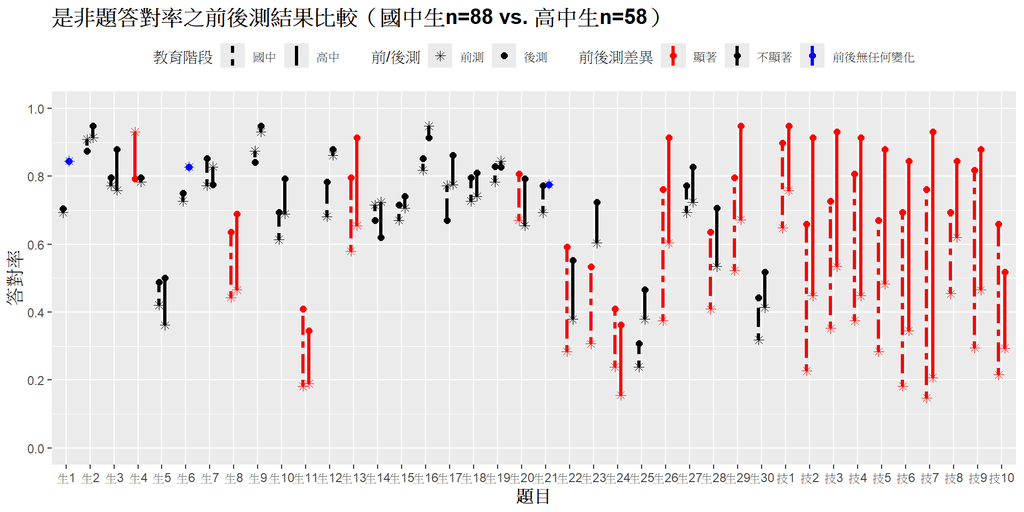

```r
res_ju<-yn.prepost.table(Cdat1_yn.ju, Cdat2_yn.ju)
res_se<-yn.prepost.table(Cdat1_yn.se, Cdat2_yn.se)
res1<-rbind(res_ju, res_se)

yn.prepost.compare.plot(res1, "是非題答對率之前後測結果比較（國中生n=88 vs. 高中生n=58）", state=1)
```

### **3-4-1 全部生是非、知識性質及覺察類是非題彙整表格（國中生n=88 vs. 高中生n=58）**

```r
kk<-mean_table_all2(Cdat1_yn.ju, Cdat2_yn.ju,
               Cdat1_yn.se, Cdat2_yn.se, state=1)

kk[[1]]%>%kableExtra::kable("html",escape = F,booktabs = TRUE,digits=c(0,0,3,2,3,2,3,3,3,3,3,3,3,3,3,3,3,3),caption="3-4-1 全部生是非、知識性質及覺察類是非題彙整表格（國中生n=88 vs. 高中生n=58）")%>%
  kable_styling(c("striped", "bordered"))%>%
  add_header_above(c(" " = 2, "前測" = 2, "後測" = 2,"前後測成對t檢定" = 3, "高中-國中獨立t檢定 (進步量)"=3, "高中-國中獨立t檢定 (前測)"=3, "高中-國中獨立t檢定 (後測)"=3))%>%
  column_spec(1, bold = T)%>%
  collapse_rows(columns = c(1,10:18))
```

3-4-1 全部生是非、知識性質及覺察類是非題彙整表格（國中生n=88 vs. 高中生n=58）

[output not shown]

### **3-4-2 全部生是非、知識性質及覺察類是非題盒形圖（國中生n=88 vs. 高中生n=58）**

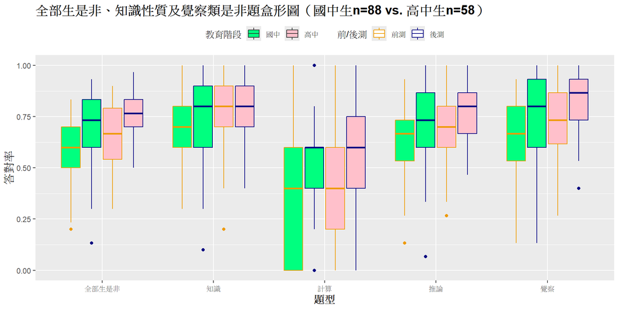

```r
yn.prepost.compare.boxplot(Cdat1_yn.ju, Cdat2_yn.ju,Cdat1_yn.se,Cdat2_yn.se,state=1,title="全部生是非、知識性質及覺察類是非題盒形圖（國中生n=88 vs. 高中生n=58）")
```

# **生是非各種分類的前後測分析**

# **4. 知識性質生是非前後測變化**

## **4-1-1 知識性質的表格彙整（全部人n=146）**

```r
mean_score.know<-mean_table.lifes(Cdat1_yn, Cdat2_yn, "知識性質")%>%as.data.frame()
rownames(mean_score.know)<-levels(typee$know)
colnames(mean_score.know)<-c("平均答對率","標準差","平均答對率","標準差","t統計量","p-value")

mean_score.know[,6]<-str_c(mean_score.know[,6]%>%as.numeric()%>%round(digits=3),cut(mean_score.know[,6]%>%as.numeric(), breaks=c(0,0.001,0.01,0.05,1),labels=c("***","**","*","")))

kable(mean_score.know,"html",escape = F,booktabs = TRUE, digits=c(3,3,2,2,3),caption="4-1-1 知識性質的表格彙整（全部人n=146）")%>%
  kable_styling(c("striped", "bordered"))%>%
  add_header_above(c(" " = 1, "前測" = 2, "後測" = 2, "前後測成對t檢定" = 2))%>%
  column_spec(1, bold = T)
```

4-1-1 知識性質的表格彙整（全部人n=146）

|  | 前測 平均答對率 | 前測 標準差 | 後測 平均答對率 | 後測 標準差 | 前後測成對t檢定 t統計量 | 前後測成對t檢定 p-value |
| --- | --- | --- | --- | --- | --- | --- |
| 知識 | 0.711 | 0.771 | 0.15 | 0.12 | 1.662 | 0.131 |
| 推論 | 0.645 | 0.736 | 0.21 | 0.13 | 4.068 | 0.001** |
| 計算 | 0.356 | 0.544 | 0.11 | 0.19 | 3.896 | 0.018* |

```r
#write.xlsx(mean_score.know,rowNames=T,"C:/Users/h2407/OneDrive/文件/1121/師培中心分析案/報表資料檔/不同知識性質生是非的整體平均（全部人n=146）.xlsx")
```

## **4-1-2 知識性質生是非（全部人n=146）**

```r
paste("樣本數 =",dim(Cdat1_yn)[1])
```

```
## [1] "樣本數 = 146"
```

```r
kk<-yn_life.prepost.table(Cdat1_yn, Cdat2_yn)
kk$題號<-typee$num
#rownames(kk)<-typee$num
kk<-kk%>%
  arrange(知識性質)%>%dplyr::select(!c("知識性質","生活主題","覺察"))
colnames(kk)<-c("","平均答對率","標準差","平均答對率","標準差","t統計量","p-value","檢定結果")
#rownames(kk)<-names(ans)[1:30]

kk[,7]<-str_c(kk[,7]%>%round(digits=3),cut(kk[,7], breaks=c(0,0.001,0.01,0.05,1),labels=c("***","**","*","")))

kk%>%kable("html",escape = F,row.names = FALSE,booktabs = TRUE, digits=c(0,3,2,3,2,3,3,3),caption="4-1-2 知識性質生是非（全部人n=146）")%>%
  kable_styling(c("striped", "bordered"))%>%
  add_header_above(c(" " = 1, "前測" = 2, "後測" = 2,"前後測成對t檢定" = 3))%>%
  column_spec(1, bold = T)%>%
  group_rows("知識", 1, 10)%>%
  group_rows("推論", 11, 25)%>%
  group_rows("計算", 26, 30)
```

4-1-2 知識性質生是非（全部人n=146）

|  | 前測 平均答對率 | 前測 標準差 | 後測 平均答對率 | 後測 標準差 | 前後測成對t檢定 t統計量 | 前後測成對t檢定 p-value | 前後測成對t檢定 檢定結果 |
| --- | --- | --- | --- | --- | --- | --- | --- |
| **知識** |  |  |  |  |  |  |  |
| 生是非1 | 0.753 | 0.43 | 0.760 | 0.43 | 0.173 | 0.863 | Don’t Reject H0 |
| 生是非2 | 0.911 | 0.29 | 0.904 | 0.30 | -0.229 | 0.819 | Don’t Reject H0 |
| 生是非4 | 0.842 | 0.37 | 0.795 | 0.41 | -1.405 | 0.162 | Don’t Reject H0 |
| 生是非5 | 0.397 | 0.49 | 0.493 | 0.50 | 2.136 | 0.034* | Reject H0 |
| 生是非6 | 0.767 | 0.42 | 0.781 | 0.42 | 0.342 | 0.733 | Don’t Reject H0 |
| 生是非7 | 0.795 | 0.41 | 0.822 | 0.38 | 0.631 | 0.529 | Don’t Reject H0 |
| 生是非13 | 0.610 | 0.49 | 0.842 | 0.37 | 4.695 | 0*** | Reject H0 |
| 生是非14 | 0.719 | 0.45 | 0.651 | 0.48 | -1.514 | 0.132 | Don’t Reject H0 |
| 生是非18 | 0.733 | 0.44 | 0.801 | 0.40 | 1.589 | 0.114 | Don’t Reject H0 |
| 生是非29 | 0.582 | 0.49 | 0.856 | 0.35 | 5.940 | 0*** | Reject H0 |
| **推論** |  |  |  |  |  |  |  |
| 生是非3 | 0.767 | 0.42 | 0.829 | 0.38 | 1.486 | 0.14 | Don’t Reject H0 |
| 生是非8 | 0.452 | 0.50 | 0.658 | 0.48 | 4.323 | 0*** | Reject H0 |
| 生是非9 | 0.897 | 0.30 | 0.884 | 0.32 | -0.446 | 0.656 | Don’t Reject H0 |
| 生是非10 | 0.644 | 0.48 | 0.733 | 0.44 | 1.766 | 0.08 | Don’t Reject H0 |
| 生是非11 | 0.185 | 0.39 | 0.384 | 0.49 | 4.037 | 0*** | Reject H0 |
| 生是非12 | 0.753 | 0.43 | 0.822 | 0.38 | 1.514 | 0.132 | Don’t Reject H0 |
| 生是非15 | 0.685 | 0.47 | 0.726 | 0.45 | 1.029 | 0.305 | Don’t Reject H0 |
| 生是非16 | 0.870 | 0.34 | 0.877 | 0.33 | 0.208 | 0.836 | Don’t Reject H0 |
| 生是非17 | 0.774 | 0.42 | 0.747 | 0.44 | -0.576 | 0.565 | Don’t Reject H0 |
| 生是非19 | 0.808 | 0.40 | 0.829 | 0.38 | 0.538 | 0.592 | Don’t Reject H0 |
| 生是非20 | 0.664 | 0.47 | 0.801 | 0.40 | 2.963 | 0.004** | Reject H0 |
| 生是非21 | 0.726 | 0.45 | 0.774 | 0.42 | 1.122 | 0.264 | Don’t Reject H0 |
| 生是非22 | 0.322 | 0.47 | 0.575 | 0.50 | 4.857 | 0*** | Reject H0 |
| 生是非23 | 0.425 | 0.50 | 0.610 | 0.49 | 4.152 | 0*** | Reject H0 |
| 生是非27 | 0.705 | 0.46 | 0.795 | 0.41 | 1.957 | 0.052 | Don’t Reject H0 |
| **計算** |  |  |  |  |  |  |  |
| 生是非24 | 0.205 | 0.41 | 0.390 | 0.49 | 3.661 | 0*** | Reject H0 |
| 生是非25 | 0.295 | 0.46 | 0.370 | 0.48 | 1.688 | 0.094 | Don’t Reject H0 |
| 生是非26 | 0.466 | 0.50 | 0.822 | 0.38 | 7.367 | 0*** | Reject H0 |
| 生是非28 | 0.459 | 0.50 | 0.664 | 0.47 | 3.685 | 0*** | Reject H0 |
| 生是非30 | 0.356 | 0.48 | 0.473 | 0.50 | 2.471 | 0.015* | Reject H0 |

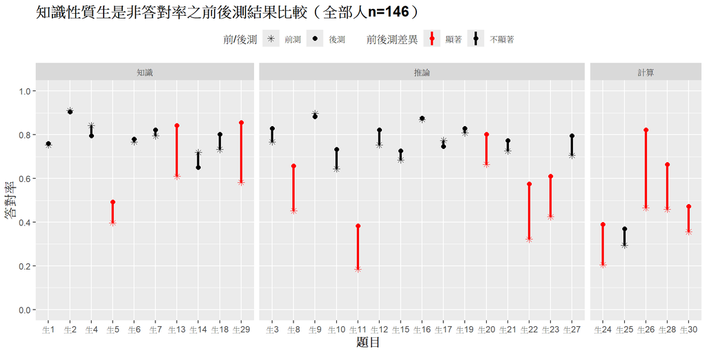

```r
yn_life.prepost.plot.know(Cdat1_yn, Cdat2_yn, "知識性質生是非答對率之前後測結果比較（全部人n=146）")
```

### **4-2-1 知識性質生是非（國中生n=88）**

```r
paste("樣本數 =",dim(Cdat1_yn.ju)[1])
```

```
## [1] "樣本數 = 88"
```

```r
kk<-yn_life.prepost.table(Cdat1_yn.ju, Cdat2_yn.ju)
kk$題號<-typee$num
kk<-kk%>%
  arrange(知識性質)%>%dplyr::select(!c("知識性質","生活主題","覺察"))
colnames(kk)<-c("","平均答對率","標準差","平均答對率","標準差","t統計量","p-value","檢定結果")
#rownames(kk)<-names(ans)[1:30]

kk[,7]<-str_c(kk[,7]%>%round(digits=3),cut(kk[,7], breaks=c(0,0.001,0.01,0.05,1),labels=c("***","**","*","")))

kk%>%kable("html",escape = F,row.names = FALSE,booktabs = TRUE, digits=c(0,3,2,3,2,3,3,3),caption="4-2-1 知識性質生是非（國中生n=88）")%>%
  kable_styling(c("striped", "bordered"))%>%
  add_header_above(c(" " = 1, "前測" = 2, "後測" = 2,"前後測成對t檢定" = 3))%>%
  column_spec(1, bold = T)%>%
  group_rows("知識", 1, 10)%>%
  group_rows("推論", 11, 25)%>%
  group_rows("計算", 26, 30)
```

4-2-1 知識性質生是非（國中生n=88）

|  | 前測 平均答對率 | 前測 標準差 | 後測 平均答對率 | 後測 標準差 | 前後測成對t檢定 t統計量 | 前後測成對t檢定 p-value | 前後測成對t檢定 檢定結果 |
| --- | --- | --- | --- | --- | --- | --- | --- |
| **知識** |  |  |  |  |  |  |  |
| 生是非1 | 0.693 | 0.46 | 0.705 | 0.46 | 0.207 | 0.836 | Don’t Reject H0 |
| 生是非2 | 0.909 | 0.29 | 0.875 | 0.33 | -0.904 | 0.369 | Don’t Reject H0 |
| 生是非4 | 0.784 | 0.41 | 0.795 | 0.41 | 0.257 | 0.798 | Don’t Reject H0 |
| 生是非5 | 0.420 | 0.50 | 0.489 | 0.50 | 1.179 | 0.241 | Don’t Reject H0 |
| 生是非6 | 0.727 | 0.45 | 0.750 | 0.44 | 0.406 | 0.686 | Don’t Reject H0 |
| 生是非7 | 0.773 | 0.42 | 0.852 | 0.36 | 1.469 | 0.145 | Don’t Reject H0 |
| 生是非13 | 0.580 | 0.50 | 0.795 | 0.41 | 3.294 | 0.001** | Reject H0 |
| 生是非14 | 0.716 | 0.45 | 0.670 | 0.47 | -0.783 | 0.436 | Don’t Reject H0 |
| 生是非18 | 0.727 | 0.45 | 0.795 | 0.41 | 1.284 | 0.203 | Don’t Reject H0 |
| 生是非29 | 0.523 | 0.50 | 0.795 | 0.41 | 4.397 | 0*** | Reject H0 |
| **推論** |  |  |  |  |  |  |  |
| 生是非3 | 0.773 | 0.42 | 0.795 | 0.41 | 0.445 | 0.657 | Don’t Reject H0 |
| 生是非8 | 0.443 | 0.50 | 0.636 | 0.48 | 3.101 | 0.003** | Reject H0 |
| 生是非9 | 0.875 | 0.33 | 0.841 | 0.37 | -0.831 | 0.408 | Don’t Reject H0 |
| 生是非10 | 0.614 | 0.49 | 0.693 | 0.46 | 1.186 | 0.239 | Don’t Reject H0 |
| 生是非11 | 0.182 | 0.39 | 0.409 | 0.49 | 3.438 | 0.001*** | Reject H0 |
| 生是非12 | 0.682 | 0.47 | 0.784 | 0.41 | 1.632 | 0.106 | Don’t Reject H0 |
| 生是非15 | 0.670 | 0.47 | 0.716 | 0.45 | 1.000 | 0.32 | Don’t Reject H0 |
| 生是非16 | 0.818 | 0.39 | 0.852 | 0.36 | 0.773 | 0.442 | Don’t Reject H0 |
| 生是非17 | 0.773 | 0.42 | 0.670 | 0.47 | -1.580 | 0.118 | Don’t Reject H0 |
| 生是非19 | 0.784 | 0.41 | 0.830 | 0.38 | 0.893 | 0.374 | Don’t Reject H0 |
| 生是非20 | 0.670 | 0.47 | 0.807 | 0.40 | 2.240 | 0.028* | Reject H0 |
| 生是非21 | 0.693 | 0.46 | 0.773 | 0.42 | 1.354 | 0.179 | Don’t Reject H0 |
| 生是非22 | 0.284 | 0.45 | 0.591 | 0.49 | 4.844 | 0*** | Reject H0 |
| 生是非23 | 0.307 | 0.46 | 0.534 | 0.50 | 3.795 | 0*** | Reject H0 |
| 生是非27 | 0.693 | 0.46 | 0.773 | 0.42 | 1.354 | 0.179 | Don’t Reject H0 |
| **計算** |  |  |  |  |  |  |  |
| 生是非24 | 0.239 | 0.43 | 0.409 | 0.49 | 2.541 | 0.013* | Reject H0 |
| 生是非25 | 0.239 | 0.43 | 0.307 | 0.46 | 1.284 | 0.203 | Don’t Reject H0 |
| 生是非26 | 0.375 | 0.49 | 0.761 | 0.43 | 6.085 | 0*** | Reject H0 |
| 生是非28 | 0.409 | 0.49 | 0.636 | 0.48 | 3.340 | 0.001** | Reject H0 |
| 生是非30 | 0.318 | 0.47 | 0.443 | 0.50 | 1.945 | 0.055 | Don’t Reject H0 |

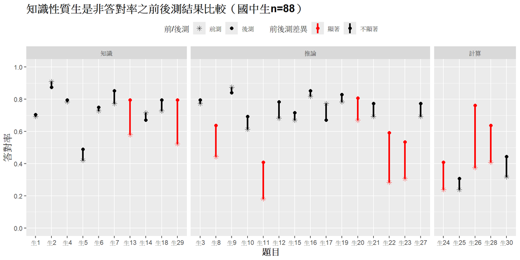

```r
yn_life.prepost.plot.know(Cdat1_yn.ju, Cdat2_yn.ju, "知識性質生是非答對率之前後測結果比較（國中生n=88）")
```

### **4-2-2 知識性質生是非（高中生n=58）**

```r
paste("樣本數 =",dim(Cdat1_yn.se)[1])
```

```
## [1] "樣本數 = 58"
```

```r
kk<-yn_life.prepost.table(Cdat1_yn.se, Cdat2_yn.se)
kk$題號<-typee$num
kk<-kk%>%
  arrange(知識性質)%>%dplyr::select(!c("知識性質","生活主題","覺察"))
colnames(kk)<-c("","平均答對率","標準差","平均答對率","標準差","t統計量","p-value","檢定結果")
#rownames(kk)<-names(ans)[1:30]

kk[,7]<-str_c(kk[,7]%>%round(digits=3),cut(kk[,7], breaks=c(0,0.001,0.01,0.05,1),labels=c("***","**","*","")))

kk%>%kable("html",row.names = FALSE,escape = F,booktabs = TRUE, digits=c(0,3,2,3,2,3,3,3),caption="4-2-2 知識性質生是非（高中生n=58）")%>%
  kable_styling(c("striped", "bordered"))%>%
  add_header_above(c(" " = 1, "前測" = 2, "後測" = 2,"前後測成對t檢定" = 3))%>%
  column_spec(1, bold = T)%>%
  group_rows("知識", 1, 10)%>%
  group_rows("推論", 11, 25)%>%
  group_rows("計算", 26, 30)
```

4-2-2 知識性質生是非（高中生n=58）

|  | 前測 平均答對率 | 前測 標準差 | 後測 平均答對率 | 後測 標準差 | 前後測成對t檢定 t統計量 | 前後測成對t檢定 p-value | 前後測成對t檢定 檢定結果 |
| --- | --- | --- | --- | --- | --- | --- | --- |
| **知識** |  |  |  |  |  |  |  |
| 生是非1 | 0.845 | 0.37 | 0.845 | 0.37 | 0.000 | 1 | No Change |
| 生是非2 | 0.914 | 0.28 | 0.948 | 0.22 | 0.704 | 0.484 | Don’t Reject H0 |
| 生是非4 | 0.931 | 0.26 | 0.793 | 0.41 | -2.659 | 0.01* | Reject H0 |
| 生是非5 | 0.362 | 0.48 | 0.500 | 0.50 | 1.929 | 0.059 | Don’t Reject H0 |
| 生是非6 | 0.828 | 0.38 | 0.828 | 0.38 | 0.000 | 1 | No Change |
| 生是非7 | 0.828 | 0.38 | 0.776 | 0.42 | -0.725 | 0.472 | Don’t Reject H0 |
| 生是非13 | 0.655 | 0.48 | 0.914 | 0.28 | 3.401 | 0.001** | Reject H0 |
| 生是非14 | 0.724 | 0.45 | 0.621 | 0.49 | -1.427 | 0.159 | Don’t Reject H0 |
| 生是非18 | 0.741 | 0.44 | 0.810 | 0.40 | 0.942 | 0.35 | Don’t Reject H0 |
| 生是非29 | 0.672 | 0.47 | 0.948 | 0.22 | 4.018 | 0*** | Reject H0 |
| **推論** |  |  |  |  |  |  |  |
| 生是非3 | 0.759 | 0.43 | 0.879 | 0.33 | 1.726 | 0.09 | Don’t Reject H0 |
| 生是非8 | 0.466 | 0.50 | 0.690 | 0.47 | 3.030 | 0.004** | Reject H0 |
| 生是非9 | 0.931 | 0.26 | 0.948 | 0.22 | 0.375 | 0.709 | Don’t Reject H0 |
| 生是非10 | 0.690 | 0.47 | 0.793 | 0.41 | 1.351 | 0.182 | Don’t Reject H0 |
| 生是非11 | 0.190 | 0.40 | 0.345 | 0.48 | 2.127 | 0.038* | Reject H0 |
| 生是非12 | 0.862 | 0.35 | 0.879 | 0.33 | 0.275 | 0.784 | Don’t Reject H0 |
| 生是非15 | 0.707 | 0.46 | 0.741 | 0.44 | 0.468 | 0.641 | Don’t Reject H0 |
| 生是非16 | 0.948 | 0.22 | 0.914 | 0.28 | -0.704 | 0.484 | Don’t Reject H0 |
| 生是非17 | 0.776 | 0.42 | 0.862 | 0.35 | 1.299 | 0.199 | Don’t Reject H0 |
| 生是非19 | 0.845 | 0.37 | 0.828 | 0.38 | -0.299 | 0.766 | Don’t Reject H0 |
| 生是非20 | 0.655 | 0.48 | 0.793 | 0.41 | 1.929 | 0.059 | Don’t Reject H0 |
| 生是非21 | 0.776 | 0.42 | 0.776 | 0.42 | 0.000 | 1 | No Change |
| 生是非22 | 0.379 | 0.49 | 0.552 | 0.50 | 1.934 | 0.058 | Don’t Reject H0 |
| 生是非23 | 0.603 | 0.49 | 0.724 | 0.45 | 1.844 | 0.07 | Don’t Reject H0 |
| 生是非27 | 0.724 | 0.45 | 0.828 | 0.38 | 1.427 | 0.159 | Don’t Reject H0 |
| **計算** |  |  |  |  |  |  |  |
| 生是非24 | 0.155 | 0.37 | 0.362 | 0.48 | 2.693 | 0.009** | Reject H0 |
| 生是非25 | 0.379 | 0.49 | 0.466 | 0.50 | 1.093 | 0.279 | Don’t Reject H0 |
| 生是非26 | 0.603 | 0.49 | 0.914 | 0.28 | 4.158 | 0*** | Reject H0 |
| 生是非28 | 0.534 | 0.50 | 0.707 | 0.46 | 1.802 | 0.077 | Don’t Reject H0 |
| 生是非30 | 0.414 | 0.50 | 0.517 | 0.50 | 1.517 | 0.135 | Don’t Reject H0 |

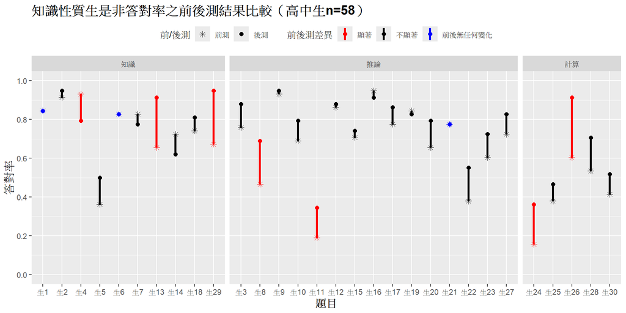

```r
yn_life.prepost.plot.know(Cdat1_yn.se, Cdat2_yn.se, "知識性質生是非答對率之前後測結果比較（高中生n=58）")
```

## **4-3-1 知識性質的表格彙整（國中生n=88 vs. 高中生n=58）**

```r
mean_score.know1<-mean_table.lifes(Cdat1_yn.ju, Cdat2_yn.ju, "知識性質")%>%as.data.frame()
mean_score.know2<-mean_table.lifes(Cdat1_yn.se, Cdat2_yn.se, "知識性質")%>%as.data.frame()
mean_score.know.juse<-cbind(mean_score.know1, mean_score.know2)
rownames(mean_score.know.juse)<-levels(typee$know)
colnames(mean_score.know.juse)<-rep(c("平均答對率","標準差","平均答對率","標準差","t統計量","p-value"),2)

mean_score.know.juse[,6]<-str_c(mean_score.know.juse[,6]%>%as.numeric()%>%round(digits=3),cut(mean_score.know.juse[,6]%>%as.numeric(), breaks=c(0,0.001,0.01,0.05,1),labels=c("***","**","*","")))

mean_score.know.juse[,12]<-str_c(mean_score.know.juse[,12]%>%as.numeric()%>%round(digits=3),cut(mean_score.know.juse[,12]%>%as.numeric(), breaks=c(0,0.001,0.01,0.05,1),labels=c("***","**","*","")))


mean_score.know.juse%>%kable("html",escape = F,booktabs = TRUE, digits=c(3,2,3,2,3,3,3),caption="4-3-1 知識性質的表格彙整（國中生n=88 vs. 高中生n=58）")%>%
  kable_styling(c("striped", "bordered"))%>%
  add_header_above(c(" " = 1, "前測" = 2, "後測" = 2,"前後測成對t檢定" = 2, "前測" = 2, "後測" = 2,"前後測成對t檢定" = 2))%>%
  add_header_above(c(" " = 1, "國中生 (n=73)" = 6, "高中生 (n=34)" = 6))%>%
  column_spec(1, bold = T)
```

4-3-1 知識性質的表格彙整（國中生n=88 vs. 高中生n=58）

[output not shown]

```r
#write.xlsx(mean_score.know.juse,rowNames=T,"C:/Users/h2407/OneDrive/文件/1121/師培中心分析案/報表資料檔/不同知識性質生是非的整體平均（國中生n=88 vs. 高中生n=58）.xlsx")
```

## **4-3-2 知識性質生是非（國中生n=88 vs. 高中生n=58）**

```r
kk<-yn_life.prepost.compare.table(Cdat1_yn.ju, Cdat2_yn.ju, Cdat1_yn.se, Cdat2_yn.se, 1)%>%arrange(知識性質)%>%dplyr::select(!c("知識性質","生活主題","覺察"))

colnames(kk)<-c("","","平均答對率","標準差","平均答對率","標準差","t統計量","p-value","檢定結果")

kk[,8]<-str_c(kk[,8]%>%round(digits=3),cut(kk[,8], breaks=c(0,0.001,0.01,0.05,1),labels=c("***","**","*","")))

kk%>%kable("html",escape = F,booktabs = TRUE, digits=c(0,0,3,2,3,2,3,3,3), caption="4-3-2 知識性質生是非（國中生n=88 vs. 高中生n=58）")%>%
  kable_styling(c("striped", "bordered"))%>%
  add_header_above(c(" " = 2, "前測" = 2, "後測" = 2,"前後測成對t檢定" = 3))%>%
  column_spec(1, bold = T)%>%
  collapse_rows(columns = 1)%>%
  group_rows("知識", 1, 20)%>%
  group_rows("推論", 21, 50)%>%
  group_rows("計算", 51, 60)
```

4-3-2 知識性質生是非（國中生n=88 vs. 高中生n=58）

|  |  | 前測 平均答對率 | 前測 標準差 | 後測 平均答對率 | 後測 標準差 | 前後測成對t檢定 t統計量 | 前後測成對t檢定 p-value | 前後測成對t檢定 檢定結果 |
| --- | --- | --- | --- | --- | --- | --- | --- | --- |
| **知識** |  |  |  |  |  |  |  |  |
| 生是非1 | 國中 | 0.693 | 0.46 | 0.705 | 0.46 | 0.207 | 0.836 | Don’t Reject H0 |
|  | 高中 | 0.845 | 0.37 | 0.845 | 0.37 | 0.000 | 1 | No Change |
| 生是非2 | 國中 | 0.909 | 0.29 | 0.875 | 0.33 | -0.904 | 0.369 | Don’t Reject H0 |
|  | 高中 | 0.914 | 0.28 | 0.948 | 0.22 | 0.704 | 0.484 | Don’t Reject H0 |
| 生是非4 | 國中 | 0.784 | 0.41 | 0.795 | 0.41 | 0.257 | 0.798 | Don’t Reject H0 |
|  | 高中 | 0.931 | 0.26 | 0.793 | 0.41 | -2.659 | 0.01* | Reject H0 |
| 生是非5 | 國中 | 0.420 | 0.50 | 0.489 | 0.50 | 1.179 | 0.241 | Don’t Reject H0 |
|  | 高中 | 0.362 | 0.48 | 0.500 | 0.50 | 1.929 | 0.059 | Don’t Reject H0 |
| 生是非6 | 國中 | 0.727 | 0.45 | 0.750 | 0.44 | 0.406 | 0.686 | Don’t Reject H0 |
|  | 高中 | 0.828 | 0.38 | 0.828 | 0.38 | 0.000 | 1 | No Change |
| 生是非7 | 國中 | 0.773 | 0.42 | 0.852 | 0.36 | 1.469 | 0.145 | Don’t Reject H0 |
|  | 高中 | 0.828 | 0.38 | 0.776 | 0.42 | -0.725 | 0.472 | Don’t Reject H0 |
| 生是非13 | 國中 | 0.580 | 0.50 | 0.795 | 0.41 | 3.294 | 0.001** | Reject H0 |
|  | 高中 | 0.655 | 0.48 | 0.914 | 0.28 | 3.401 | 0.001** | Reject H0 |
| 生是非14 | 國中 | 0.716 | 0.45 | 0.670 | 0.47 | -0.783 | 0.436 | Don’t Reject H0 |
|  | 高中 | 0.724 | 0.45 | 0.621 | 0.49 | -1.427 | 0.159 | Don’t Reject H0 |
| 生是非18 | 國中 | 0.727 | 0.45 | 0.795 | 0.41 | 1.284 | 0.203 | Don’t Reject H0 |
|  | 高中 | 0.741 | 0.44 | 0.810 | 0.40 | 0.942 | 0.35 | Don’t Reject H0 |
| 生是非29 | 國中 | 0.523 | 0.50 | 0.795 | 0.41 | 4.397 | 0*** | Reject H0 |
|  | 高中 | 0.672 | 0.47 | 0.948 | 0.22 | 4.018 | 0*** | Reject H0 |
| **推論** |  |  |  |  |  |  |  |  |
| 生是非3 | 國中 | 0.773 | 0.42 | 0.795 | 0.41 | 0.445 | 0.657 | Don’t Reject H0 |
|  | 高中 | 0.759 | 0.43 | 0.879 | 0.33 | 1.726 | 0.09 | Don’t Reject H0 |
| 生是非8 | 國中 | 0.443 | 0.50 | 0.636 | 0.48 | 3.101 | 0.003** | Reject H0 |
|  | 高中 | 0.466 | 0.50 | 0.690 | 0.47 | 3.030 | 0.004** | Reject H0 |
| 生是非9 | 國中 | 0.875 | 0.33 | 0.841 | 0.37 | -0.831 | 0.408 | Don’t Reject H0 |
|  | 高中 | 0.931 | 0.26 | 0.948 | 0.22 | 0.375 | 0.709 | Don’t Reject H0 |
| 生是非10 | 國中 | 0.614 | 0.49 | 0.693 | 0.46 | 1.186 | 0.239 | Don’t Reject H0 |
|  | 高中 | 0.690 | 0.47 | 0.793 | 0.41 | 1.351 | 0.182 | Don’t Reject H0 |
| 生是非11 | 國中 | 0.182 | 0.39 | 0.409 | 0.49 | 3.438 | 0.001*** | Reject H0 |
|  | 高中 | 0.190 | 0.40 | 0.345 | 0.48 | 2.127 | 0.038* | Reject H0 |
| 生是非12 | 國中 | 0.682 | 0.47 | 0.784 | 0.41 | 1.632 | 0.106 | Don’t Reject H0 |
|  | 高中 | 0.862 | 0.35 | 0.879 | 0.33 | 0.275 | 0.784 | Don’t Reject H0 |
| 生是非15 | 國中 | 0.670 | 0.47 | 0.716 | 0.45 | 1.000 | 0.32 | Don’t Reject H0 |
|  | 高中 | 0.707 | 0.46 | 0.741 | 0.44 | 0.468 | 0.641 | Don’t Reject H0 |
| 生是非16 | 國中 | 0.818 | 0.39 | 0.852 | 0.36 | 0.773 | 0.442 | Don’t Reject H0 |
|  | 高中 | 0.948 | 0.22 | 0.914 | 0.28 | -0.704 | 0.484 | Don’t Reject H0 |
| 生是非17 | 國中 | 0.773 | 0.42 | 0.670 | 0.47 | -1.580 | 0.118 | Don’t Reject H0 |
|  | 高中 | 0.776 | 0.42 | 0.862 | 0.35 | 1.299 | 0.199 | Don’t Reject H0 |
| 生是非19 | 國中 | 0.784 | 0.41 | 0.830 | 0.38 | 0.893 | 0.374 | Don’t Reject H0 |
|  | 高中 | 0.845 | 0.37 | 0.828 | 0.38 | -0.299 | 0.766 | Don’t Reject H0 |
| 生是非20 | 國中 | 0.670 | 0.47 | 0.807 | 0.40 | 2.240 | 0.028* | Reject H0 |
|  | 高中 | 0.655 | 0.48 | 0.793 | 0.41 | 1.929 | 0.059 | Don’t Reject H0 |
| 生是非21 | 國中 | 0.693 | 0.46 | 0.773 | 0.42 | 1.354 | 0.179 | Don’t Reject H0 |
|  | 高中 | 0.776 | 0.42 | 0.776 | 0.42 | 0.000 | 1 | No Change |
| 生是非22 | 國中 | 0.284 | 0.45 | 0.591 | 0.49 | 4.844 | 0*** | Reject H0 |
|  | 高中 | 0.379 | 0.49 | 0.552 | 0.50 | 1.934 | 0.058 | Don’t Reject H0 |
| 生是非23 | 國中 | 0.307 | 0.46 | 0.534 | 0.50 | 3.795 | 0*** | Reject H0 |
|  | 高中 | 0.603 | 0.49 | 0.724 | 0.45 | 1.844 | 0.07 | Don’t Reject H0 |
| 生是非27 | 國中 | 0.693 | 0.46 | 0.773 | 0.42 | 1.354 | 0.179 | Don’t Reject H0 |
|  | 高中 | 0.724 | 0.45 | 0.828 | 0.38 | 1.427 | 0.159 | Don’t Reject H0 |
| **計算** |  |  |  |  |  |  |  |  |
| 生是非24 | 國中 | 0.239 | 0.43 | 0.409 | 0.49 | 2.541 | 0.013* | Reject H0 |
|  | 高中 | 0.155 | 0.37 | 0.362 | 0.48 | 2.693 | 0.009** | Reject H0 |
| 生是非25 | 國中 | 0.239 | 0.43 | 0.307 | 0.46 | 1.284 | 0.203 | Don’t Reject H0 |
|  | 高中 | 0.379 | 0.49 | 0.466 | 0.50 | 1.093 | 0.279 | Don’t Reject H0 |
| 生是非26 | 國中 | 0.375 | 0.49 | 0.761 | 0.43 | 6.085 | 0*** | Reject H0 |
|  | 高中 | 0.603 | 0.49 | 0.914 | 0.28 | 4.158 | 0*** | Reject H0 |
| 生是非28 | 國中 | 0.409 | 0.49 | 0.636 | 0.48 | 3.340 | 0.001** | Reject H0 |
|  | 高中 | 0.534 | 0.50 | 0.707 | 0.46 | 1.802 | 0.077 | Don’t Reject H0 |
| 生是非30 | 國中 | 0.318 | 0.47 | 0.443 | 0.50 | 1.945 | 0.055 | Don’t Reject H0 |
|  | 高中 | 0.414 | 0.50 | 0.517 | 0.50 | 1.517 | 0.135 | Don’t Reject H0 |

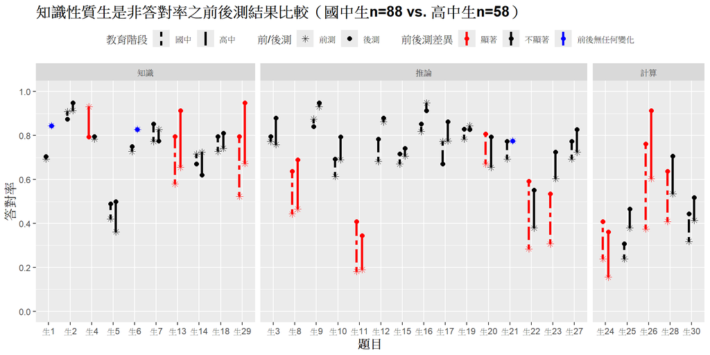

```r
res_ju<-yn_life.prepost.table(Cdat1_yn.ju, Cdat2_yn.ju)
res_se<-yn_life.prepost.table(Cdat1_yn.se, Cdat2_yn.se)
res11<-rbind(res_ju, res_se)

yn.prepost.compare.plot(res11, "知識性質生是非答對率之前後測結果比較（國中生n=88 vs. 高中生n=58）", state=1)+
  facet_grid(cols=vars(知識性質), scales = "free", space = "free")
```

# **5. 生活主題生是非前後測變化**

## **5-1-1 生活主題的表格彙整（全部人n=146）**

```r
mean_score.life<-mean_table.lifes(Cdat1_yn, Cdat2_yn, "生活主題")%>%as.data.frame()
rownames(mean_score.life)<-levels(typee$life)
colnames(mean_score.life)<-c("平均答對率","標準差","平均答對率","標準差","t統計量","p-value")

mean_score.life[,6]<-str_c(mean_score.life[,6]%>%as.numeric()%>%round(digits=3),cut(mean_score.life[,6]%>%as.numeric(), breaks=c(0,0.001,0.01,0.05,1),labels=c("***","**","*","")))

kable(mean_score.life,"html",escape = F,booktabs = TRUE, digits=c(3,2,3,2,3,3,3),caption="5-1-1 生活主題的表格彙整（全部人n=146）")%>%
  kable_styling(c("striped", "bordered"))%>%
  add_header_above(c(" " = 1, "前測" = 2, "後測" = 2,"前後測成對t檢定" = 2))%>%
  column_spec(1, bold = T)
```

5-1-1 生活主題的表格彙整（全部人n=146）

|  | 前測 平均答對率 | 前測 標準差 | 後測 平均答對率 | 後測 標準差 | 前後測成對t檢定 t統計量 | 前後測成對t檢定 p-value |
| --- | --- | --- | --- | --- | --- | --- |
| 01營養素 | 0.678 | 0.71 | 0.322 | 0.22 | 0.664 | 0.554 |
| 02細胞 | 0.565 | 0.68 | 0.171 | 0.14 | 3.565 | 0.038* |
| 03食物 | 0.586 | 0.70 | 0.183 | 0.15 | 5.225 | 0.006** |
| 04飲食習慣 | 0.799 | 0.80 | 0.086 | 0.07 | 0.349 | 0.745 |
| 05運動 | 0.750 | 0.81 | 0.063 | 0.02 | NA | NA |
| 06肥胖 | 0.315 | 0.53 | 0.142 | 0.26 | 2.585 | 0.123 |
| 07糖尿病 | 0.607 | 0.72 | 0.185 | 0.11 | 2.125 | 0.087 |
| 08量測 | 0.582 | 0.86 | NA | NA | NA | NA |

```r
#write.xlsx(mean_score.life,rowNames=T,"C:/Users/h2407/OneDrive/文件/1121/師培中心分析案/報表資料檔/不同生活主題生是非的整體平均（全部人n=146）.xlsx")
```

## **5-1-2 生活主題生是非（全部人n=146）**

```r
paste("樣本數 =",dim(Cdat1_yn)[1])
```

```
## [1] "樣本數 = 146"
```

```r
kk<-yn_life.prepost.table(Cdat1_yn, Cdat2_yn)
kk$題號<-typee$num
kk1<-kk%>%
  arrange(生活主題)%>%dplyr::select(!c("知識性質","生活主題","覺察"))
#kk1<-kk%>%dplyr::select(!c("知識性質","生活主題","覺察"))
colnames(kk1)<-c("","平均答對率","標準差","平均答對率","標準差","t統計量","p-value","檢定結果")
#rownames(kk1)<-names(ans)[1:30]

kk1[,7]<-str_c(kk1[,7]%>%round(digits=3),cut(kk1[,7], breaks=c(0,0.001,0.01,0.05,1),labels=c("***","**","*","")))

kk1%>%kable("html",escape = F,row.names = FALSE,booktabs = TRUE, digits=c(0,3,2,3,2,3,3,3), caption="5-1-2 生活主題生是非（全部人n=146）")%>%
  kable_styling(c("striped", "bordered"))%>%
  add_header_above(c(" " = 1, "前測" = 2, "後測" = 2,"前後測成對t檢定" = 3))%>%
  column_spec(1, bold = T)%>%
  group_rows(levels(kk$生活主題)[1], 1, cumsum(table(kk$生活主題))[[1]])%>%
  group_rows(levels(kk$生活主題)[2], cumsum(table(kk$生活主題))[[1]]+1, cumsum(table(kk$生活主題))[[2]])%>%
  group_rows(levels(kk$生活主題)[3], cumsum(table(kk$生活主題))[[2]]+1, cumsum(table(kk$生活主題))[[3]])%>%
  group_rows(levels(kk$生活主題)[4], cumsum(table(kk$生活主題))[[3]]+1, cumsum(table(kk$生活主題))[[4]])%>%
  group_rows(levels(kk$生活主題)[5], cumsum(table(kk$生活主題))[[4]]+1, cumsum(table(kk$生活主題))[[5]])%>%
  group_rows(levels(kk$生活主題)[6], cumsum(table(kk$生活主題))[[5]]+1, cumsum(table(kk$生活主題))[[6]])%>%
  group_rows(levels(kk$生活主題)[7], cumsum(table(kk$生活主題))[[6]]+1, cumsum(table(kk$生活主題))[[7]])%>%
  group_rows(levels(kk$生活主題)[8], cumsum(table(kk$生活主題))[[7]]+1, cumsum(table(kk$生活主題))[[8]])
```

5-1-2 生活主題生是非（全部人n=146）

|  | 前測 平均答對率 | 前測 標準差 | 後測 平均答對率 | 後測 標準差 | 前後測成對t檢定 t統計量 | 前後測成對t檢定 p-value | 前後測成對t檢定 檢定結果 |
| --- | --- | --- | --- | --- | --- | --- | --- |
| **01營養素** |  |  |  |  |  |  |  |
| 生是非1 | 0.753 | 0.43 | 0.760 | 0.43 | 0.173 | 0.863 | Don’t Reject H0 |
| 生是非2 | 0.911 | 0.29 | 0.904 | 0.30 | -0.229 | 0.819 | Don’t Reject H0 |
| 生是非4 | 0.842 | 0.37 | 0.795 | 0.41 | -1.405 | 0.162 | Don’t Reject H0 |
| 生是非24 | 0.205 | 0.41 | 0.390 | 0.49 | 3.661 | 0*** | Reject H0 |
| **02細胞** |  |  |  |  |  |  |  |
| 生是非3 | 0.767 | 0.42 | 0.829 | 0.38 | 1.486 | 0.14 | Don’t Reject H0 |
| 生是非5 | 0.397 | 0.49 | 0.493 | 0.50 | 2.136 | 0.034* | Reject H0 |
| 生是非8 | 0.452 | 0.50 | 0.658 | 0.48 | 4.323 | 0*** | Reject H0 |
| 生是非10 | 0.644 | 0.48 | 0.733 | 0.44 | 1.766 | 0.08 | Don’t Reject H0 |
| **03食物** |  |  |  |  |  |  |  |
| 生是非12 | 0.753 | 0.43 | 0.822 | 0.38 | 1.514 | 0.132 | Don’t Reject H0 |
| 生是非18 | 0.733 | 0.44 | 0.801 | 0.40 | 1.589 | 0.114 | Don’t Reject H0 |
| 生是非20 | 0.664 | 0.47 | 0.801 | 0.40 | 2.963 | 0.004** | Reject H0 |
| 生是非23 | 0.425 | 0.50 | 0.610 | 0.49 | 4.152 | 0*** | Reject H0 |
| 生是非30 | 0.356 | 0.48 | 0.473 | 0.50 | 2.471 | 0.015* | Reject H0 |
| **04飲食習慣** |  |  |  |  |  |  |  |
| 生是非6 | 0.767 | 0.42 | 0.781 | 0.42 | 0.342 | 0.733 | Don’t Reject H0 |
| 生是非9 | 0.897 | 0.30 | 0.884 | 0.32 | -0.446 | 0.656 | Don’t Reject H0 |
| 生是非15 | 0.685 | 0.47 | 0.726 | 0.45 | 1.029 | 0.305 | Don’t Reject H0 |
| 生是非16 | 0.870 | 0.34 | 0.877 | 0.33 | 0.208 | 0.836 | Don’t Reject H0 |
| 生是非17 | 0.774 | 0.42 | 0.747 | 0.44 | -0.576 | 0.565 | Don’t Reject H0 |
| **05運動** |  |  |  |  |  |  |  |
| 生是非7 | 0.795 | 0.41 | 0.822 | 0.38 | 0.631 | 0.529 | Don’t Reject H0 |
| 生是非27 | 0.705 | 0.46 | 0.795 | 0.41 | 1.957 | 0.052 | Don’t Reject H0 |
| **06肥胖** |  |  |  |  |  |  |  |
| 生是非11 | 0.185 | 0.39 | 0.384 | 0.49 | 4.037 | 0*** | Reject H0 |
| 生是非25 | 0.295 | 0.46 | 0.370 | 0.48 | 1.688 | 0.094 | Don’t Reject H0 |
| 生是非26 | 0.466 | 0.50 | 0.822 | 0.38 | 7.367 | 0*** | Reject H0 |
| **07糖尿病** |  |  |  |  |  |  |  |
| 生是非13 | 0.610 | 0.49 | 0.842 | 0.37 | 4.695 | 0*** | Reject H0 |
| 生是非14 | 0.719 | 0.45 | 0.651 | 0.48 | -1.514 | 0.132 | Don’t Reject H0 |
| 生是非19 | 0.808 | 0.40 | 0.829 | 0.38 | 0.538 | 0.592 | Don’t Reject H0 |
| 生是非21 | 0.726 | 0.45 | 0.774 | 0.42 | 1.122 | 0.264 | Don’t Reject H0 |
| 生是非22 | 0.322 | 0.47 | 0.575 | 0.50 | 4.857 | 0*** | Reject H0 |
| 生是非28 | 0.459 | 0.50 | 0.664 | 0.47 | 3.685 | 0*** | Reject H0 |
| **08量測** |  |  |  |  |  |  |  |
| 生是非29 | 0.582 | 0.49 | 0.856 | 0.35 | 5.940 | 0*** | Reject H0 |

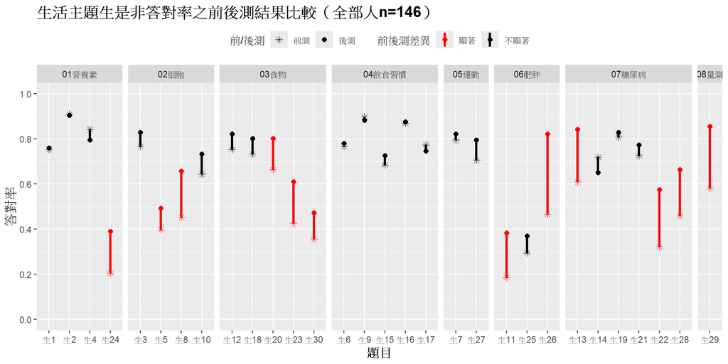

```r
yn_life.prepost.plot.life(Cdat1_yn, Cdat2_yn, "生活主題生是非答對率之前後測結果比較（全部人n=146）")
```

### **5-2-1 生活主題生是非（國中生n=88）**

```r
paste("樣本數 =",dim(Cdat1_yn.ju)[1])
```

```
## [1] "樣本數 = 88"
```

```r
kk<-yn_life.prepost.table(Cdat1_yn.ju, Cdat2_yn.ju)
kk$題號<-typee$num
kk1<-kk%>%
  arrange(生活主題)%>%dplyr::select(!c("知識性質","生活主題","覺察"))
colnames(kk1)<-c("","平均答對率","標準差","平均答對率","標準差","t統計量","p-value","檢定結果")
#rownames(kk1)<-names(ans)[1:30]

kk1[,7]<-str_c(kk1[,7]%>%round(digits=3),cut(kk1[,7], breaks=c(0,0.001,0.01,0.05,1),labels=c("***","**","*","")))

kk1%>%kable("html",escape = F,row.names = FALSE,booktabs = TRUE, digits=c(0,3,2,3,2,3,3,3), caption="5-2-1 生活主題生是非（國中生n=88）")%>%
  kable_styling(c("striped", "bordered"))%>%
  add_header_above(c(" " = 1, "前測" = 2, "後測" = 2,"前後測成對t檢定" = 3))%>%
  column_spec(1, bold = T)%>%
  group_rows(levels(kk$生活主題)[1], 1, cumsum(table(kk$生活主題))[[1]])%>%
  group_rows(levels(kk$生活主題)[2], cumsum(table(kk$生活主題))[[1]]+1, cumsum(table(kk$生活主題))[[2]])%>%
  group_rows(levels(kk$生活主題)[3], cumsum(table(kk$生活主題))[[2]]+1, cumsum(table(kk$生活主題))[[3]])%>%
  group_rows(levels(kk$生活主題)[4], cumsum(table(kk$生活主題))[[3]]+1, cumsum(table(kk$生活主題))[[4]])%>%
  group_rows(levels(kk$生活主題)[5], cumsum(table(kk$生活主題))[[4]]+1, cumsum(table(kk$生活主題))[[5]])%>%
  group_rows(levels(kk$生活主題)[6], cumsum(table(kk$生活主題))[[5]]+1, cumsum(table(kk$生活主題))[[6]])%>%
  group_rows(levels(kk$生活主題)[7], cumsum(table(kk$生活主題))[[6]]+1, cumsum(table(kk$生活主題))[[7]])%>%
  group_rows(levels(kk$生活主題)[8], cumsum(table(kk$生活主題))[[7]]+1, cumsum(table(kk$生活主題))[[8]])
```

5-2-1 生活主題生是非（國中生n=88）

|  | 前測 平均答對率 | 前測 標準差 | 後測 平均答對率 | 後測 標準差 | 前後測成對t檢定 t統計量 | 前後測成對t檢定 p-value | 前後測成對t檢定 檢定結果 |
| --- | --- | --- | --- | --- | --- | --- | --- |
| **01營養素** |  |  |  |  |  |  |  |
| 生是非1 | 0.693 | 0.46 | 0.705 | 0.46 | 0.207 | 0.836 | Don’t Reject H0 |
| 生是非2 | 0.909 | 0.29 | 0.875 | 0.33 | -0.904 | 0.369 | Don’t Reject H0 |
| 生是非4 | 0.784 | 0.41 | 0.795 | 0.41 | 0.257 | 0.798 | Don’t Reject H0 |
| 生是非24 | 0.239 | 0.43 | 0.409 | 0.49 | 2.541 | 0.013* | Reject H0 |
| **02細胞** |  |  |  |  |  |  |  |
| 生是非3 | 0.773 | 0.42 | 0.795 | 0.41 | 0.445 | 0.657 | Don’t Reject H0 |
| 生是非5 | 0.420 | 0.50 | 0.489 | 0.50 | 1.179 | 0.241 | Don’t Reject H0 |
| 生是非8 | 0.443 | 0.50 | 0.636 | 0.48 | 3.101 | 0.003** | Reject H0 |
| 生是非10 | 0.614 | 0.49 | 0.693 | 0.46 | 1.186 | 0.239 | Don’t Reject H0 |
| **03食物** |  |  |  |  |  |  |  |
| 生是非12 | 0.682 | 0.47 | 0.784 | 0.41 | 1.632 | 0.106 | Don’t Reject H0 |
| 生是非18 | 0.727 | 0.45 | 0.795 | 0.41 | 1.284 | 0.203 | Don’t Reject H0 |
| 生是非20 | 0.670 | 0.47 | 0.807 | 0.40 | 2.240 | 0.028* | Reject H0 |
| 生是非23 | 0.307 | 0.46 | 0.534 | 0.50 | 3.795 | 0*** | Reject H0 |
| 生是非30 | 0.318 | 0.47 | 0.443 | 0.50 | 1.945 | 0.055 | Don’t Reject H0 |
| **04飲食習慣** |  |  |  |  |  |  |  |
| 生是非6 | 0.727 | 0.45 | 0.750 | 0.44 | 0.406 | 0.686 | Don’t Reject H0 |
| 生是非9 | 0.875 | 0.33 | 0.841 | 0.37 | -0.831 | 0.408 | Don’t Reject H0 |
| 生是非15 | 0.670 | 0.47 | 0.716 | 0.45 | 1.000 | 0.32 | Don’t Reject H0 |
| 生是非16 | 0.818 | 0.39 | 0.852 | 0.36 | 0.773 | 0.442 | Don’t Reject H0 |
| 生是非17 | 0.773 | 0.42 | 0.670 | 0.47 | -1.580 | 0.118 | Don’t Reject H0 |
| **05運動** |  |  |  |  |  |  |  |
| 生是非7 | 0.773 | 0.42 | 0.852 | 0.36 | 1.469 | 0.145 | Don’t Reject H0 |
| 生是非27 | 0.693 | 0.46 | 0.773 | 0.42 | 1.354 | 0.179 | Don’t Reject H0 |
| **06肥胖** |  |  |  |  |  |  |  |
| 生是非11 | 0.182 | 0.39 | 0.409 | 0.49 | 3.438 | 0.001*** | Reject H0 |
| 生是非25 | 0.239 | 0.43 | 0.307 | 0.46 | 1.284 | 0.203 | Don’t Reject H0 |
| 生是非26 | 0.375 | 0.49 | 0.761 | 0.43 | 6.085 | 0*** | Reject H0 |
| **07糖尿病** |  |  |  |  |  |  |  |
| 生是非13 | 0.580 | 0.50 | 0.795 | 0.41 | 3.294 | 0.001** | Reject H0 |
| 生是非14 | 0.716 | 0.45 | 0.670 | 0.47 | -0.783 | 0.436 | Don’t Reject H0 |
| 生是非19 | 0.784 | 0.41 | 0.830 | 0.38 | 0.893 | 0.374 | Don’t Reject H0 |
| 生是非21 | 0.693 | 0.46 | 0.773 | 0.42 | 1.354 | 0.179 | Don’t Reject H0 |
| 生是非22 | 0.284 | 0.45 | 0.591 | 0.49 | 4.844 | 0*** | Reject H0 |
| 生是非28 | 0.409 | 0.49 | 0.636 | 0.48 | 3.340 | 0.001** | Reject H0 |
| **08量測** |  |  |  |  |  |  |  |
| 生是非29 | 0.523 | 0.50 | 0.795 | 0.41 | 4.397 | 0*** | Reject H0 |

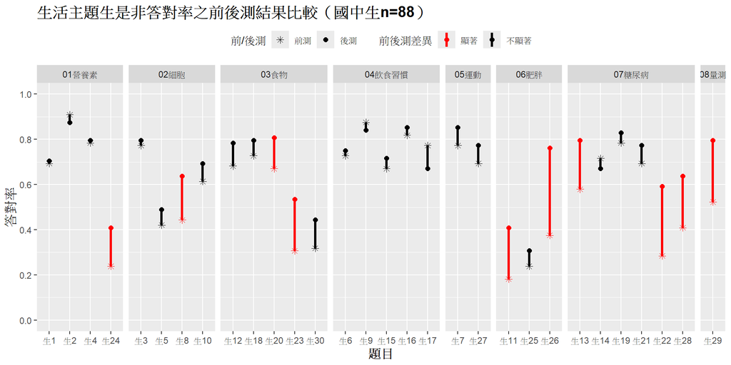

```r
yn_life.prepost.plot.life(Cdat1_yn.ju, Cdat2_yn.ju, "生活主題生是非答對率之前後測結果比較（國中生n=88）")
```

### **5-2-2 生活主題生是非（高中生n=58）**

```r
paste("樣本數 =",dim(Cdat1_yn.se)[1])
```

```
## [1] "樣本數 = 58"
```

```r
kk<-yn_life.prepost.table(Cdat1_yn.se, Cdat2_yn.se)
kk$題號<-typee$num
kk1<-kk%>%
  arrange(生活主題)%>%dplyr::select(!c("知識性質","生活主題","覺察"))
colnames(kk1)<-c("","平均答對率","標準差","平均答對率","標準差","t統計量","p-value","檢定結果")
#rownames(kk1)<-names(ans)[1:30]

kk1[,7]<-str_c(kk1[,7]%>%round(digits=3),cut(kk1[,7], breaks=c(0,0.001,0.01,0.05,1),labels=c("***","**","*","")))

kk1%>%kable("html",escape = F,row.names = FALSE,booktabs = TRUE, digits=c(3,2,3,2,3,3,3), caption="5-2-2 生活主題生是非（高中生n=58）")%>%
  kable_styling(c("striped", "bordered"))%>%
  add_header_above(c(" " = 1, "前測" = 2, "後測" = 2,"前後測成對t檢定" = 3))%>%
  column_spec(1, bold = T)%>%
  group_rows(levels(kk$生活主題)[1], 1, cumsum(table(kk$生活主題))[[1]])%>%
  group_rows(levels(kk$生活主題)[2], cumsum(table(kk$生活主題))[[1]]+1, cumsum(table(kk$生活主題))[[2]])%>%
  group_rows(levels(kk$生活主題)[3], cumsum(table(kk$生活主題))[[2]]+1, cumsum(table(kk$生活主題))[[3]])%>%
  group_rows(levels(kk$生活主題)[4], cumsum(table(kk$生活主題))[[3]]+1, cumsum(table(kk$生活主題))[[4]])%>%
  group_rows(levels(kk$生活主題)[5], cumsum(table(kk$生活主題))[[4]]+1, cumsum(table(kk$生活主題))[[5]])%>%
  group_rows(levels(kk$生活主題)[6], cumsum(table(kk$生活主題))[[5]]+1, cumsum(table(kk$生活主題))[[6]])%>%
  group_rows(levels(kk$生活主題)[7], cumsum(table(kk$生活主題))[[6]]+1, cumsum(table(kk$生活主題))[[7]])%>%
  group_rows(levels(kk$生活主題)[8], cumsum(table(kk$生活主題))[[7]]+1, cumsum(table(kk$生活主題))[[8]])
```

5-2-2 生活主題生是非（高中生n=58）

|  | 前測 平均答對率 | 前測 標準差 | 後測 平均答對率 | 後測 標準差 | 前後測成對t檢定 t統計量 | 前後測成對t檢定 p-value | 前後測成對t檢定 檢定結果 |
| --- | --- | --- | --- | --- | --- | --- | --- |
| **01營養素** |  |  |  |  |  |  |  |
| 生是非1 | 0.84 | 0.365 | 0.84 | 0.365 | 0.000 | 1 | No Change |
| 生是非2 | 0.91 | 0.283 | 0.95 | 0.223 | 0.704 | 0.484 | Don’t Reject H0 |
| 生是非4 | 0.93 | 0.256 | 0.79 | 0.409 | -2.659 | 0.01* | Reject H0 |
| 生是非24 | 0.16 | 0.365 | 0.36 | 0.485 | 2.693 | 0.009** | Reject H0 |
| **02細胞** |  |  |  |  |  |  |  |
| 生是非3 | 0.76 | 0.432 | 0.88 | 0.329 | 1.726 | 0.09 | Don’t Reject H0 |
| 生是非5 | 0.36 | 0.485 | 0.50 | 0.504 | 1.929 | 0.059 | Don’t Reject H0 |
| 生是非8 | 0.47 | 0.503 | 0.69 | 0.467 | 3.030 | 0.004** | Reject H0 |
| 生是非10 | 0.69 | 0.467 | 0.79 | 0.409 | 1.351 | 0.182 | Don’t Reject H0 |
| **03食物** |  |  |  |  |  |  |  |
| 生是非12 | 0.86 | 0.348 | 0.88 | 0.329 | 0.275 | 0.784 | Don’t Reject H0 |
| 生是非18 | 0.74 | 0.442 | 0.81 | 0.395 | 0.942 | 0.35 | Don’t Reject H0 |
| 生是非20 | 0.66 | 0.479 | 0.79 | 0.409 | 1.929 | 0.059 | Don’t Reject H0 |
| 生是非23 | 0.60 | 0.493 | 0.72 | 0.451 | 1.844 | 0.07 | Don’t Reject H0 |
| 生是非30 | 0.41 | 0.497 | 0.52 | 0.504 | 1.517 | 0.135 | Don’t Reject H0 |
| **04飲食習慣** |  |  |  |  |  |  |  |
| 生是非6 | 0.83 | 0.381 | 0.83 | 0.381 | 0.000 | 1 | No Change |
| 生是非9 | 0.93 | 0.256 | 0.95 | 0.223 | 0.375 | 0.709 | Don’t Reject H0 |
| 生是非15 | 0.71 | 0.459 | 0.74 | 0.442 | 0.468 | 0.641 | Don’t Reject H0 |
| 生是非16 | 0.95 | 0.223 | 0.91 | 0.283 | -0.704 | 0.484 | Don’t Reject H0 |
| 生是非17 | 0.78 | 0.421 | 0.86 | 0.348 | 1.299 | 0.199 | Don’t Reject H0 |
| **05運動** |  |  |  |  |  |  |  |
| 生是非7 | 0.83 | 0.381 | 0.78 | 0.421 | -0.725 | 0.472 | Don’t Reject H0 |
| 生是非27 | 0.72 | 0.451 | 0.83 | 0.381 | 1.427 | 0.159 | Don’t Reject H0 |
| **06肥胖** |  |  |  |  |  |  |  |
| 生是非11 | 0.19 | 0.395 | 0.34 | 0.479 | 2.127 | 0.038* | Reject H0 |
| 生是非25 | 0.38 | 0.489 | 0.47 | 0.503 | 1.093 | 0.279 | Don’t Reject H0 |
| 生是非26 | 0.60 | 0.493 | 0.91 | 0.283 | 4.158 | 0*** | Reject H0 |
| **07糖尿病** |  |  |  |  |  |  |  |
| 生是非13 | 0.66 | 0.479 | 0.91 | 0.283 | 3.401 | 0.001** | Reject H0 |
| 生是非14 | 0.72 | 0.451 | 0.62 | 0.489 | -1.427 | 0.159 | Don’t Reject H0 |
| 生是非19 | 0.84 | 0.365 | 0.83 | 0.381 | -0.299 | 0.766 | Don’t Reject H0 |
| 生是非21 | 0.78 | 0.421 | 0.78 | 0.421 | 0.000 | 1 | No Change |
| 生是非22 | 0.38 | 0.489 | 0.55 | 0.502 | 1.934 | 0.058 | Don’t Reject H0 |
| 生是非28 | 0.53 | 0.503 | 0.71 | 0.459 | 1.802 | 0.077 | Don’t Reject H0 |
| **08量測** |  |  |  |  |  |  |  |
| 生是非29 | 0.67 | 0.473 | 0.95 | 0.223 | 4.018 | 0*** | Reject H0 |

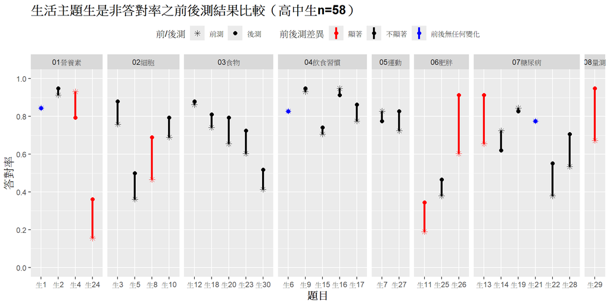

```r
yn_life.prepost.plot.life(Cdat1_yn.se, Cdat2_yn.se, "生活主題生是非答對率之前後測結果比較（高中生n=58）")
```

## **5-3-1 生活主題的表格彙整（國中生n=88 vs. 高中生n=58）**

```r
mean_score.life1<-mean_table.lifes(Cdat1_yn.ju, Cdat2_yn.ju, "生活主題")%>%as.data.frame()
mean_score.life2<-mean_table.lifes(Cdat1_yn.se, Cdat2_yn.se, "生活主題")%>%as.data.frame()

#mean_score.life2[,1:5]<-apply(mean_score.life2[,-6],2,as.numeric)

#mean_score.life2[2,5:6]<-NA

mean_score.life.juse<-cbind(mean_score.life1, mean_score.life2)
rownames(mean_score.life.juse)<-levels(typee$life)
colnames(mean_score.life.juse)<-rep(c("平均答對率","標準差","平均答對率","標準差","t統計量","p-value"),2)

mean_score.life.juse[,6]<-str_c(mean_score.life.juse[,6]%>%as.numeric()%>%round(digits=3),cut(mean_score.life.juse[,6]%>%as.numeric(), breaks=c(0,0.001,0.01,0.05,1),labels=c("***","**","*","")))

mean_score.life.juse[,12]<-str_c(mean_score.life.juse[,12]%>%as.numeric()%>%round(digits=3),cut(mean_score.life.juse[,12]%>%as.numeric(), breaks=c(0,0.001,0.01,0.05,1),labels=c("***","**","*","")))

mean_score.life.juse%>%kable("html",escape = F,booktabs = TRUE, digits=c(3,2,3,2,3,3,3))%>%
  kable_styling(c("striped", "bordered"))%>%
  add_header_above(c(" " = 1, "前測" = 2, "後測" = 2,"前後測成對t檢定" = 2, "前測" = 2, "後測" = 2,"前後測成對t檢定" = 2))%>%
  add_header_above(c(" " = 1, "國中生 (n=73)" = 6, "高中生 (n=34)" = 6))%>%
  column_spec(1, bold = T)
```

[output not shown]

```r
#write.xlsx(mean_score.life.juse,rowNames=T,"C:/Users/h2407/OneDrive/文件/1121/師培中心分析案/報表資料檔/不同生活主題生是非的整體平均（國中生n=88 vs. 高中生n=58）.xlsx")
```

## **5-3-2 生活主題生是非（國中生n=88 vs. 高中生n=58）**

```r
kk<-yn_life.prepost.compare.table(Cdat1_yn.ju, Cdat2_yn.ju, Cdat1_yn.se, Cdat2_yn.se, 1)%>%arrange(生活主題)
kk1<-kk%>%dplyr::select(!c("知識性質","生活主題","覺察"))
colnames(kk1)<-c("","","平均答對率","標準差","平均答對率","標準差","t統計量","p-value","檢定結果")

kk1[,8]<-str_c(kk1[,8]%>%round(digits=3),cut(kk1[,8], breaks=c(0,0.001,0.01,0.05,1),labels=c("***","**","*","")))

kk1%>%kable("html",escape = F,booktabs = TRUE, digits=c(0,0,3,2,3,2,3,3,3), caption="5-3-2 生活主題生是非（國中生n=88 vs. 高中生n=58）")%>%
  kable_styling(c("striped", "bordered"))%>%
  add_header_above(c(" " = 2, "前測" = 2, "後測" = 2,"前後測成對t檢定" = 3))%>%
  column_spec(1, bold = T)%>%
  collapse_rows(columns = 1)%>%
  group_rows(levels(kk$生活主題)[1], 1, cumsum(table(kk$生活主題))[[1]])%>%
  group_rows(levels(kk$生活主題)[2], cumsum(table(kk$生活主題))[[1]]+1, cumsum(table(kk$生活主題))[[2]])%>%
  group_rows(levels(kk$生活主題)[3], cumsum(table(kk$生活主題))[[2]]+1, cumsum(table(kk$生活主題))[[3]])%>%
  group_rows(levels(kk$生活主題)[4], cumsum(table(kk$生活主題))[[3]]+1, cumsum(table(kk$生活主題))[[4]])%>%
  group_rows(levels(kk$生活主題)[5], cumsum(table(kk$生活主題))[[4]]+1, cumsum(table(kk$生活主題))[[5]])%>%
  group_rows(levels(kk$生活主題)[6], cumsum(table(kk$生活主題))[[5]]+1, cumsum(table(kk$生活主題))[[6]])%>%
  group_rows(levels(kk$生活主題)[7], cumsum(table(kk$生活主題))[[6]]+1, cumsum(table(kk$生活主題))[[7]])%>%
  group_rows(levels(kk$生活主題)[8], cumsum(table(kk$生活主題))[[7]]+1, cumsum(table(kk$生活主題))[[8]])
```

5-3-2 生活主題生是非（國中生n=88 vs. 高中生n=58）

|  |  | 前測 平均答對率 | 前測 標準差 | 後測 平均答對率 | 後測 標準差 | 前後測成對t檢定 t統計量 | 前後測成對t檢定 p-value | 前後測成對t檢定 檢定結果 |
| --- | --- | --- | --- | --- | --- | --- | --- | --- |
| **01營養素** |  |  |  |  |  |  |  |  |
| 生是非1 | 國中 | 0.693 | 0.46 | 0.705 | 0.46 | 0.207 | 0.836 | Don’t Reject H0 |
|  | 高中 | 0.845 | 0.37 | 0.845 | 0.37 | 0.000 | 1 | No Change |
| 生是非2 | 國中 | 0.909 | 0.29 | 0.875 | 0.33 | -0.904 | 0.369 | Don’t Reject H0 |
|  | 高中 | 0.914 | 0.28 | 0.948 | 0.22 | 0.704 | 0.484 | Don’t Reject H0 |
| 生是非4 | 國中 | 0.784 | 0.41 | 0.795 | 0.41 | 0.257 | 0.798 | Don’t Reject H0 |
|  | 高中 | 0.931 | 0.26 | 0.793 | 0.41 | -2.659 | 0.01* | Reject H0 |
| 生是非24 | 國中 | 0.239 | 0.43 | 0.409 | 0.49 | 2.541 | 0.013* | Reject H0 |
|  | 高中 | 0.155 | 0.37 | 0.362 | 0.48 | 2.693 | 0.009** | Reject H0 |
| **02細胞** |  |  |  |  |  |  |  |  |
| 生是非3 | 國中 | 0.773 | 0.42 | 0.795 | 0.41 | 0.445 | 0.657 | Don’t Reject H0 |
|  | 高中 | 0.759 | 0.43 | 0.879 | 0.33 | 1.726 | 0.09 | Don’t Reject H0 |
| 生是非5 | 國中 | 0.420 | 0.50 | 0.489 | 0.50 | 1.179 | 0.241 | Don’t Reject H0 |
|  | 高中 | 0.362 | 0.48 | 0.500 | 0.50 | 1.929 | 0.059 | Don’t Reject H0 |
| 生是非8 | 國中 | 0.443 | 0.50 | 0.636 | 0.48 | 3.101 | 0.003** | Reject H0 |
|  | 高中 | 0.466 | 0.50 | 0.690 | 0.47 | 3.030 | 0.004** | Reject H0 |
| 生是非10 | 國中 | 0.614 | 0.49 | 0.693 | 0.46 | 1.186 | 0.239 | Don’t Reject H0 |
|  | 高中 | 0.690 | 0.47 | 0.793 | 0.41 | 1.351 | 0.182 | Don’t Reject H0 |
| **03食物** |  |  |  |  |  |  |  |  |
| 生是非12 | 國中 | 0.682 | 0.47 | 0.784 | 0.41 | 1.632 | 0.106 | Don’t Reject H0 |
|  | 高中 | 0.862 | 0.35 | 0.879 | 0.33 | 0.275 | 0.784 | Don’t Reject H0 |
| 生是非18 | 國中 | 0.727 | 0.45 | 0.795 | 0.41 | 1.284 | 0.203 | Don’t Reject H0 |
|  | 高中 | 0.741 | 0.44 | 0.810 | 0.40 | 0.942 | 0.35 | Don’t Reject H0 |
| 生是非20 | 國中 | 0.670 | 0.47 | 0.807 | 0.40 | 2.240 | 0.028* | Reject H0 |
|  | 高中 | 0.655 | 0.48 | 0.793 | 0.41 | 1.929 | 0.059 | Don’t Reject H0 |
| 生是非23 | 國中 | 0.307 | 0.46 | 0.534 | 0.50 | 3.795 | 0*** | Reject H0 |
|  | 高中 | 0.603 | 0.49 | 0.724 | 0.45 | 1.844 | 0.07 | Don’t Reject H0 |
| 生是非30 | 國中 | 0.318 | 0.47 | 0.443 | 0.50 | 1.945 | 0.055 | Don’t Reject H0 |
|  | 高中 | 0.414 | 0.50 | 0.517 | 0.50 | 1.517 | 0.135 | Don’t Reject H0 |
| **04飲食習慣** |  |  |  |  |  |  |  |  |
| 生是非6 | 國中 | 0.727 | 0.45 | 0.750 | 0.44 | 0.406 | 0.686 | Don’t Reject H0 |
|  | 高中 | 0.828 | 0.38 | 0.828 | 0.38 | 0.000 | 1 | No Change |
| 生是非9 | 國中 | 0.875 | 0.33 | 0.841 | 0.37 | -0.831 | 0.408 | Don’t Reject H0 |
|  | 高中 | 0.931 | 0.26 | 0.948 | 0.22 | 0.375 | 0.709 | Don’t Reject H0 |
| 生是非15 | 國中 | 0.670 | 0.47 | 0.716 | 0.45 | 1.000 | 0.32 | Don’t Reject H0 |
|  | 高中 | 0.707 | 0.46 | 0.741 | 0.44 | 0.468 | 0.641 | Don’t Reject H0 |
| 生是非16 | 國中 | 0.818 | 0.39 | 0.852 | 0.36 | 0.773 | 0.442 | Don’t Reject H0 |
|  | 高中 | 0.948 | 0.22 | 0.914 | 0.28 | -0.704 | 0.484 | Don’t Reject H0 |
| 生是非17 | 國中 | 0.773 | 0.42 | 0.670 | 0.47 | -1.580 | 0.118 | Don’t Reject H0 |
|  | 高中 | 0.776 | 0.42 | 0.862 | 0.35 | 1.299 | 0.199 | Don’t Reject H0 |
| **05運動** |  |  |  |  |  |  |  |  |
| 生是非7 | 國中 | 0.773 | 0.42 | 0.852 | 0.36 | 1.469 | 0.145 | Don’t Reject H0 |
|  | 高中 | 0.828 | 0.38 | 0.776 | 0.42 | -0.725 | 0.472 | Don’t Reject H0 |
| 生是非27 | 國中 | 0.693 | 0.46 | 0.773 | 0.42 | 1.354 | 0.179 | Don’t Reject H0 |
|  | 高中 | 0.724 | 0.45 | 0.828 | 0.38 | 1.427 | 0.159 | Don’t Reject H0 |
| **06肥胖** |  |  |  |  |  |  |  |  |
| 生是非11 | 國中 | 0.182 | 0.39 | 0.409 | 0.49 | 3.438 | 0.001*** | Reject H0 |
|  | 高中 | 0.190 | 0.40 | 0.345 | 0.48 | 2.127 | 0.038* | Reject H0 |
| 生是非25 | 國中 | 0.239 | 0.43 | 0.307 | 0.46 | 1.284 | 0.203 | Don’t Reject H0 |
|  | 高中 | 0.379 | 0.49 | 0.466 | 0.50 | 1.093 | 0.279 | Don’t Reject H0 |
| 生是非26 | 國中 | 0.375 | 0.49 | 0.761 | 0.43 | 6.085 | 0*** | Reject H0 |
|  | 高中 | 0.603 | 0.49 | 0.914 | 0.28 | 4.158 | 0*** | Reject H0 |
| **07糖尿病** |  |  |  |  |  |  |  |  |
| 生是非13 | 國中 | 0.580 | 0.50 | 0.795 | 0.41 | 3.294 | 0.001** | Reject H0 |
|  | 高中 | 0.655 | 0.48 | 0.914 | 0.28 | 3.401 | 0.001** | Reject H0 |
| 生是非14 | 國中 | 0.716 | 0.45 | 0.670 | 0.47 | -0.783 | 0.436 | Don’t Reject H0 |
|  | 高中 | 0.724 | 0.45 | 0.621 | 0.49 | -1.427 | 0.159 | Don’t Reject H0 |
| 生是非19 | 國中 | 0.784 | 0.41 | 0.830 | 0.38 | 0.893 | 0.374 | Don’t Reject H0 |
|  | 高中 | 0.845 | 0.37 | 0.828 | 0.38 | -0.299 | 0.766 | Don’t Reject H0 |
| 生是非21 | 國中 | 0.693 | 0.46 | 0.773 | 0.42 | 1.354 | 0.179 | Don’t Reject H0 |
|  | 高中 | 0.776 | 0.42 | 0.776 | 0.42 | 0.000 | 1 | No Change |
| 生是非22 | 國中 | 0.284 | 0.45 | 0.591 | 0.49 | 4.844 | 0*** | Reject H0 |
|  | 高中 | 0.379 | 0.49 | 0.552 | 0.50 | 1.934 | 0.058 | Don’t Reject H0 |
| 生是非28 | 國中 | 0.409 | 0.49 | 0.636 | 0.48 | 3.340 | 0.001** | Reject H0 |
|  | 高中 | 0.534 | 0.50 | 0.707 | 0.46 | 1.802 | 0.077 | Don’t Reject H0 |
| **08量測** |  |  |  |  |  |  |  |  |
| 生是非29 | 國中 | 0.523 | 0.50 | 0.795 | 0.41 | 4.397 | 0*** | Reject H0 |
|  | 高中 | 0.672 | 0.47 | 0.948 | 0.22 | 4.018 | 0*** | Reject H0 |

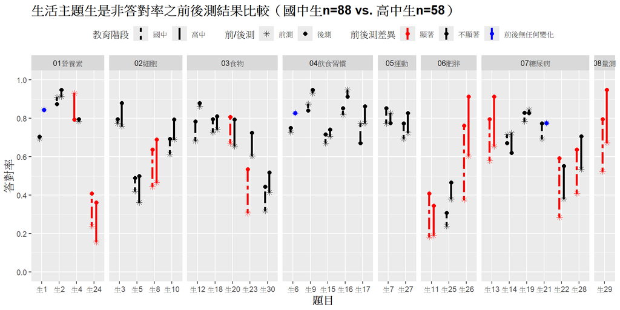

```r
yn.prepost.compare.plot(res11, "生活主題生是非答對率之前後測結果比較（國中生n=88 vs. 高中生n=58）", state=1)+
  facet_grid(cols=vars(生活主題), scales = "free", space = "free")
```

# **6. 覺察類生是非前後測變化**

## **6-1-1 覺察類的表格彙整（全部人n=146）**

```r
mean_score.sense<-mean_table.lifes(Cdat1_yn, Cdat2_yn, "覺察")%>%as.data.frame()
rownames(mean_score.sense)<-"覺察"
colnames(mean_score.sense)<-c("平均答對率","標準差","平均答對率","標準差","t統計量","p-value")

mean_score.sense[,6]<-str_c(mean_score.sense[,6]%>%as.numeric()%>%round(digits=3),cut(mean_score.sense[,6]%>%as.numeric(), breaks=c(0,0.001,0.01,0.05,1),labels=c("***","**","*","")))

mean_score.sense%>%kable("html",escape = F,booktabs = TRUE, digits=c(3,2,3,2,3,3,3),caption="6-1-1 覺察類的表格彙整（全部人n=146）")%>%
  kable_styling(c("striped", "bordered"))%>%
  add_header_above(c(" " = 1, "前測" = 2, "後測" = 2,"前後測成對t檢定" = 2))%>%
  column_spec(1, bold = T)
```

6-1-1 覺察類的表格彙整（全部人n=146）

|  | 前測 平均答對率 | 前測 標準差 | 後測 平均答對率 | 後測 標準差 | 前後測成對t檢定 t統計量 | 前後測成對t檢定 p-value |
| --- | --- | --- | --- | --- | --- | --- |
| 覺察 | 0.684 | 0.77 | 0.196 | 0.13 | 3.219 | 0.006** |

```r
#write.xlsx(mean_score.sense,rowNames=T,"C:/Users/h2407/OneDrive/文件/1121/師培中心分析案/報表資料檔/覺察類生是非的整體平均（全部人n=146）.xlsx")
```

## **6-1-2 覺察類生是非（全部人n=146）**

```r
paste("樣本數 =",dim(Cdat1_yn)[1])
```

```
## [1] "樣本數 = 146"
```

```r
kk<-yn_life.prepost.table(Cdat1_yn, Cdat2_yn)[,-1]%>%filter(覺察==1)%>%dplyr::select(!c("知識性質","生活主題","覺察"))
colnames(kk)<-c("平均答對率","標準差","平均答對率","標準差","t統計量","p-value","檢定結果")

kk[,6]<-str_c(kk[,6]%>%round(digits=3),cut(kk[,6], breaks=c(0,0.001,0.01,0.05,1),labels=c("***","**","*","")))

kk%>%kable("html",escape = F,booktabs = TRUE, digits=c(3,2,3,2,3,3,3),caption="6-1-2 覺察類生是非（全部人n=146）")%>%
  kable_styling(c("striped", "bordered"))%>%
  add_header_above(c(" " = 1, "前測" = 2, "後測" = 2,"前後測成對t檢定" = 3))%>%
  column_spec(1, bold = T)%>%
  group_rows("覺察", 1, dim(kk)[1])
```

6-1-2 覺察類生是非（全部人n=146）

|  | 前測 平均答對率 | 前測 標準差 | 後測 平均答對率 | 後測 標準差 | 前後測成對t檢定 t統計量 | 前後測成對t檢定 p-value | 前後測成對t檢定 檢定結果 |
| --- | --- | --- | --- | --- | --- | --- | --- |
| **覺察** |  |  |  |  |  |  |  |
| 生是非2 | 0.911 | 0.29 | 0.904 | 0.30 | -0.229 | 0.819 | Don’t Reject H0 |
| 生是非6 | 0.767 | 0.42 | 0.781 | 0.42 | 0.342 | 0.733 | Don’t Reject H0 |
| 生是非9 | 0.897 | 0.30 | 0.884 | 0.32 | -0.446 | 0.656 | Don’t Reject H0 |
| 生是非11 | 0.185 | 0.39 | 0.384 | 0.49 | 4.037 | 0*** | Reject H0 |
| 生是非12 | 0.753 | 0.43 | 0.822 | 0.38 | 1.514 | 0.132 | Don’t Reject H0 |
| 生是非13 | 0.610 | 0.49 | 0.842 | 0.37 | 4.695 | 0*** | Reject H0 |
| 生是非15 | 0.685 | 0.47 | 0.726 | 0.45 | 1.029 | 0.305 | Don’t Reject H0 |
| 生是非16 | 0.870 | 0.34 | 0.877 | 0.33 | 0.208 | 0.836 | Don’t Reject H0 |
| 生是非17 | 0.774 | 0.42 | 0.747 | 0.44 | -0.576 | 0.565 | Don’t Reject H0 |
| 生是非18 | 0.733 | 0.44 | 0.801 | 0.40 | 1.589 | 0.114 | Don’t Reject H0 |
| 生是非19 | 0.808 | 0.40 | 0.829 | 0.38 | 0.538 | 0.592 | Don’t Reject H0 |
| 生是非20 | 0.664 | 0.47 | 0.801 | 0.40 | 2.963 | 0.004** | Reject H0 |
| 生是非23 | 0.425 | 0.50 | 0.610 | 0.49 | 4.152 | 0*** | Reject H0 |
| 生是非26 | 0.466 | 0.50 | 0.822 | 0.38 | 7.367 | 0*** | Reject H0 |
| 生是非27 | 0.705 | 0.46 | 0.795 | 0.41 | 1.957 | 0.052 | Don’t Reject H0 |

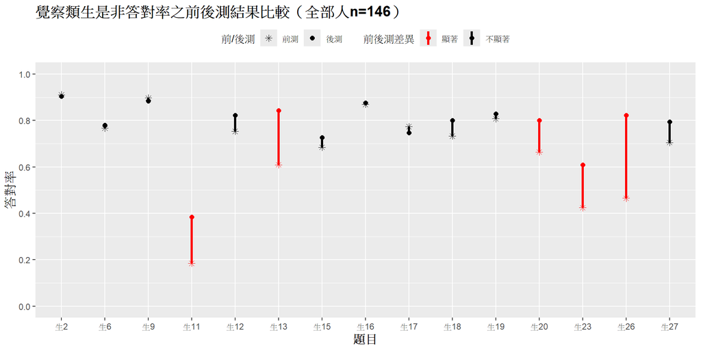

```r
yn_life.prepost.plot.sense(Cdat1_yn, Cdat2_yn, "覺察類生是非答對率之前後測結果比較（全部人n=146）")
```

### **6-2-1 覺察類生是非（國中生n=88）**

```r
paste("樣本數 =",dim(Cdat1_yn.ju)[1])
```

```
## [1] "樣本數 = 88"
```

```r
kk<-yn_life.prepost.table(Cdat1_yn.ju, Cdat2_yn.ju)[,-1]%>%filter(覺察==1)%>%dplyr::select(!c("知識性質","生活主題","覺察"))
colnames(kk)<-c("平均答對率","標準差","平均答對率","標準差","t統計量","p-value","檢定結果")

kk[,6]<-str_c(kk[,6]%>%round(digits=3),cut(kk[,6], breaks=c(0,0.001,0.01,0.05,1),labels=c("***","**","*","")))

kk%>%kable("html",escape = F,booktabs = TRUE, digits=c(3,2,3,2,3,3,3), caption="6-2-1 覺察類生是非（國中生n=88）")%>%
  kable_styling(c("striped", "bordered"))%>%
  add_header_above(c(" " = 1, "前測" = 2, "後測" = 2,"前後測成對t檢定" = 3))%>%
  column_spec(1, bold = T)%>%
  group_rows("覺察", 1, dim(kk)[1])
```

6-2-1 覺察類生是非（國中生n=88）

|  | 前測 平均答對率 | 前測 標準差 | 後測 平均答對率 | 後測 標準差 | 前後測成對t檢定 t統計量 | 前後測成對t檢定 p-value | 前後測成對t檢定 檢定結果 |
| --- | --- | --- | --- | --- | --- | --- | --- |
| **覺察** |  |  |  |  |  |  |  |
| 生是非2 | 0.909 | 0.29 | 0.875 | 0.33 | -0.904 | 0.369 | Don’t Reject H0 |
| 生是非6 | 0.727 | 0.45 | 0.750 | 0.44 | 0.406 | 0.686 | Don’t Reject H0 |
| 生是非9 | 0.875 | 0.33 | 0.841 | 0.37 | -0.831 | 0.408 | Don’t Reject H0 |
| 生是非11 | 0.182 | 0.39 | 0.409 | 0.49 | 3.438 | 0.001*** | Reject H0 |
| 生是非12 | 0.682 | 0.47 | 0.784 | 0.41 | 1.632 | 0.106 | Don’t Reject H0 |
| 生是非13 | 0.580 | 0.50 | 0.795 | 0.41 | 3.294 | 0.001** | Reject H0 |
| 生是非15 | 0.670 | 0.47 | 0.716 | 0.45 | 1.000 | 0.32 | Don’t Reject H0 |
| 生是非16 | 0.818 | 0.39 | 0.852 | 0.36 | 0.773 | 0.442 | Don’t Reject H0 |
| 生是非17 | 0.773 | 0.42 | 0.670 | 0.47 | -1.580 | 0.118 | Don’t Reject H0 |
| 生是非18 | 0.727 | 0.45 | 0.795 | 0.41 | 1.284 | 0.203 | Don’t Reject H0 |
| 生是非19 | 0.784 | 0.41 | 0.830 | 0.38 | 0.893 | 0.374 | Don’t Reject H0 |
| 生是非20 | 0.670 | 0.47 | 0.807 | 0.40 | 2.240 | 0.028* | Reject H0 |
| 生是非23 | 0.307 | 0.46 | 0.534 | 0.50 | 3.795 | 0*** | Reject H0 |
| 生是非26 | 0.375 | 0.49 | 0.761 | 0.43 | 6.085 | 0*** | Reject H0 |
| 生是非27 | 0.693 | 0.46 | 0.773 | 0.42 | 1.354 | 0.179 | Don’t Reject H0 |

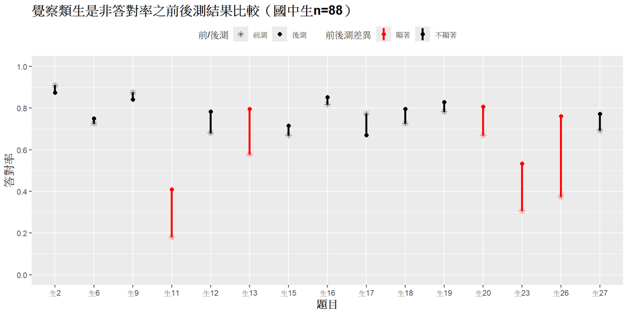

```r
yn_life.prepost.plot.sense(Cdat1_yn.ju, Cdat2_yn.ju, "覺察類生是非答對率之前後測結果比較（國中生n=88）")
```

### **6-2-2 覺察類生是非（高中生n=58）**

```r
paste("樣本數 =",dim(Cdat1_yn.se)[1])
```

```
## [1] "樣本數 = 58"
```

```r
kk<-yn_life.prepost.table(Cdat1_yn.se, Cdat2_yn.se)[,-1]%>%filter(覺察==1)%>%dplyr::select(!c("知識性質","生活主題","覺察"))
colnames(kk)<-c("平均答對率","標準差","平均答對率","標準差","t統計量","p-value","檢定結果")

kk[,6]<-str_c(kk[,6]%>%round(digits=3),cut(kk[,6], breaks=c(0,0.001,0.01,0.05,1),labels=c("***","**","*","")))

kk%>%kable("html",escape = F,booktabs = TRUE, digits=c(3,2,3,2,3,3,3), caption="6-2-2 覺察類生是非（高中生n=58）")%>%
  kable_styling(c("striped", "bordered"))%>%
  add_header_above(c(" " = 1, "前測" = 2, "後測" = 2,"前後測成對t檢定" = 3))%>%
  column_spec(1, bold = T)%>%
  group_rows("覺察", 1, dim(kk)[1])
```

6-2-2 覺察類生是非（高中生n=58）

|  | 前測 平均答對率 | 前測 標準差 | 後測 平均答對率 | 後測 標準差 | 前後測成對t檢定 t統計量 | 前後測成對t檢定 p-value | 前後測成對t檢定 檢定結果 |
| --- | --- | --- | --- | --- | --- | --- | --- |
| **覺察** |  |  |  |  |  |  |  |
| 生是非2 | 0.914 | 0.28 | 0.948 | 0.22 | 0.704 | 0.484 | Don’t Reject H0 |
| 生是非6 | 0.828 | 0.38 | 0.828 | 0.38 | 0.000 | 1 | No Change |
| 生是非9 | 0.931 | 0.26 | 0.948 | 0.22 | 0.375 | 0.709 | Don’t Reject H0 |
| 生是非11 | 0.190 | 0.40 | 0.345 | 0.48 | 2.127 | 0.038* | Reject H0 |
| 生是非12 | 0.862 | 0.35 | 0.879 | 0.33 | 0.275 | 0.784 | Don’t Reject H0 |
| 生是非13 | 0.655 | 0.48 | 0.914 | 0.28 | 3.401 | 0.001** | Reject H0 |
| 生是非15 | 0.707 | 0.46 | 0.741 | 0.44 | 0.468 | 0.641 | Don’t Reject H0 |
| 生是非16 | 0.948 | 0.22 | 0.914 | 0.28 | -0.704 | 0.484 | Don’t Reject H0 |
| 生是非17 | 0.776 | 0.42 | 0.862 | 0.35 | 1.299 | 0.199 | Don’t Reject H0 |
| 生是非18 | 0.741 | 0.44 | 0.810 | 0.40 | 0.942 | 0.35 | Don’t Reject H0 |
| 生是非19 | 0.845 | 0.37 | 0.828 | 0.38 | -0.299 | 0.766 | Don’t Reject H0 |
| 生是非20 | 0.655 | 0.48 | 0.793 | 0.41 | 1.929 | 0.059 | Don’t Reject H0 |
| 生是非23 | 0.603 | 0.49 | 0.724 | 0.45 | 1.844 | 0.07 | Don’t Reject H0 |
| 生是非26 | 0.603 | 0.49 | 0.914 | 0.28 | 4.158 | 0*** | Reject H0 |
| 生是非27 | 0.724 | 0.45 | 0.828 | 0.38 | 1.427 | 0.159 | Don’t Reject H0 |

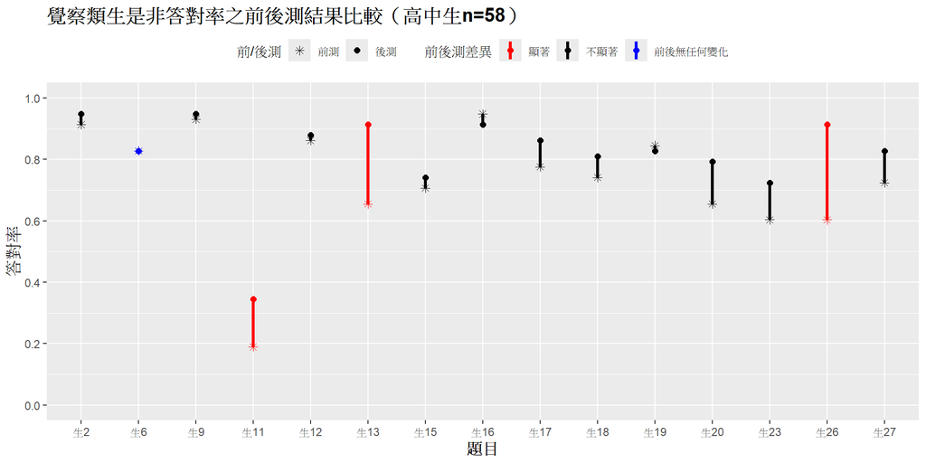

```r
yn_life.prepost.plot.sense(Cdat1_yn.se, Cdat2_yn.se, "覺察類生是非答對率之前後測結果比較（高中生n=58）")
```

## **6-3-1 覺察的表格彙整（國中生n=88 vs. 高中生n=58）**

```r
mean_score.sense1<-mean_table.lifes(Cdat1_yn.ju, Cdat2_yn.ju, "覺察")%>%as.data.frame()
mean_score.sense2<-mean_table.lifes(Cdat1_yn.se, Cdat2_yn.se, "覺察")%>%as.data.frame()
mean_score.sense.juse<-cbind(mean_score.sense1, mean_score.sense2)
rownames(mean_score.sense.juse)<-"覺察"
colnames(mean_score.sense.juse)<-rep(c("平均答對率","標準差","平均答對率","標準差","t統計量","p-value"),2)

mean_score.sense.juse[,6]<-str_c(mean_score.sense.juse[,6]%>%as.numeric()%>%round(digits=3),cut(mean_score.sense.juse[,6]%>%as.numeric(), breaks=c(0,0.001,0.01,0.05,1),labels=c("***","**","*","")))

mean_score.sense.juse[,12]<-str_c(mean_score.sense.juse[,12]%>%as.numeric()%>%round(digits=3),cut(mean_score.sense.juse[,12]%>%as.numeric(), breaks=c(0,0.001,0.01,0.05,1),labels=c("***","**","*","")))

mean_score.sense.juse%>%kable("html",escape = F,booktabs = TRUE, digits=c(3,2,3,2,3,3,3), caption="6-3-1 覺察的表格彙整（國中生n=88 vs. 高中生n=58）")%>%
  kable_styling(c("striped", "bordered"))%>%
  add_header_above(c(" " = 1, "前測" = 2, "後測" = 2,"前後測成對t檢定" = 2, "前測" = 2, "後測" = 2,"前後測成對t檢定" = 2))%>%
  add_header_above(c(" " = 1, "國中生 (n=73)" = 6, "高中生 (n=34)" = 6))%>%
  column_spec(1, bold = T)
```

6-3-1 覺察的表格彙整（國中生n=88 vs. 高中生n=58）

[output not shown]

```r
#write.xlsx(mean_score.sense.juse,rowNames=T,"C:/Users/h2407/OneDrive/文件/1121/師培中心分析案/報表資料檔/覺察類生是非的整體平均（國中生n=88 vs. 高中生n=58）.xlsx")
```

## **6-3-2 覺察類生是非（國中生n=88 vs. 高中生n=58）**

```r
kk<-yn_life.prepost.compare.table(Cdat1_yn.ju, Cdat2_yn.ju, Cdat1_yn.se, Cdat2_yn.se, 1)%>%filter(覺察==1)%>%dplyr::select(!c("知識性質","生活主題","覺察"))

colnames(kk)<-c("","","平均答對率","標準差","平均答對率","標準差","t統計量","p-value","檢定結果")

kk[,8]<-str_c(kk[,8]%>%round(digits=3),cut(kk[,8], breaks=c(0,0.001,0.01,0.05,1),labels=c("***","**","*","")))

kk%>%kable("html",escape = F,booktabs = TRUE, digits=c(0,0,3,2,3,2,3,3,3), caption="6-3-2 覺察類生是非（國中生n=88 vs. 高中生n=58）")%>%
  kable_styling(c("striped", "bordered"))%>%
  add_header_above(c(" " = 2, "前測" = 2, "後測" = 2,"前後測成對t檢定" = 3))%>%
  column_spec(1, bold = T)%>%
  collapse_rows(columns = 1)%>%
  group_rows("覺察", 1, dim(kk)[1])
```

6-3-2 覺察類生是非（國中生n=88 vs. 高中生n=58）

|  |  | 前測 平均答對率 | 前測 標準差 | 後測 平均答對率 | 後測 標準差 | 前後測成對t檢定 t統計量 | 前後測成對t檢定 p-value | 前後測成對t檢定 檢定結果 |
| --- | --- | --- | --- | --- | --- | --- | --- | --- |
| **覺察** |  |  |  |  |  |  |  |  |
| 生是非2 | 國中 | 0.909 | 0.29 | 0.875 | 0.33 | -0.904 | 0.369 | Don’t Reject H0 |
|  | 高中 | 0.914 | 0.28 | 0.948 | 0.22 | 0.704 | 0.484 | Don’t Reject H0 |
| 生是非6 | 國中 | 0.727 | 0.45 | 0.750 | 0.44 | 0.406 | 0.686 | Don’t Reject H0 |
|  | 高中 | 0.828 | 0.38 | 0.828 | 0.38 | 0.000 | 1 | No Change |
| 生是非9 | 國中 | 0.875 | 0.33 | 0.841 | 0.37 | -0.831 | 0.408 | Don’t Reject H0 |
|  | 高中 | 0.931 | 0.26 | 0.948 | 0.22 | 0.375 | 0.709 | Don’t Reject H0 |
| 生是非11 | 國中 | 0.182 | 0.39 | 0.409 | 0.49 | 3.438 | 0.001*** | Reject H0 |
|  | 高中 | 0.190 | 0.40 | 0.345 | 0.48 | 2.127 | 0.038* | Reject H0 |
| 生是非12 | 國中 | 0.682 | 0.47 | 0.784 | 0.41 | 1.632 | 0.106 | Don’t Reject H0 |
|  | 高中 | 0.862 | 0.35 | 0.879 | 0.33 | 0.275 | 0.784 | Don’t Reject H0 |
| 生是非13 | 國中 | 0.580 | 0.50 | 0.795 | 0.41 | 3.294 | 0.001** | Reject H0 |
|  | 高中 | 0.655 | 0.48 | 0.914 | 0.28 | 3.401 | 0.001** | Reject H0 |
| 生是非15 | 國中 | 0.670 | 0.47 | 0.716 | 0.45 | 1.000 | 0.32 | Don’t Reject H0 |
|  | 高中 | 0.707 | 0.46 | 0.741 | 0.44 | 0.468 | 0.641 | Don’t Reject H0 |
| 生是非16 | 國中 | 0.818 | 0.39 | 0.852 | 0.36 | 0.773 | 0.442 | Don’t Reject H0 |
|  | 高中 | 0.948 | 0.22 | 0.914 | 0.28 | -0.704 | 0.484 | Don’t Reject H0 |
| 生是非17 | 國中 | 0.773 | 0.42 | 0.670 | 0.47 | -1.580 | 0.118 | Don’t Reject H0 |
|  | 高中 | 0.776 | 0.42 | 0.862 | 0.35 | 1.299 | 0.199 | Don’t Reject H0 |
| 生是非18 | 國中 | 0.727 | 0.45 | 0.795 | 0.41 | 1.284 | 0.203 | Don’t Reject H0 |
|  | 高中 | 0.741 | 0.44 | 0.810 | 0.40 | 0.942 | 0.35 | Don’t Reject H0 |
| 生是非19 | 國中 | 0.784 | 0.41 | 0.830 | 0.38 | 0.893 | 0.374 | Don’t Reject H0 |
|  | 高中 | 0.845 | 0.37 | 0.828 | 0.38 | -0.299 | 0.766 | Don’t Reject H0 |
| 生是非20 | 國中 | 0.670 | 0.47 | 0.807 | 0.40 | 2.240 | 0.028* | Reject H0 |
|  | 高中 | 0.655 | 0.48 | 0.793 | 0.41 | 1.929 | 0.059 | Don’t Reject H0 |
| 生是非23 | 國中 | 0.307 | 0.46 | 0.534 | 0.50 | 3.795 | 0*** | Reject H0 |
|  | 高中 | 0.603 | 0.49 | 0.724 | 0.45 | 1.844 | 0.07 | Don’t Reject H0 |
| 生是非26 | 國中 | 0.375 | 0.49 | 0.761 | 0.43 | 6.085 | 0*** | Reject H0 |
|  | 高中 | 0.603 | 0.49 | 0.914 | 0.28 | 4.158 | 0*** | Reject H0 |
| 生是非27 | 國中 | 0.693 | 0.46 | 0.773 | 0.42 | 1.354 | 0.179 | Don’t Reject H0 |
|  | 高中 | 0.724 | 0.45 | 0.828 | 0.38 | 1.427 | 0.159 | Don’t Reject H0 |

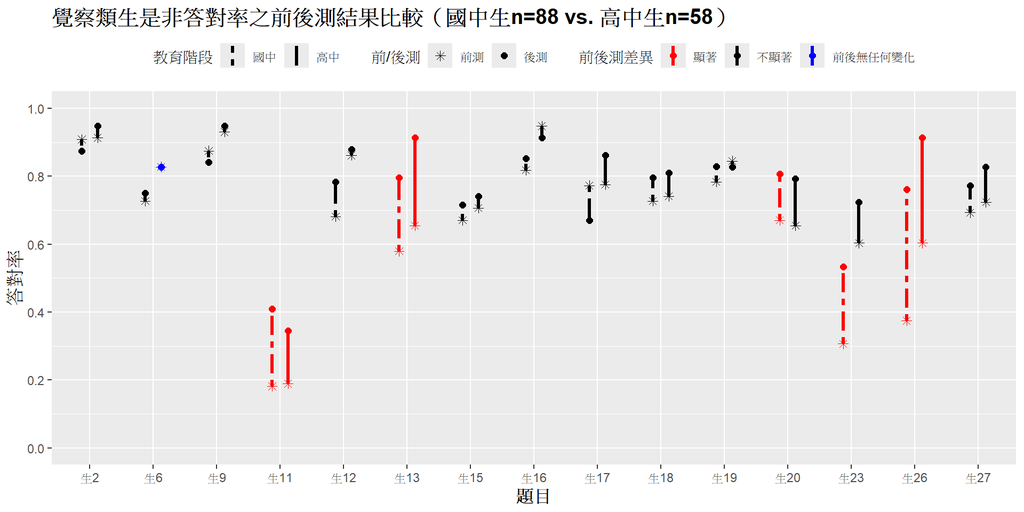

```r
yn.prepost.compare.plot(res11[res11$覺察==1,], "覺察類生是非答對率之前後測結果比較（國中生n=88 vs. 高中生n=58）", state=1)
```

# **根據人的特徵分組的前後測分析**

# **7. 肥胖程度的影響分析**

```r
Cfat<-Cdat1_yn$流水號%in%eat[which(eat$`平均一餐熱量需求(kcal)`>=700),]$流水號
Cnofat<-Cdat1_yn$流水號%in%eat[which(eat$`平均一餐熱量需求(kcal)`<700),]$流水號
#Cfat<-eat[which(eat$`平均一餐熱量需求(kcal)`<700),]$流水號%in%Cdat1_yn$流水號

Cfat.bf<-Cdat1_yn$流水號%in%eat[which(eat$`早餐總熱量(kcal)`>=500),]$流水號
Cnofat.bf<-Cdat1_yn$流水號%in%eat[which(eat$`早餐總熱量(kcal)`<500),]$流水號

# dat1_yn.fat<-dat1_yn.1[which(dat1_yn.1$流水號%in%eat[which(eat$`平均一餐熱量需求(kcal)`>=700),]$流水號),]
# dat2_yn.fat<-dat2_yn.1[which(dat1_yn.1$流水號%in%eat[which(eat$`平均一餐熱量需求(kcal)`>=700),]$流水號),]
```

## **7-1 是非題前後測答對率（肥胖者n=20 vs. 其他人n=89）**

```r
kk<-yn.prepost.compare.table(Cdat1_yn%>%filter(Cfat&(Cfat.bf|Cnofat.bf)),
                            Cdat2_yn%>%filter(Cfat&(Cfat.bf|Cnofat.bf)),
                            Cdat1_yn%>%filter(Cnofat&(Cfat.bf|Cnofat.bf)),
                            Cdat2_yn%>%filter(Cnofat&(Cfat.bf|Cnofat.bf)), 2)

colnames(kk)<-c("","","平均答對率","標準差","平均答對率","標準差","t統計量","p-value","檢定結果")


kk[,7]<-kk[,7]%>%as.numeric%>%round(digits=3)

kk[,8]<-str_c(kk[,8]%>%as.numeric%>%round(digits=3),cut(kk[,8]%>%as.numeric, breaks=c(0,0.001,0.01,0.05,1),labels=c("***","**","*","")))

kk%>%kable("html",escape = F,booktabs = TRUE, digits=c(0,0,3,2,3,2,3,3,3), caption="7-1 是非題前後測答對率（肥胖者n=20 vs. 其他人n=89）")%>%
  kable_styling(c("striped", "bordered"))%>%
  add_header_above(c(" " = 2, "前測" = 2, "後測" = 2,"前後測成對t檢定" = 3))%>%
  column_spec(1, bold = T)%>%
  collapse_rows(columns = 1)%>%
  group_rows("生是非", 1, 60)%>%
  group_rows("技是非", 61, 80)
```

7-1 是非題前後測答對率（肥胖者n=20 vs. 其他人n=89）

|  |  | 前測 平均答對率 | 前測 標準差 | 後測 平均答對率 | 後測 標準差 | 前後測成對t檢定 t統計量 | 前後測成對t檢定 p-value | 前後測成對t檢定 檢定結果 |
| --- | --- | --- | --- | --- | --- | --- | --- | --- |
| **生是非** |  |  |  |  |  |  |  |  |
| 生是非1 | 肥胖者 | 0.800 | 0.41 | 0.750 | 0.44 | -0.438 | 0.666 | Don’t Reject H0 |
|  | 其他人 | 0.775 | 0.42 | 0.798 | 0.40 | 0.498 | 0.62 | Don’t Reject H0 |
| 生是非2 | 肥胖者 | 0.950 | 0.22 | 0.850 | 0.37 | -1.000 | 0.33 | Don’t Reject H0 |
|  | 其他人 | 0.899 | 0.30 | 0.910 | 0.29 | 0.276 | 0.783 | Don’t Reject H0 |
| 生是非3 | 肥胖者 | 0.800 | 0.41 | 0.750 | 0.44 | -0.370 | 0.716 | Don’t Reject H0 |
|  | 其他人 | 0.775 | 0.42 | 0.843 | 0.37 | 1.284 | 0.203 | Don’t Reject H0 |
| 生是非4 | 肥胖者 | 0.800 | 0.41 | 0.800 | 0.41 | 0.000 | 1 | No Change |
|  | 其他人 | 0.854 | 0.36 | 0.764 | 0.43 | -2.183 | 0.032* | Reject H0 |
| 生是非5 | 肥胖者 | 0.300 | 0.47 | 0.500 | 0.51 | 1.710 | 0.104 | Don’t Reject H0 |
|  | 其他人 | 0.438 | 0.50 | 0.551 | 0.50 | 1.994 | 0.049* | Reject H0 |
| 生是非6 | 肥胖者 | 0.750 | 0.44 | 0.800 | 0.41 | 0.438 | 0.666 | Don’t Reject H0 |
|  | 其他人 | 0.753 | 0.43 | 0.730 | 0.45 | -0.406 | 0.685 | Don’t Reject H0 |
| 生是非7 | 肥胖者 | 0.700 | 0.47 | 0.800 | 0.41 | 0.698 | 0.494 | Don’t Reject H0 |
|  | 其他人 | 0.843 | 0.37 | 0.798 | 0.40 | -0.815 | 0.417 | Don’t Reject H0 |
| 生是非8 | 肥胖者 | 0.500 | 0.51 | 0.700 | 0.47 | 1.710 | 0.104 | Don’t Reject H0 |
|  | 其他人 | 0.483 | 0.50 | 0.685 | 0.47 | 3.361 | 0.001** | Reject H0 |
| 生是非9 | 肥胖者 | 0.850 | 0.37 | 0.800 | 0.41 | -0.438 | 0.666 | Don’t Reject H0 |
|  | 其他人 | 0.921 | 0.27 | 0.899 | 0.30 | -0.630 | 0.53 | Don’t Reject H0 |
| 生是非10 | 肥胖者 | 0.700 | 0.47 | 0.650 | 0.49 | -0.438 | 0.666 | Don’t Reject H0 |
|  | 其他人 | 0.652 | 0.48 | 0.787 | 0.41 | 2.165 | 0.033* | Reject H0 |
| 生是非11 | 肥胖者 | 0.050 | 0.22 | 0.450 | 0.51 | 3.559 | 0.002** | Reject H0 |
|  | 其他人 | 0.247 | 0.43 | 0.416 | 0.50 | 2.540 | 0.013* | Reject H0 |
| 生是非12 | 肥胖者 | 0.650 | 0.49 | 0.850 | 0.37 | 1.710 | 0.104 | Don’t Reject H0 |
|  | 其他人 | 0.742 | 0.44 | 0.831 | 0.38 | 1.523 | 0.131 | Don’t Reject H0 |
| 生是非13 | 肥胖者 | 0.600 | 0.50 | 0.850 | 0.37 | 1.561 | 0.135 | Don’t Reject H0 |
|  | 其他人 | 0.640 | 0.48 | 0.843 | 0.37 | 3.486 | 0.001*** | Reject H0 |
| 生是非14 | 肥胖者 | 0.800 | 0.41 | 0.750 | 0.44 | -0.438 | 0.666 | Don’t Reject H0 |
|  | 其他人 | 0.685 | 0.47 | 0.607 | 0.49 | -1.222 | 0.225 | Don’t Reject H0 |
| 生是非15 | 肥胖者 | 0.600 | 0.50 | 0.650 | 0.49 | 0.370 | 0.716 | Don’t Reject H0 |

[output cut: 52 more lines]

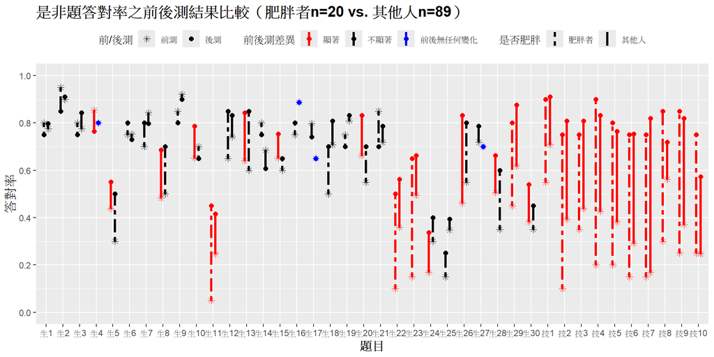

```r
res_fat<-yn.prepost.table(Cdat1_yn%>%filter(Cfat&(Cfat.bf|Cnofat.bf)),
                          Cdat2_yn%>%filter(Cfat&(Cfat.bf|Cnofat.bf)))
res_nofat<-yn.prepost.table(Cdat1_yn%>%filter(Cnofat&(Cfat.bf|Cnofat.bf)),
                            Cdat2_yn%>%filter(Cnofat&(Cfat.bf|Cnofat.bf)))
res2<-rbind(res_fat, res_nofat)

yn.prepost.compare.plot(res2, "是非題答對率之前後測結果比較（肥胖者n=20 vs. 其他人n=89）", state=2)
```

## **7-2 知識性質生是非前後測答對率（肥胖者n=20 vs. 其他人n=89）**

```r
kk<-yn_life.prepost.compare.table(Cdat1_yn%>%filter(Cfat&(Cfat.bf|Cnofat.bf)),
                                  Cdat2_yn%>%filter(Cfat&(Cfat.bf|Cnofat.bf)),
                                  Cdat1_yn%>%filter(Cnofat&(Cfat.bf|Cnofat.bf)),
                                  Cdat2_yn%>%filter(Cnofat&(Cfat.bf|Cnofat.bf)),2)%>%
  arrange(知識性質)%>%dplyr::select(!c("知識性質","生活主題","覺察"))

colnames(kk)<-c("","","平均答對率","標準差","平均答對率","標準差","t統計量","p-value","檢定結果")

kk[,7]<-kk[,7]%>%as.numeric%>%round(digits=3)

kk[,8]<-str_c(kk[,8]%>%as.numeric%>%round(digits=3),cut(kk[,8]%>%as.numeric, breaks=c(0,0.001,0.01,0.05,1),labels=c("***","**","*","")))

kk%>%kable("html",escape = F,booktabs = TRUE, digits=c(0,0,3,2,3,2,3,3,3), caption="7-2 知識性質生是非前後測答對率（肥胖者n=20 vs. 其他人n=89）")%>%
  kable_styling(c("striped", "bordered"))%>%
  add_header_above(c(" " = 2, "前測" = 2, "後測" = 2,"前後測成對t檢定" = 3))%>%
  column_spec(1, bold = T)%>%
  collapse_rows(columns = 1)%>%
  group_rows("知識", 1, 20)%>%
  group_rows("推論", 21, 50)%>%
  group_rows("計算", 51, 60)
```

7-2 知識性質生是非前後測答對率（肥胖者n=20 vs. 其他人n=89）

|  |  | 前測 平均答對率 | 前測 標準差 | 後測 平均答對率 | 後測 標準差 | 前後測成對t檢定 t統計量 | 前後測成對t檢定 p-value | 前後測成對t檢定 檢定結果 |
| --- | --- | --- | --- | --- | --- | --- | --- | --- |
| **知識** |  |  |  |  |  |  |  |  |
| 生是非1 | 肥胖者 | 0.800 | 0.41 | 0.750 | 0.44 | -0.438 | 0.666 | Don’t Reject H0 |
|  | 其他人 | 0.775 | 0.42 | 0.798 | 0.40 | 0.498 | 0.62 | Don’t Reject H0 |
| 生是非2 | 肥胖者 | 0.950 | 0.22 | 0.850 | 0.37 | -1.000 | 0.33 | Don’t Reject H0 |
|  | 其他人 | 0.899 | 0.30 | 0.910 | 0.29 | 0.276 | 0.783 | Don’t Reject H0 |
| 生是非4 | 肥胖者 | 0.800 | 0.41 | 0.800 | 0.41 | 0.000 | 1 | No Change |
|  | 其他人 | 0.854 | 0.36 | 0.764 | 0.43 | -2.183 | 0.032* | Reject H0 |
| 生是非5 | 肥胖者 | 0.300 | 0.47 | 0.500 | 0.51 | 1.710 | 0.104 | Don’t Reject H0 |
|  | 其他人 | 0.438 | 0.50 | 0.551 | 0.50 | 1.994 | 0.049* | Reject H0 |
| 生是非6 | 肥胖者 | 0.750 | 0.44 | 0.800 | 0.41 | 0.438 | 0.666 | Don’t Reject H0 |
|  | 其他人 | 0.753 | 0.43 | 0.730 | 0.45 | -0.406 | 0.685 | Don’t Reject H0 |
| 生是非7 | 肥胖者 | 0.700 | 0.47 | 0.800 | 0.41 | 0.698 | 0.494 | Don’t Reject H0 |
|  | 其他人 | 0.843 | 0.37 | 0.798 | 0.40 | -0.815 | 0.417 | Don’t Reject H0 |
| 生是非13 | 肥胖者 | 0.600 | 0.50 | 0.850 | 0.37 | 1.561 | 0.135 | Don’t Reject H0 |
|  | 其他人 | 0.640 | 0.48 | 0.843 | 0.37 | 3.486 | 0.001*** | Reject H0 |
| 生是非14 | 肥胖者 | 0.800 | 0.41 | 0.750 | 0.44 | -0.438 | 0.666 | Don’t Reject H0 |
|  | 其他人 | 0.685 | 0.47 | 0.607 | 0.49 | -1.222 | 0.225 | Don’t Reject H0 |
| 生是非18 | 肥胖者 | 0.500 | 0.51 | 0.700 | 0.47 | 1.285 | 0.214 | Don’t Reject H0 |
|  | 其他人 | 0.708 | 0.46 | 0.809 | 0.40 | 1.904 | 0.06 | Don’t Reject H0 |
| 生是非29 | 肥胖者 | 0.450 | 0.51 | 0.800 | 0.41 | 2.666 | 0.015* | Reject H0 |
|  | 其他人 | 0.618 | 0.49 | 0.876 | 0.33 | 4.397 | 0*** | Reject H0 |
| **推論** |  |  |  |  |  |  |  |  |
| 生是非3 | 肥胖者 | 0.800 | 0.41 | 0.750 | 0.44 | -0.370 | 0.716 | Don’t Reject H0 |
|  | 其他人 | 0.775 | 0.42 | 0.843 | 0.37 | 1.284 | 0.203 | Don’t Reject H0 |
| 生是非8 | 肥胖者 | 0.500 | 0.51 | 0.700 | 0.47 | 1.710 | 0.104 | Don’t Reject H0 |
|  | 其他人 | 0.483 | 0.50 | 0.685 | 0.47 | 3.361 | 0.001** | Reject H0 |
| 生是非9 | 肥胖者 | 0.850 | 0.37 | 0.800 | 0.41 | -0.438 | 0.666 | Don’t Reject H0 |
|  | 其他人 | 0.921 | 0.27 | 0.899 | 0.30 | -0.630 | 0.53 | Don’t Reject H0 |
| 生是非10 | 肥胖者 | 0.700 | 0.47 | 0.650 | 0.49 | -0.438 | 0.666 | Don’t Reject H0 |
|  | 其他人 | 0.652 | 0.48 | 0.787 | 0.41 | 2.165 | 0.033* | Reject H0 |
| 生是非11 | 肥胖者 | 0.050 | 0.22 | 0.450 | 0.51 | 3.559 | 0.002** | Reject H0 |
|  | 其他人 | 0.247 | 0.43 | 0.416 | 0.50 | 2.540 | 0.013* | Reject H0 |
| 生是非12 | 肥胖者 | 0.650 | 0.49 | 0.850 | 0.37 | 1.710 | 0.104 | Don’t Reject H0 |
|  | 其他人 | 0.742 | 0.44 | 0.831 | 0.38 | 1.523 | 0.131 | Don’t Reject H0 |
| 生是非15 | 肥胖者 | 0.600 | 0.50 | 0.650 | 0.49 | 0.370 | 0.716 | Don’t Reject H0 |
|  | 其他人 | 0.652 | 0.48 | 0.753 | 0.43 | 1.997 | 0.049* | Reject H0 |
| 生是非16 | 肥胖者 | 0.750 | 0.44 | 0.800 | 0.41 | 0.370 | 0.716 | Don’t Reject H0 |
|  | 其他人 | 0.888 | 0.32 | 0.888 | 0.32 | 0.000 | 1 | No Change |
| 生是非17 | 肥胖者 | 0.650 | 0.49 | 0.650 | 0.49 | 0.000 | 1 | No Change |
|  | 其他人 | 0.798 | 0.40 | 0.742 | 0.44 | -0.962 | 0.339 | Don’t Reject H0 |
| 生是非19 | 肥胖者 | 0.750 | 0.44 | 0.700 | 0.47 | -0.438 | 0.666 | Don’t Reject H0 |
|  | 其他人 | 0.809 | 0.40 | 0.831 | 0.38 | 0.424 | 0.672 | Don’t Reject H0 |
| 生是非20 | 肥胖者 | 0.550 | 0.51 | 0.700 | 0.47 | 1.143 | 0.267 | Don’t Reject H0 |
|  | 其他人 | 0.663 | 0.48 | 0.831 | 0.38 | 2.795 | 0.006** | Reject H0 |
| 生是非21 | 肥胖者 | 0.850 | 0.37 | 0.700 | 0.47 | -1.371 | 0.186 | Don’t Reject H0 |
|  | 其他人 | 0.719 | 0.45 | 0.787 | 0.41 | 1.228 | 0.223 | Don’t Reject H0 |
| 生是非22 | 肥胖者 | 0.100 | 0.31 | 0.500 | 0.51 | 2.990 | 0.008** | Reject H0 |
|  | 其他人 | 0.360 | 0.48 | 0.562 | 0.50 | 2.890 | 0.005** | Reject H0 |
| 生是非23 | 肥胖者 | 0.150 | 0.37 | 0.650 | 0.49 | 3.684 | 0.002** | Reject H0 |
|  | 其他人 | 0.494 | 0.50 | 0.663 | 0.48 | 2.899 | 0.005** | Reject H0 |
| 生是非27 | 肥胖者 | 0.700 | 0.47 | 0.700 | 0.47 | 0.000 | 1 | No Change |
|  | 其他人 | 0.719 | 0.45 | 0.787 | 0.41 | 1.228 | 0.223 | Don’t Reject H0 |
| **計算** |  |  |  |  |  |  |  |  |
| 生是非24 | 肥胖者 | 0.300 | 0.47 | 0.400 | 0.50 | 0.698 | 0.494 | Don’t Reject H0 |
|  | 其他人 | 0.169 | 0.38 | 0.337 | 0.48 | 2.702 | 0.008** | Reject H0 |
| 生是非25 | 肥胖者 | 0.150 | 0.37 | 0.250 | 0.44 | 1.000 | 0.33 | Don’t Reject H0 |
|  | 其他人 | 0.348 | 0.48 | 0.393 | 0.49 | 0.754 | 0.453 | Don’t Reject H0 |
| 生是非26 | 肥胖者 | 0.550 | 0.51 | 0.800 | 0.41 | 1.751 | 0.096 | Don’t Reject H0 |
|  | 其他人 | 0.461 | 0.50 | 0.831 | 0.38 | 5.916 | 0*** | Reject H0 |
| 生是非28 | 肥胖者 | 0.350 | 0.49 | 0.600 | 0.50 | 1.422 | 0.171 | Don’t Reject H0 |
|  | 其他人 | 0.506 | 0.50 | 0.663 | 0.48 | 2.153 | 0.034* | Reject H0 |
| 生是非30 | 肥胖者 | 0.350 | 0.49 | 0.450 | 0.51 | 0.698 | 0.494 | Don’t Reject H0 |
|  | 其他人 | 0.382 | 0.49 | 0.539 | 0.50 | 2.741 | 0.007** | Reject H0 |

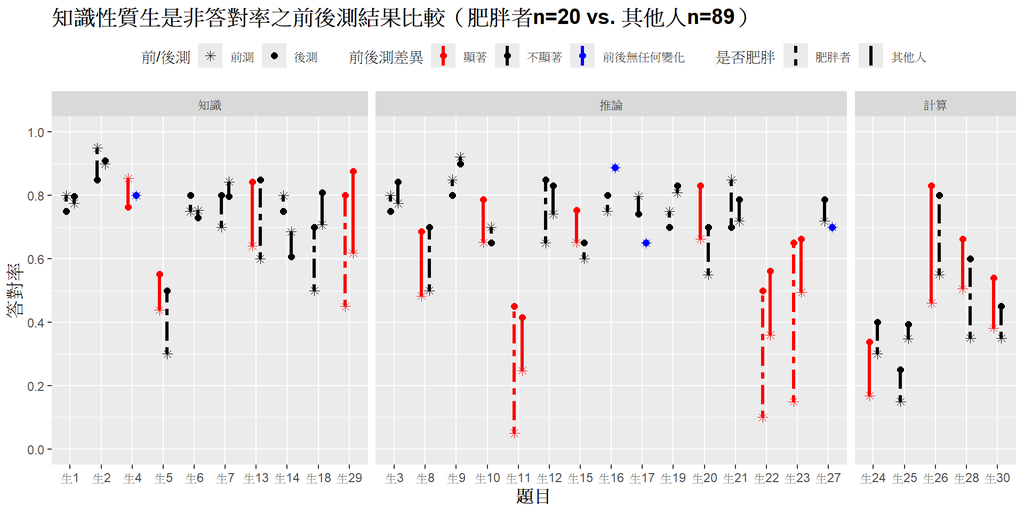

```r
res_fat<-yn_life.prepost.table(Cdat1_yn%>%filter(Cfat&(Cfat.bf|Cnofat.bf)),
                               Cdat2_yn%>%filter(Cfat&(Cfat.bf|Cnofat.bf)))
res_nofat<-yn_life.prepost.table(Cdat1_yn%>%filter(Cnofat&(Cfat.bf|Cnofat.bf)),
                                 Cdat2_yn%>%filter(Cnofat&(Cfat.bf|Cnofat.bf)))
res21<-rbind(res_fat, res_nofat)

yn.prepost.compare.plot(res21, "知識性質生是非答對率之前後測結果比較（肥胖者n=20 vs. 其他人n=89）", state=2)+
  facet_grid(cols=vars(知識性質), scales = "free", space = "free")
```

## **7-3 生活主題生是非前後測答對率（肥胖者n=20 vs. 其他人n=89）**

```r
kk<-yn_life.prepost.compare.table(Cdat1_yn%>%filter(Cfat&(Cfat.bf|Cnofat.bf)),
                                  Cdat2_yn%>%filter(Cfat&(Cfat.bf|Cnofat.bf)),
                                  Cdat1_yn%>%filter(Cnofat&(Cfat.bf|Cnofat.bf)),
                                  Cdat2_yn%>%filter(Cnofat&(Cfat.bf|Cnofat.bf)),2)%>%
  arrange(生活主題)
kk1<-kk%>%dplyr::select(!c("知識性質","生活主題","覺察"))
colnames(kk1)<-c("","","平均答對率","標準差","平均答對率","標準差","t統計量","p-value","檢定結果")

kk1[,7]<-kk1[,7]%>%as.numeric%>%round(digits=3)

kk1[,8]<-str_c(kk1[,8]%>%as.numeric%>%round(digits=3),cut(kk1[,8]%>%as.numeric, breaks=c(0,0.001,0.01,0.05,1),labels=c("***","**","*","")))

kk1%>%kable("html",escape = F,booktabs = TRUE, digits=c(0,0,3,2,3,2,3,3,3), caption="7-3 生活主題生是非前後測答對率（肥胖者n=20 vs. 其他人n=89）")%>%
  kable_styling(c("striped", "bordered"))%>%
  add_header_above(c(" " = 2, "前測" = 2, "後測" = 2,"前後測成對t檢定" = 3))%>%
  column_spec(1, bold = T)%>%
  collapse_rows(columns = 1)%>%
  group_rows(levels(kk$生活主題)[1], 1, cumsum(table(kk$生活主題))[[1]])%>%
  group_rows(levels(kk$生活主題)[2], cumsum(table(kk$生活主題))[[1]]+1, cumsum(table(kk$生活主題))[[2]])%>%
  group_rows(levels(kk$生活主題)[3], cumsum(table(kk$生活主題))[[2]]+1, cumsum(table(kk$生活主題))[[3]])%>%
  group_rows(levels(kk$生活主題)[4], cumsum(table(kk$生活主題))[[3]]+1, cumsum(table(kk$生活主題))[[4]])%>%
  group_rows(levels(kk$生活主題)[5], cumsum(table(kk$生活主題))[[4]]+1, cumsum(table(kk$生活主題))[[5]])%>%
  group_rows(levels(kk$生活主題)[6], cumsum(table(kk$生活主題))[[5]]+1, cumsum(table(kk$生活主題))[[6]])%>%
  group_rows(levels(kk$生活主題)[7], cumsum(table(kk$生活主題))[[6]]+1, cumsum(table(kk$生活主題))[[7]])%>%
  group_rows(levels(kk$生活主題)[8], cumsum(table(kk$生活主題))[[7]]+1, cumsum(table(kk$生活主題))[[8]])
```

7-3 生活主題生是非前後測答對率（肥胖者n=20 vs. 其他人n=89）

|  |  | 前測 平均答對率 | 前測 標準差 | 後測 平均答對率 | 後測 標準差 | 前後測成對t檢定 t統計量 | 前後測成對t檢定 p-value | 前後測成對t檢定 檢定結果 |
| --- | --- | --- | --- | --- | --- | --- | --- | --- |
| **01營養素** |  |  |  |  |  |  |  |  |
| 生是非1 | 肥胖者 | 0.800 | 0.41 | 0.750 | 0.44 | -0.438 | 0.666 | Don’t Reject H0 |
|  | 其他人 | 0.775 | 0.42 | 0.798 | 0.40 | 0.498 | 0.62 | Don’t Reject H0 |
| 生是非2 | 肥胖者 | 0.950 | 0.22 | 0.850 | 0.37 | -1.000 | 0.33 | Don’t Reject H0 |
|  | 其他人 | 0.899 | 0.30 | 0.910 | 0.29 | 0.276 | 0.783 | Don’t Reject H0 |
| 生是非4 | 肥胖者 | 0.800 | 0.41 | 0.800 | 0.41 | 0.000 | 1 | No Change |
|  | 其他人 | 0.854 | 0.36 | 0.764 | 0.43 | -2.183 | 0.032* | Reject H0 |
| 生是非24 | 肥胖者 | 0.300 | 0.47 | 0.400 | 0.50 | 0.698 | 0.494 | Don’t Reject H0 |
|  | 其他人 | 0.169 | 0.38 | 0.337 | 0.48 | 2.702 | 0.008** | Reject H0 |
| **02細胞** |  |  |  |  |  |  |  |  |
| 生是非3 | 肥胖者 | 0.800 | 0.41 | 0.750 | 0.44 | -0.370 | 0.716 | Don’t Reject H0 |
|  | 其他人 | 0.775 | 0.42 | 0.843 | 0.37 | 1.284 | 0.203 | Don’t Reject H0 |
| 生是非5 | 肥胖者 | 0.300 | 0.47 | 0.500 | 0.51 | 1.710 | 0.104 | Don’t Reject H0 |
|  | 其他人 | 0.438 | 0.50 | 0.551 | 0.50 | 1.994 | 0.049* | Reject H0 |
| 生是非8 | 肥胖者 | 0.500 | 0.51 | 0.700 | 0.47 | 1.710 | 0.104 | Don’t Reject H0 |
|  | 其他人 | 0.483 | 0.50 | 0.685 | 0.47 | 3.361 | 0.001** | Reject H0 |
| 生是非10 | 肥胖者 | 0.700 | 0.47 | 0.650 | 0.49 | -0.438 | 0.666 | Don’t Reject H0 |
|  | 其他人 | 0.652 | 0.48 | 0.787 | 0.41 | 2.165 | 0.033* | Reject H0 |
| **03食物** |  |  |  |  |  |  |  |  |
| 生是非12 | 肥胖者 | 0.650 | 0.49 | 0.850 | 0.37 | 1.710 | 0.104 | Don’t Reject H0 |
|  | 其他人 | 0.742 | 0.44 | 0.831 | 0.38 | 1.523 | 0.131 | Don’t Reject H0 |
| 生是非18 | 肥胖者 | 0.500 | 0.51 | 0.700 | 0.47 | 1.285 | 0.214 | Don’t Reject H0 |
|  | 其他人 | 0.708 | 0.46 | 0.809 | 0.40 | 1.904 | 0.06 | Don’t Reject H0 |
| 生是非20 | 肥胖者 | 0.550 | 0.51 | 0.700 | 0.47 | 1.143 | 0.267 | Don’t Reject H0 |
|  | 其他人 | 0.663 | 0.48 | 0.831 | 0.38 | 2.795 | 0.006** | Reject H0 |
| 生是非23 | 肥胖者 | 0.150 | 0.37 | 0.650 | 0.49 | 3.684 | 0.002** | Reject H0 |
|  | 其他人 | 0.494 | 0.50 | 0.663 | 0.48 | 2.899 | 0.005** | Reject H0 |
| 生是非30 | 肥胖者 | 0.350 | 0.49 | 0.450 | 0.51 | 0.698 | 0.494 | Don’t Reject H0 |
|  | 其他人 | 0.382 | 0.49 | 0.539 | 0.50 | 2.741 | 0.007** | Reject H0 |
| **04飲食習慣** |  |  |  |  |  |  |  |  |
| 生是非6 | 肥胖者 | 0.750 | 0.44 | 0.800 | 0.41 | 0.438 | 0.666 | Don’t Reject H0 |
|  | 其他人 | 0.753 | 0.43 | 0.730 | 0.45 | -0.406 | 0.685 | Don’t Reject H0 |
| 生是非9 | 肥胖者 | 0.850 | 0.37 | 0.800 | 0.41 | -0.438 | 0.666 | Don’t Reject H0 |
|  | 其他人 | 0.921 | 0.27 | 0.899 | 0.30 | -0.630 | 0.53 | Don’t Reject H0 |
| 生是非15 | 肥胖者 | 0.600 | 0.50 | 0.650 | 0.49 | 0.370 | 0.716 | Don’t Reject H0 |
|  | 其他人 | 0.652 | 0.48 | 0.753 | 0.43 | 1.997 | 0.049* | Reject H0 |
| 生是非16 | 肥胖者 | 0.750 | 0.44 | 0.800 | 0.41 | 0.370 | 0.716 | Don’t Reject H0 |
|  | 其他人 | 0.888 | 0.32 | 0.888 | 0.32 | 0.000 | 1 | No Change |
| 生是非17 | 肥胖者 | 0.650 | 0.49 | 0.650 | 0.49 | 0.000 | 1 | No Change |
|  | 其他人 | 0.798 | 0.40 | 0.742 | 0.44 | -0.962 | 0.339 | Don’t Reject H0 |
| **05運動** |  |  |  |  |  |  |  |  |
| 生是非7 | 肥胖者 | 0.700 | 0.47 | 0.800 | 0.41 | 0.698 | 0.494 | Don’t Reject H0 |
|  | 其他人 | 0.843 | 0.37 | 0.798 | 0.40 | -0.815 | 0.417 | Don’t Reject H0 |
| 生是非27 | 肥胖者 | 0.700 | 0.47 | 0.700 | 0.47 | 0.000 | 1 | No Change |
|  | 其他人 | 0.719 | 0.45 | 0.787 | 0.41 | 1.228 | 0.223 | Don’t Reject H0 |
| **06肥胖** |  |  |  |  |  |  |  |  |
| 生是非11 | 肥胖者 | 0.050 | 0.22 | 0.450 | 0.51 | 3.559 | 0.002** | Reject H0 |
|  | 其他人 | 0.247 | 0.43 | 0.416 | 0.50 | 2.540 | 0.013* | Reject H0 |
| 生是非25 | 肥胖者 | 0.150 | 0.37 | 0.250 | 0.44 | 1.000 | 0.33 | Don’t Reject H0 |
|  | 其他人 | 0.348 | 0.48 | 0.393 | 0.49 | 0.754 | 0.453 | Don’t Reject H0 |
| 生是非26 | 肥胖者 | 0.550 | 0.51 | 0.800 | 0.41 | 1.751 | 0.096 | Don’t Reject H0 |
|  | 其他人 | 0.461 | 0.50 | 0.831 | 0.38 | 5.916 | 0*** | Reject H0 |
| **07糖尿病** |  |  |  |  |  |  |  |  |
| 生是非13 | 肥胖者 | 0.600 | 0.50 | 0.850 | 0.37 | 1.561 | 0.135 | Don’t Reject H0 |
|  | 其他人 | 0.640 | 0.48 | 0.843 | 0.37 | 3.486 | 0.001*** | Reject H0 |
| 生是非14 | 肥胖者 | 0.800 | 0.41 | 0.750 | 0.44 | -0.438 | 0.666 | Don’t Reject H0 |
|  | 其他人 | 0.685 | 0.47 | 0.607 | 0.49 | -1.222 | 0.225 | Don’t Reject H0 |
| 生是非19 | 肥胖者 | 0.750 | 0.44 | 0.700 | 0.47 | -0.438 | 0.666 | Don’t Reject H0 |
|  | 其他人 | 0.809 | 0.40 | 0.831 | 0.38 | 0.424 | 0.672 | Don’t Reject H0 |
| 生是非21 | 肥胖者 | 0.850 | 0.37 | 0.700 | 0.47 | -1.371 | 0.186 | Don’t Reject H0 |
|  | 其他人 | 0.719 | 0.45 | 0.787 | 0.41 | 1.228 | 0.223 | Don’t Reject H0 |
| 生是非22 | 肥胖者 | 0.100 | 0.31 | 0.500 | 0.51 | 2.990 | 0.008** | Reject H0 |
|  | 其他人 | 0.360 | 0.48 | 0.562 | 0.50 | 2.890 | 0.005** | Reject H0 |
| 生是非28 | 肥胖者 | 0.350 | 0.49 | 0.600 | 0.50 | 1.422 | 0.171 | Don’t Reject H0 |
|  | 其他人 | 0.506 | 0.50 | 0.663 | 0.48 | 2.153 | 0.034* | Reject H0 |
| **08量測** |  |  |  |  |  |  |  |  |
| 生是非29 | 肥胖者 | 0.450 | 0.51 | 0.800 | 0.41 | 2.666 | 0.015* | Reject H0 |
|  | 其他人 | 0.618 | 0.49 | 0.876 | 0.33 | 4.397 | 0*** | Reject H0 |

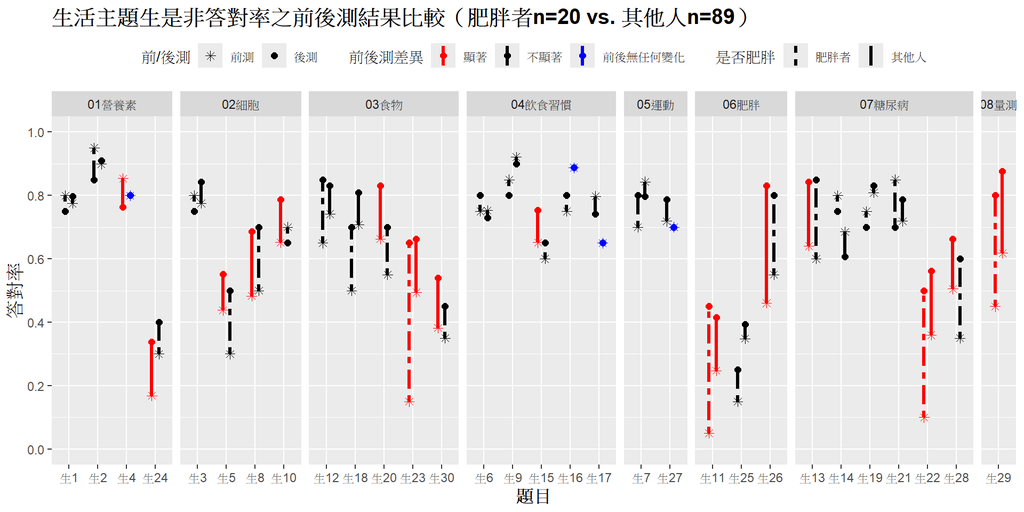

```r
yn.prepost.compare.plot(res21, "生活主題生是非答對率之前後測結果比較（肥胖者n=20 vs. 其他人n=89）", state=2)+
  facet_grid(cols=vars(生活主題), scales = "free", space = "free")
```

## **7-4 覺察類生是非前後測答對率（肥胖者n=20 vs. 其他人n=89）**

```r
kk<-yn_life.prepost.compare.table(Cdat1_yn%>%filter(Cfat&(Cfat.bf|Cnofat.bf)),
                                  Cdat2_yn%>%filter(Cfat&(Cfat.bf|Cnofat.bf)),
                                  Cdat1_yn%>%filter(Cnofat&(Cfat.bf|Cnofat.bf)),
                                  Cdat2_yn%>%filter(Cnofat&(Cfat.bf|Cnofat.bf)),2)%>%
  filter(覺察==1)%>%dplyr::select(!c("知識性質","生活主題","覺察"))

colnames(kk)<-c("","","平均答對率","標準差","平均答對率","標準差","t統計量","p-value","檢定結果")


kk[,7]<-kk[,7]%>%as.numeric%>%round(digits=3)

kk[,8]<-str_c(kk[,8]%>%as.numeric%>%round(digits=3),cut(kk[,8]%>%as.numeric, breaks=c(0,0.001,0.01,0.05,1),labels=c("***","**","*","")))

kk%>%kable("html",escape = F,booktabs = TRUE, digits=c(0,0,3,2,3,2,3,3,3), caption="7-4 覺察類生是非前後測答對率（肥胖者n=20 vs. 其他人n=89）")%>%
  kable_styling(c("striped", "bordered"))%>%
  add_header_above(c(" " = 2, "前測" = 2, "後測" = 2,"前後測成對t檢定" = 3))%>%
  column_spec(1, bold = T)%>%
  collapse_rows(columns = 1)%>%
  group_rows("覺察", 1, dim(kk)[1])
```

7-4 覺察類生是非前後測答對率（肥胖者n=20 vs. 其他人n=89）

|  |  | 前測 平均答對率 | 前測 標準差 | 後測 平均答對率 | 後測 標準差 | 前後測成對t檢定 t統計量 | 前後測成對t檢定 p-value | 前後測成對t檢定 檢定結果 |
| --- | --- | --- | --- | --- | --- | --- | --- | --- |
| **覺察** |  |  |  |  |  |  |  |  |
| 生是非2 | 肥胖者 | 0.950 | 0.22 | 0.850 | 0.37 | -1.000 | 0.33 | Don’t Reject H0 |
|  | 其他人 | 0.899 | 0.30 | 0.910 | 0.29 | 0.276 | 0.783 | Don’t Reject H0 |
| 生是非6 | 肥胖者 | 0.750 | 0.44 | 0.800 | 0.41 | 0.438 | 0.666 | Don’t Reject H0 |
|  | 其他人 | 0.753 | 0.43 | 0.730 | 0.45 | -0.406 | 0.685 | Don’t Reject H0 |
| 生是非9 | 肥胖者 | 0.850 | 0.37 | 0.800 | 0.41 | -0.438 | 0.666 | Don’t Reject H0 |
|  | 其他人 | 0.921 | 0.27 | 0.899 | 0.30 | -0.630 | 0.53 | Don’t Reject H0 |
| 生是非11 | 肥胖者 | 0.050 | 0.22 | 0.450 | 0.51 | 3.559 | 0.002** | Reject H0 |
|  | 其他人 | 0.247 | 0.43 | 0.416 | 0.50 | 2.540 | 0.013* | Reject H0 |
| 生是非12 | 肥胖者 | 0.650 | 0.49 | 0.850 | 0.37 | 1.710 | 0.104 | Don’t Reject H0 |
|  | 其他人 | 0.742 | 0.44 | 0.831 | 0.38 | 1.523 | 0.131 | Don’t Reject H0 |
| 生是非13 | 肥胖者 | 0.600 | 0.50 | 0.850 | 0.37 | 1.561 | 0.135 | Don’t Reject H0 |
|  | 其他人 | 0.640 | 0.48 | 0.843 | 0.37 | 3.486 | 0.001*** | Reject H0 |
| 生是非15 | 肥胖者 | 0.600 | 0.50 | 0.650 | 0.49 | 0.370 | 0.716 | Don’t Reject H0 |
|  | 其他人 | 0.652 | 0.48 | 0.753 | 0.43 | 1.997 | 0.049* | Reject H0 |
| 生是非16 | 肥胖者 | 0.750 | 0.44 | 0.800 | 0.41 | 0.370 | 0.716 | Don’t Reject H0 |
|  | 其他人 | 0.888 | 0.32 | 0.888 | 0.32 | 0.000 | 1 | No Change |
| 生是非17 | 肥胖者 | 0.650 | 0.49 | 0.650 | 0.49 | 0.000 | 1 | No Change |
|  | 其他人 | 0.798 | 0.40 | 0.742 | 0.44 | -0.962 | 0.339 | Don’t Reject H0 |
| 生是非18 | 肥胖者 | 0.500 | 0.51 | 0.700 | 0.47 | 1.285 | 0.214 | Don’t Reject H0 |
|  | 其他人 | 0.708 | 0.46 | 0.809 | 0.40 | 1.904 | 0.06 | Don’t Reject H0 |
| 生是非19 | 肥胖者 | 0.750 | 0.44 | 0.700 | 0.47 | -0.438 | 0.666 | Don’t Reject H0 |
|  | 其他人 | 0.809 | 0.40 | 0.831 | 0.38 | 0.424 | 0.672 | Don’t Reject H0 |
| 生是非20 | 肥胖者 | 0.550 | 0.51 | 0.700 | 0.47 | 1.143 | 0.267 | Don’t Reject H0 |
|  | 其他人 | 0.663 | 0.48 | 0.831 | 0.38 | 2.795 | 0.006** | Reject H0 |
| 生是非23 | 肥胖者 | 0.150 | 0.37 | 0.650 | 0.49 | 3.684 | 0.002** | Reject H0 |
|  | 其他人 | 0.494 | 0.50 | 0.663 | 0.48 | 2.899 | 0.005** | Reject H0 |
| 生是非26 | 肥胖者 | 0.550 | 0.51 | 0.800 | 0.41 | 1.751 | 0.096 | Don’t Reject H0 |
|  | 其他人 | 0.461 | 0.50 | 0.831 | 0.38 | 5.916 | 0*** | Reject H0 |
| 生是非27 | 肥胖者 | 0.700 | 0.47 | 0.700 | 0.47 | 0.000 | 1 | No Change |
|  | 其他人 | 0.719 | 0.45 | 0.787 | 0.41 | 1.228 | 0.223 | Don’t Reject H0 |

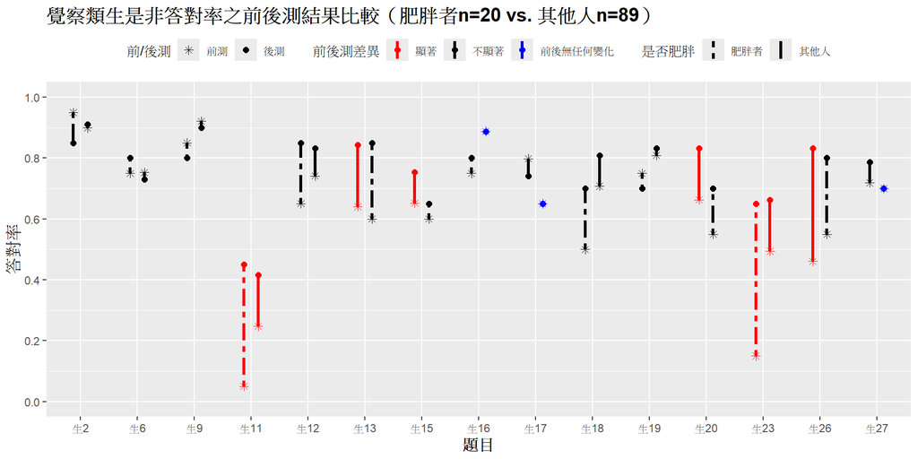

```r
yn.prepost.compare.plot(res21[res21$覺察==1,], "覺察類生是非答對率之前後測結果比較（肥胖者n=20 vs. 其他人n=89）", state=2)
```